# SEI/CADE - 0920642 - Voto Processo Administrativo

**Ministério da Justiça e Segurança Pública - MJSP**

**Conselho Administrativo de Defesa Econômica - CADE**

SEPN 515, Conjunto D, Lote 4, Edifício Carlos Taurisano, - Bairro Asa Norte, Brasília/DF, CEP 70770-504  
Telefone: (61) 3221-8485 - www.cade.gov.br

**Processo Administrativo nº 08700.008612/2012-15 (Apartado Restrito nº 08700.011156/2014-44)**

**Representante**: CADE *ex officio*

**Representados:** Attendy Artigos de Vestuário e Confecções Ltda., Brink Mobil Equipamentos Educacionais Ltda., Capricórnio S.A, Diana Paolucci S.A. Indústria e Comércio, Excel 3000 Materiais e Serviços Ltda., Libero Comercial Ltda., Mercosul Comercial e Industrial Ltda., NCR Uniformes Ltda., Nilcatex Têxtil Ltda., Tecelagem Guelfi Ltda., Abelardo Paolucci, Alexandre Costa dos Santos, Antonio Carlos Leskovar Borelli, Cláudio Roberto da Silva, Djalma da Silva Santos, Eldo Umbelino, Emerson da Silva, Erica Nunes dos Santos Lima, Ricardo Gonçalves Guerra, Jannivaldo Marques Santos, Júlio Manfredini, Kalvin Villela Brandão Paolucci, Márcio Nogueira Vignoli, Marcos Antônio Miranda da Silva, Maurício Paolucci, Mickael Villela Brandão Paolucci, Reinaldo Paolucci, Renato Borges Duarte, Roberto Giro Nakano, Silvio Carlos dos Santos e Valdemar Ábila.

**Advogados**: Tatiana Stolf Filippetti Dias, Eliza Tiyoko Cavalcante Trauczynski, Marco Fábio Domingues, Antonio Araldo Ferraz Dal Pozzo, Augusto Neves Dal Pozzo, Sérgio Salgado Ivahy Badaró, Gustavo Henrique Righi Ivahy Badaró, Luiz Fernando Pinto da Silva, Renata Pires de Serpa Pinto, Maurício Loddi Gonçalves, Rogério Ramires, Haroldo Pabst, Maro Marcos Hadlich Filho, Haroldo de Almeida, Ariosto Mila Peixoto, Camille Vaz Hurtado Pavani, Fernanda Mara Pereira de Toledo, Felipe Mateus de Toledo, Priscila Brolio Gonçalves, Andrea Fabrino Hoffman Formiga, Danilo Botelho dos Santos, Linneu Rodrigues de Carvalho Sobrinho, Ivone Maria Rocha Garcia e outros.

**Relatora**: **Conselheira Paula Farani de Azevedo Silveira**

**VOTO DA RELATORA**

**VERSÃO PÚBLICA**

Ementa: PROCESSO ADMINISTRATIVO. CARTEL EM LICITAÇÕES PÚBLICAS DESTINADAS À AQUISIÇÃO DE UNIFORMES, MOCHILAS E MATERIAIS ESCOLARES PARA ALUNOS DA REDE PÚBLICA DE ENSINO. PARECER DA SUPERINTENDÊNCIA-GERAL PELA CONDENAÇÃO PARCIAL. PARECER DA PROCURADORIA FEDERAL ESPECIALIZADA PELA CONDENAÇÃO PARCIAL. PARECERDO MINISTÉRIO PÚBLICO FEDERAL PELA CONDENAÇÃO PARCIAL. CONDENAÇÃO PARCIAL. MULTA.

Ao estipular as sanções pecuniárias para empresas, especialmente em casos de cartéis em licitações, a autoridade deverá empreender esforços para estimar a vantagem auferida com a conduta ilícita, de modo a observar o comando legal que impõe que a multa não poderá ser menor que tal vantagem.

**voto**

I. EMENDA AO RELATÓRIO

Em 29 de fevereiro de 2021, foi disponibilizado o Relatório (SEI 0860387), contendo uma descrição do objeto do presente Processo Administrativo, além de seus principais andamentos.

Nesta ocasião, procedo à emenda do Relatório citado, a fim de fazer constar a juntada da resposta da ao Ofício nº 7865/2020/GAB4/CADE expedido à Secretaria da Receita Federal do Brasil<sup><sup>[1]</sup></sup>, requerendo informações sobre a Receita Bruta, registrada no ano-calendário 2013, dos Representados Attendy, Libero, Mercosul e NRC Uniformes, bem como a ocorrência de reuniões adicionais no Tribunal do CADE<sup><sup>[2]</sup></sup>.

Ainda, considerando a extensão desta investigação, refletida no número elevado de pessoas físicas e jurídicas no polo passivo, faço uma recapitulação das datas e prazos que pautaram o trâmite desse Processo até aqui.

O feito se iniciou, formalmente, em 10 de outubro de 2012, por meio da instauração de Inquérito Administrativo pela Superintendência-Geral (SG) do CADE. Dois anos após, em 26 de dezembro de 2014, o Inquérito foi transformado em Processo Administrativo. O período de tramitação na SG foi finalizado em 20 de dezembro de 2018, totalizando mais de 6 anos de instrução.

Em 21 de dezembro de 2018, o Processo foi distribuído ao gabinete. No dia 16 de janeiro de 2019, juntou-se aos autos uma petição com pedido de medida preventiva, protocolada pela empresa All Stock Comércio de Produtos Nacionais e Industrialização por Conta de Terceiros Ltda. – EPP. Esse incidente foi decidido pelo Gabinete em 2 dias, ou seja, no dia 18 de janeiro de 2019.

Após análise preliminar dos autos pelo Gabinete para verificar a necessidade de instrução complementar e eventual saneamento do feito – por se tratar de processo com polo passivo bastante numeroso –, o feito foi enviado à Procuradoria Federal Especializada junto ao CADE (“ProCADE”) e ao Ministério Público federal junto ao CADE (MPF) no dia 2 de maio de 2019.

A ProCADE fez juntar parecer aos autos no dia 10 de julho de 2019 (69 dias).

Em razão da ausência de quórum, o trâmite do Processo foi suspenso do dia 17 de julho de a 7 de outubro de 2019.

O MPF juntou seu parecer no dia 13 de maio de 2020, perfazendo um total de 377 dias para emissão dos pareceres e conclusão do feito a julgamento.

Dessa data ao julgamento hoje realizado, em 31 de março de 2021, decorreu-se prazo de 322 dias.

Feito tal retrospecto, passo, enfim, ao julgamento do Processo.

II. PRELIMINARES

Conforme exposto nas Notas Técnicas nº 8/2016/CGAA8/SGA2/SG/CADE (SEI 0159523) e 96/2018/CGAA8/SGA2/SG/CADE (SEI 0561745), emitidas pela Superintendência-Geral do CADE (“SG/CADE”), e acolhidas pelos Despachos do Superintendente-Geral nº 181/2016 e 21/2018 (SEI 0163178 e 0561726, respectivamente), as seguintes questões preliminares foram suscitadas pelos Representados: (i) nulidade do acordo de leniência; (ii) fraude em documentos juntados pelo beneficiário; (iii) nulidade da busca e apreensão; (iv) violação do princípio do juiz natural e da vedação ao *bis in idem*; (v) nulidade do compartilhamento de provas (prova emprestada); (vi) inobservância do prazo máximo para tramitação do inquérito administrativo; (vii) insuficiência de provas e indícios frágeis/inadmissibilidade de prova diabólica no PA; (viii) acusações genéricas; (ix) ausência de individualização; (x) ilegitimidade passiva e boa-fé dos representados; (xi) impossibilidade de cartel na modalidade pregão eletrônico; (xii) ausência de enquadramento das condutas na tipificação das infrações à ordem econômica; (xiii) nulidade das oitivas realizadas; e (xiv) ausência de análise de documentos de números SEI 0539186 e 0539198.

Da análise das referidas Notas Técnicas (SEI 0159523 e 0561745), observo que todas as preliminares apontadas acima foram devidamente examinadas pela SG/CADE, que acabou por indeferi-las por falta de amparo fático e/ou legal. Ademais, constato ainda que tais preliminares também foram objeto de análise tanto ProCADE<sup><sup>[3]</sup></sup> quanto do MPF<sup><sup>[4]</sup></sup>, que, da mesma forma, opinaram pela regularidade do feito e afastaram tais preliminares.

Considerando as análises empregadas pela SG/CADE, ProCADE e MPF, acato na íntegra as suas respectivas Notas Técnicas e Pareceres, por concordar com tais análises e respectivas conclusões. Por conta disso, com base no princípio da econômica processual e no art. 50, § 1º da Lei nº 9.784/99, entendo não ser necessário reproduzir novamente o quanto exposto nas referidas ocasiões, motivo pelo qual concluo pela regularidade do feito e indefiro todas as preliminares suscitadas pelos Representados.

III. MÉRITo

III.1. Contexto das condutas

Trata-se de Processo Administrativo instaurado para apurar suposto cartel em licitações públicas destinadas à aquisição de uniformes, mochilas e materiais escolares em diversos Estados do país<sup><sup>[5]</sup></sup>, entre os anos de 2007 e 2012. A conduta em análise é passível de enquadramento nos arts. 20, I, II e IV, e 21, I, III e VIII, da Lei nº 8.884/94, correspondentes ao art. 36, caput, incisos I, II e IV e § 3º, inciso I, “a”, “c” e “d”, da Lei nº 12.529/2011.

Conforme exposto no Relatório (SEI 0860387), o presente Processo Administrativo foi instaurado em 26 de dezembro de 2014, por meio da Nota Técnica nº 436/2014 (SEI 000422, fls. 4114/4160), acolhida pelo Despacho SG 1676/2014 (SEI 0004222, fls. 4161), a partir do acordo de leniência firmado entre o Conselho Administrativo de Defesa Econômica (“CADE”) e o Sr. Djalma da Silva Santos, com a participação do Ministério Público Federal em São Paulo (“MPF/SP”) e do Ministério Público Estadual de São Paulo (“MPE/SP”) (SEI 0004115, fls. 1/10)<sup><sup>[6]</sup></sup>.

A partir das informações obtidas por meio do referido acordo e do Histórico da Conduta (SEI 0004115, fls. 1/18), foram realizadas diligências de busca e apreensão pelo MPE/SP, com o auxílio técnico do CADE, nas sedes das empresas Capricórnio S.A., Diana Paolucci S.A. Indústria e Comércio, Mercosul Comercial Industrial Ltda., Excel 3000 Materiais e Serviços Ltda. e nas residências de Abelardo Paolucci e Júlio Manfredini, dirigentes das empresas Diana Paolucci S.A. Indústria e Comércio e Capricórnio S.A., respectivamente. Assim, em 14 de setembro de 2012 o Grupo Especial de Delitos Econômicos (“GEDEC-MPSP”) lavrou o relatório de tais diligências, acompanhados dos respectivos Autos de Busca e Apreensão (SEI 0004118, fls. 522-548).

Em virtude disso, o CADE obteve conhecimento a fatos relacionados à prática de cartel, em conjunto com ilícitos diversos, tais como fraudes a licitações, dentre outros, onde os envolvidos possuíam acesso antecipado a editais e direcionavam certames por meio de pagamento de comissões a autoridades públicas.

Não menos importante, paralelamente às fraudes e ao cartel, o conjunto probatório contido nos autos também demonstrou a profundidade das relações espúrias que permeavam o mercado afetado pela conduta. Nesse sentido, verificou-se que, durante anos, os Representados não se comportavam como competidores de fato, mas sim como verdadeiros “parceiros de negócios”, que dividiam salas de escritório<sup><sup>[7]</sup></sup>, compartilhavam editais de licitações ainda não publicados, elaboravam cotações de preços fictícias, além de fornecerem produtos uns aos outros, de modo a frustrar o caráter competitivo das licitações e acabar por dividir o mercado entre eles<sup><sup>[8]</sup></sup>.

Como consequência, observa-se, no presente caso, a existência de acordos colusivos cometidos por meio da fixação de preços e divisão de mercados destinados a licitações públicas, além da troca de informações concorrencialmente sensíveis, que acabaram por gerar vultosos prejuízos ao erário público. Tais condutas serão melhor explicitadas a seguir.

III.2. Caracterização e dinâmica do cartel

Considerando o contexto narrado acima, passo à definição do *modus operandi* do cartel.

Em primeiro lugar, entendo necessário rememorar as principais estratégias adotadas em cartéis em licitação, conduta sobre a qual já tive oportunidade de me manifestar em processos anteriores<sup><sup>[9]</sup></sup>. De acordo com as “*Diretrizes para combater o conluio entre concorrentes em contratações públicas*”<sup><sup>[10]</sup></sup> elaboradas pela Organização para a Cooperação e Desenvolvimento Econômico (“OCDE”), dentre as principais estratégias adotadas em cartéis em licitação, está a divisão de mercados, implementada por meio de apresentação de propostas de cobertura, supressão de propostas e/ou apresentação de propostas rotativas.

Nesse sentido, ao analisar as provas carreadas nos autos, observo que, no presente processo, o cartel foi implementado, sobretudo, por meio da divisão de mercado e fixação de preços. Dessa forma, em momentos anteriores à ocorrência das licitações, as Representadas acordavam por meio de contatos informais, e-mails e telefonemas<sup><sup>[11]</sup></sup> qual delas seria a vencedora de cada certame, valendo-se, inclusive, de planilhas para fiscalizar a divisão do mercado<sup><sup>[12]</sup></sup>. Além disso, há provas de que os participantes também trocavam mensagens de celular<sup><sup>[13]</sup></sup> e e-mails<sup><sup>[14]</sup></sup> para combinar os detalhes do conluio e fiscalizar o cumprimento do acordo<sup><sup>[15]</sup></sup> durante a realização do processo licitatório.

Para que o esquema fosse “bem-sucedido”, observo que outros participantes se abstinham de participar ou apresentavam propostas de cobertura com o intuito de simular o caráter competitivo das licitações. Em complemento, os participantes também adotavam estratégias de subcontratação como característica da racionalidade ao cartel. Com relação a tal ponto, o Guia de Combate a Cartéis em Licitação<sup><sup>[16]</sup></sup> aponta que:

*b) Subcontratação*

*Tal como apontado acima, a subcontratação, também passível de ser autorizada em licitações públicas, é um instituto por meio do qual o contratado transfere parte de uma obra ou serviço para ser executada por terceiro. **Em certas situações, os concorrentes podem se valer desse instituto para implementar seus acordos anticompetitivos, como no caso de empresas que suprimiram propostas ou apresentaram propostas de cobertura serem recompensadas com contratos** **de subcontratação**. Dessa forma, a subcontratação das empresas colaboradoras permite que os lucros excepcionalmente elevados – fruto da ausência de competitividade derivada do acordo colusivo firmado entre as concorrentes – sejam divididos entre os participantes do cartel. Novamente, não se está aqui a afirmar que a subcontratação é, sempre e necessariamente, o resultado de um acordo entre concorrentes. Os potenciais riscos de tal instituto, no que se refere às possíveis estratégias colusivas disponíveis às empresas licitantes, devem, contudo, ser analisados no âmbito de investigações acerca do comportamento colusivo de empresas em licitações públicas*. (Grifo nosso)

Nessa linha, muito embora a subcontratação por si só não seja ilícita<sup><sup>[17]</sup></sup>, os participantes do conluio celebravam acordos no sentido de que um deles seria o vencedor da licitação e, em contrapartida, os outros concorrentes seriam subcontratados para fornecer os produtos objeto da licitação. Dessa forma, enquanto a Administração Pública adquiria produtos por preços artificialmente competitivos, gerando, por consequência, graves prejuízos ao erário, os participantes do cartel obtinham vantagens artificiais ao fornecer tais produtos com uma margem superior àquela que obteriam em condições normais de mercado.

III.3. Conjunto probatório

Considerando o vasto material probatório coletado ao longo do processo, foram juntados aos autos diversos documentos que indicam a existência de extenso conjunto probatório relacionado às condutas anticompetitivas ora investigadas<sup><sup>[18]</sup></sup>.

Tais documentos foram coletados por meio do acordo de leniência e busca e apreensão ocorridos no presente processo, conforme já exposto acima, além do compartilhamento de provas com o MPE/SP e o Tribunal de Contas do Estado de São Paulo (“TCE/SP”). Além disso, a SG/CADE também realizou instrução complementar, ocasião em que expediu ofícios a diversos órgãos e instituições, conforme já citado no Relatório, nos quais solicitou informações, dentre outras, sobre determinados processos licitatórios que serviram tanto para corroborar quanto para complementar indícios já existentes nos autos.

Feitas essas breves considerações, passo, portanto, de maneira não exaustiva, ao conjunto probatório relativo às práticas anticompetitivas investigadas no presente processo.

**III.3.1. Da existência de elementos probatórios suficientes que corroboram os indícios inicialmente trazidos pelo Signatário**

De acordo com os relatos prestados pelo Signatário tanto no presente processo quanto no Processo Criminal n° 0084710-80.2012.8.26.005, as condutas anticompetitivas ocorreram no âmbito dos pregões realizados pela Fundação pelo Desenvolvimento da Educação (“FDE”) do Estado de São Paulo, e em licitações realizadas pelos municípios de São Caetano e Guarulhos, todas no Estado de São Paulo. Não obstante, a partir da busca e apreensão e instrução complementar conduzidas pela SG/CADE, foi possível verificar que as condutas anticompetitivas não se restringiram ao Estado de São Paulo. De fato, conforme citado anteriormente no presente voto, diversas licitações para a aquisição de uniformes, mochilas e materiais escolares de todo o país foram atingidas pelo cartel.

Nesse sentido, descrevo, inicialmente, abaixo as condutas anticompetitivas narradas pelo Signatário, as quais, após ter analisado os documentos e informações adicionais colhidos ao longo do processo, compreendo estarem devidamente caracterizadas no presente processo.

No que diz respeito aos Pregões Eletrônicos 36/00496/11/05 e 36/00499/11/05 promovidos pela FDE, muito embora a análise será realizada de forma separada, para fins de organização, considerando-se que o conluio envolveu ambos os certames; que referidos certames foram realizados na mesma data e com objetos similares; e que as provas trazidas pelo Signatário contemplam, por vezes, tais certames conjuntamente, tal análise estará, portanto, relacionada e, por vezes, abrangerá ambos certames ao mesmo tempo.

Passo, portanto, à análise dos pregões eletrônicos mencionados acima.

**III.3.1. (a) Pregão Eletrônico 36/00499/11/05 (FDE) realizado em 16 de setembro de 2011<sup><sup>[19]</sup></sup>**

O Signatário do Acordo de Leniência trouxe informações de que houve conluio nos Pregões Eletrônicos nº 36/00496/11/05 e 36/00499/11/05, ambos promovidos em 16 setembro de 2011, pela FDE, referentes à aquisição de mochilas e material escolar no município de São Paulo (SEI 0004115, p. 12 e seguintes). De acordo com o Signatário, teria havido ajusto prévio entre as Representadas, inclusive durante o processo de formatação e negociação dos certames junto à FDE<sup><sup>[20]</sup></sup>.

Especificamente, no que diz respeito ao Pregão Eletrônico nº 36/00499/11/05, o certame foi dividido em três lotes e, de acordo com as informações prestadas pelo Signatário tanto no âmbito do Acordo de Leniência quanto para o GEDEC (MPE/SP), as Representadas Capricórnio, Mercosul e Diana Paolucci acordaram que a Capricórnio seria a vencedora dos dois primeiros lotes<sup><sup>[21]</sup></sup>, de forma a dividir o objeto dos contratos entre as três empresas, na proporção de um terço para cada uma. Para tanto, a Mercosul não participaria do certame e a Diana Paolucci apresentaria lances de cobertura.

Já com relação ao terceiro lote<sup><sup>[22]</sup></sup>, que teve como objeto a aquisição de mochilas infantis (i.e., mochila escolar – ensino fundamental I), de acordo com o Signatário, Júlio Manfredini (também conhecido como “Grandão”, Diretor Presidente da Capricórnio), negociaria com Valdemar Ábila (Sócio Administrador da Brink Mobil) para deixar a Capricórnio ganhar o lote e dividi-lo entre os envolvidos por um preço artificialmente mais alto, por conta do cartel.

Nesse sentido, o Signatário trouxe como prova o seguinte diálogo que manteve com Mickael Paolucci (funcionário de “operações especiais” da Diana Paolucci<sup><sup>[23]</sup></sup>), acerca das negociações entre Júlio e Valdemar (SEI 0004115):

**Diálogo entre o Signatário e o Representado Mickael Paolucci**

**[ACESSO RESTRITO AOS REPRESENTADOS]**<sup><sup>24]</sup></sup>

No diálogo, é possível observar a apreensão do Signatário com relação ao cumprimento do acordo, em especial no trecho em que o Signatário alerta para que Mickael Paolucci converse com Abelardo Paolucci (Presidente da Diana Paolucci), uma vez que Julio Manfredini estaria muito seguro do sucesso da sua negociação com o Waldemar e, portanto, da divisão de mercado quanto a esse lote.

Ao analisar o certame, verifico que, conforme relatado pelo Signatário, a Capricórnio foi a vencedora dos dois primeiros lotes, enquanto a Brink Mobil foi a vencedora do terceiro lote. Além do quanto exposto pelo Signatário, entendo ainda haver indícios de que a Brink Mobil participou do conluio nos dois primeiros lotes, já que, conforme será destacado adiante, apresentou propostas idênticas ou muito próximas às da Diana Paolucci.

No que diz respeito ao primeiro lote, tanto a Capricórnio quanto a Diana Paolucci e a Brink Mobil participaram e efetuaram lances. Ao analisar a dinâmica competitiva do referido lote, observo que a Capricórnio e a Diana Paolucci apresentaram lances semelhantes, havendo indícios – que serão descritos abaixo – de que tais lances poderiam ser de cobertura. Já no que diz respeito às propostas finais, constato que a proposta final da Capricórnio (9,5000) foi praticamente idêntica às propostas da Diana Paolucci e da Brink Mobil (ambas de 9,5001), contendo uma redução mínima de 0,0001 centavo. Dessa forma, considerando o contexto trazido pelo Signatário e as propostas semelhantes apresentadas, entendo que a diferença entre elas caracteriza um forte indício de cobertura entre tais Representadas.

Observo ainda, que a empresa Dismaf, que havia inicialmente se sagrado a vencedora do primeiro lote, e que, até onde se tem conhecimento, não estava envolvida no conluio, foi desclassificada por não comprovar a capacidade de fornecimento mínimo, restando para a Capricórnio a primeira colocação. Para facilitar a visualização da dinâmica competitiva do lote em discussão, reproduzo abaixo a parte final dos lances propostos, seguidos da análise da aceitabilidade do preço pela FDE<sup><sup>[25]</sup></sup>:

**Imagem – Lote 1 – Parte Final dos Lances Ofertados**

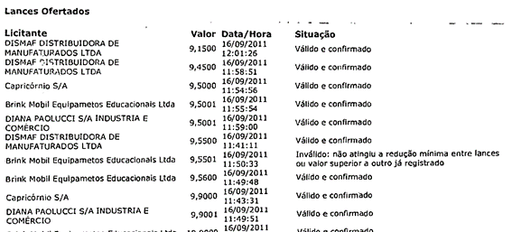

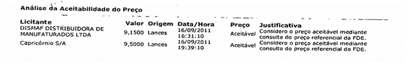

No que diz respeito ao segundo lote, novamente, tanto a Capricórnio quanto a Diana Paolucci e a Brink Mobil participaram e efetuaram propostas, tendo a Capricórnio, mais uma vez, na linha do quanto exposto pelo Signatário, se sagrado a vencedora. Como se observa do trecho da Ata da Sessão Pública demonstrada abaixo<sup><sup>[26]</sup></sup>, verifica-se que as propostas iniciais e lances ofertados foram idênticos e uniformizados, além da diferença de apenas 0,0001 centavo entre os lances finais efetuados pela Capricórnio e Brink Mobil. Similarmente ao quanto concluído acima, considerando o valor das propostas apresentadas e o contexto apresentado pelo Signatário, entendo haver indícios claros de que ao menos os lances da Brink Mobil e da Diana Paolucci foram de cobertura, já que foram iguais ou muito próximos um dos outros:

**Imagem – Lote 2 – Propostas de Classificação e Parte Final dos Lances Ofertados**

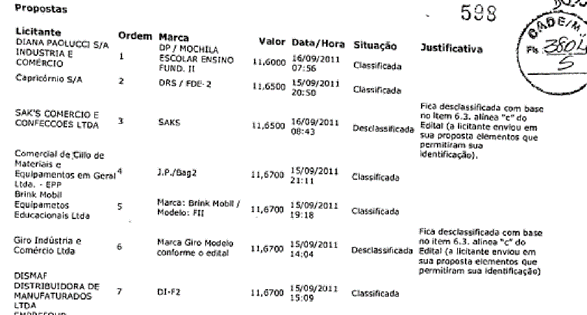

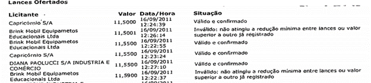

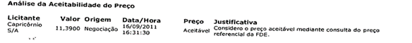

Por fim, já quanto ao terceiro lote, as Representadas Capricórnio, Nilcatex, Diana Paolucci e Brink Mobil participaram de tal lote, tendo a Brink Mobil se sagrado a vencedora. Conforme exposto pelo Signatário, Valdemar Ábila, que tinha, a princípio, concordado com o cartel, descumpriu o que tinha acordado com Julio Manfredini, ganhando o lote para aquisição de mochilas escolares. Com isso, houve concorrência efetiva em tal lote, uma vez que a Diana Paolucci, inconformada com a desistência do participante do cartel, parou de apresentar lances de cobertura e competir com a Brink Mobil.

Nesse sentido, as conversas trazidas pelo Signatário, ocorridas entre ele e Mickael Paolucci, corroboram a frustração dos cartelistas quando Valdemar “*dá para trás*”, ou seja, descumpre com o acordo anticompetitivo:

**Diálogo entre o Signatário e o Representado Mickael Paolucci**

**[ACESSO RESTRITO AOS REPRESENTADOS]**<sup><sup>[27]</sup></sup>

O trecho em que faz menção à fixação de preços – “*Vai todo mundo ficar na estimativa R$ 10,80*” – é corroborado pela dinâmica do próprio certame, em que as propostas iniciais apresentadas são todas similares, exatamente de R$ 10,80, e, no caso da Diana Paolucci e da Capricórnio, próximas a tal valor. Além disso, a realização do certame ilustra um cenário de concorrência efetiva, no qual houve uma diminuição significativa nos preços apresentados pelos licitantes, de R$ 10,80 para R$ 6,50, após o descumprimento do conluio por parte da Brink Mobil:

**Imagem – Lote 3<sup>**<sup>[28]</sup>**</sup> - Propostas de Classificação e Parte Final dos Lances Ofertados**

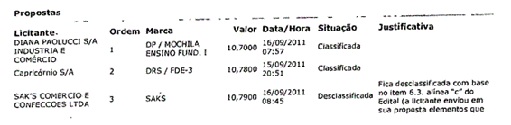

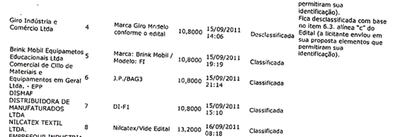

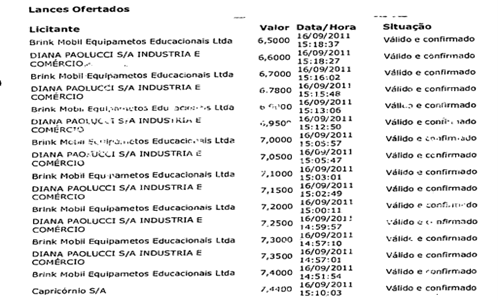

Diante de tais indícios, entendo não haver dúvidas acerca da caracterização do cartel praticado pelas Representadas Capricórnio, Diana Paolucci e Brink Mobil no Pregão Eletrônico 36/00499/11/05 e, conforme será complementado mais adiante, também do envolvimento da Mercosul no conluio. Além disso, observo ainda haver indícios de que outras empresas (não Representadas no presente processo) podem ter participado do cartel, tal como é o caso das empresas Dismaf Distribuidoras de Manufaturados Ltda., Comercial de Cillo de Materiais e Equipamentos em Geral Ltda. – EPP, Giro Indústria e Comércio Ltda., fato que, a princípio, fundamentaria a instauração de investigação contra elas.

Ademais, destaco ainda que o Signatário também juntou declaração de seu advogado, registrada em cartório em 03 de agosto de 2011<sup><sup>[29]</sup></sup>, isto é, um dia antes da primeira data agendada para a realização da sessão do pregão (que foi postergado para 16 de setembro), na qual informou acerca da “*suspeita de que haverá formação de cartel empresas do ramo para que os licitantes Capricórnio S/A, Brink Mobil Equipamentos Educacionais e Diana Paolucci S/A Indústria e Comércio se sagrem vencedores dividindo de alguma forma os três lotes do certame*”. Considerando a data e o conteúdo de tal declaração, entendo que tal documento comprova a ciência prévia do Signatário acerca dos resultados do certame, reforçando, portanto, as demais provas sobre o ajuste prévio entre tais Representadas.

Por fim, exponho ainda indícios adicionais acerca da referida divisão de mercado ocorrida no presente certame, obtidos sobretudo em virtude da busca e apreensão realizada pelo MPE/SP, com o auxílio técnico do CADE.

Conforme evidenciam os documentos “Pedidos Terceirizados”, apreendidos na sede da Diana Paolucci, observo que, em 15 de fevereiro de 2012, a Capricórnio adquiriu junto à Diana Paolucci 601.133 mochilas de ensino médio e 650.486 mochilas de ensino fundamental II ao preço unitário de R$ 8,84, em uma transação comercial de mais de R$ 11 milhões (SEI 0418310 - PIC 10-12 – ANEXO V – fls. 38 e seguintes).

Conforme exposto pela SG/CADE<sup><sup>[30]</sup></sup>, *“[o] preço pago pela Capricórnio para a Diana Paolucci por ambas as mochilas foi de R$ 8,84, enquanto o preço pago pela FDE/SP para a Capricórnio foi de R$ 9,50 (ensino médio) e R$ 11,39 (ensino fundamental II). Na licitação, a Diana Paolucci ofertou lances de R$ 9,50001 e R$ 11,55, respectivamente. Caso tivesse ofertado lance de R$ 8,84, seria a vencedora dos dois lotes. Considerando apenas o valor de R$ 8,84 - que é preço artificialmente fixado e não deve ser considerado como preço competitivo - e os valores pagos pela FDE/SP, o sobrepreço causado apenas pelas mochilas subfornecidas pela Diana Paolucci ultrapassaria R$ 2 milhões. Esse valor é confirmado ainda na mensagem eletrônica interna da Capricórnio “Pgto. Mochilas Diana Paolucci.”* .

Rememoro que os valores ofertados pela Diana Paolucci no mencionado certame podem ser inclusive verificados nos parágrafos 72 e 75 do Histórico da Conduta, destacados acima no presente voto e que, de acordo com a página 38 do SEI 0418310 - PIC 10-12 – ANEXO V, tais mochilas eram destinadas à FDE. Portanto, não há dúvidas acerca da subcontratação da Diana Paolucci realizada pela Capricórnio como forma de compensar a divisão de mercado cometida por tais Representadas.

Além disso, de acordo com os relatórios de inteligência elaborados pelo GEDEC, é possível verificar ainda que a divisão de um terço entre as Representadas Capricórnio, Mercosul e Diana Paolucci, referente aos dois primeiros lotes do Pregão Eletrônico nº Pregão Eletrônico nº 36/00499/11/05, conforme narrado pelo Signatário, de fato ocorreu. No que diz respeito ao Relatório de Inteligência nº 03/03/2015 (SEI 0418302 - PIC 10-12 – ANEXO III), elaborado pelo GEDEC nos autos do PIC 10/12, e produzido a partir da análise de notas fiscais encaminhadas pelos governos dos Estados de São Paulo, Santa Catarina, Pernambuco e do Distrito Federal, a totalidade das notas fiscais que mencionavam a FDE/SP foram emitidas tanto pela Diana Paolucci quanto pela Mercosul em favor da Capricórnio como adquirente de mochilas escolares. Dentre tais notas, grande parte delas está datada do primeiro semestre de 2012, o que indica serem referentes ao Pregão Eletrônico nº 36/00499/11/05, realizado em 16 setembro de 2011, que teve a Capricórnio como vencedora de dois dos três lotes<sup><sup>[31]</sup></sup>.

Em complemento, em outro detalhado relatório elaborado pelo GEDEC (Relatório nº 02/03/2015) (SEI 0418302 - PIC 10-12 - ANEXO IV - 1º Volume, fls. 8 a 12 e docs. 4 a 11 (fls. 29 e seguintes)), nos autos do PIC 09/12, mensagens eletrônicas trocadas entre a Capricórnio e a Mercosul, referentes ao mencionado pregão eletrônico e datadas do início de 2012 (posteriores, assim, à licitação e anteriores à entrega das mercadorias), comprovam que as mochilas foram importadas pela Mercosul (que não participou da licitação) e repassadas à Capricórnio, que então as forneceu à FDE/SP. Tal relatório demonstra ainda ordens de fornecimento de mochilas emitidas pela FDE à Capricórnio, bem como contrato celebrado entre a Mercosul e a Capricórnio, datado de 04 de novembro de 2011, nos quais é possível constatar que as quantidades de mochilas fornecidas pela Mercosul à Capricórnio correspondem a 2/3 dos lotes 1 e 2 vencidos pela Capricórnio. Especificamente, o que se observa é que as ordens de fornecimento emitidas pela FDE referentes às mochilas de ensino médio e fundamental II totalizam o montante de 3.754.860 unidades<sup><sup>[32]</sup></sup>, enquanto o contrato dispõe sobre o fornecimento de 2.528.000 mochilas escolares<sup><sup>[33]</sup></sup>, totalizando, portanto, aproximadamente 2/3 das mochilas mencionadas acima.

No que diz respeito ao contrato, ressalto que, nos termos da cláusula 3.1., o fornecimento de 2.528.000 mochilas seu deu pelo preço de R$ 7,46 cada. No certame, do qual a Mercosul não participou, rememoro que a Capricórnio venceu o primeiro lote ofertando o preço de R$ 9,50 e o segundo lote pelo valor de R$ 11,39. Além da margem da Capricórnio, tal fato indica que, diferentemente do quanto exposto em sua defesa<sup><sup>[34]</sup></sup>, a Mercosul tinha condições de participar do certame e ser uma forte candidata a vencer a licitação, já que possuía materiais suficientes a serem fornecidos para a FDE. No entanto, conforme mencionado acima, ressalto que a Diana Paolucci participou com a Capricórnio nos dois lotes em que a Capricórnio se sagrou vencedora, enquanto a Mercosul não chegou a participar de tal certame. Dessa forma, tendo em vista tais considerações, entendo que a participação da Mercosul no conluio também está devidamente comprovada.

Ante o exposto, entendo pela configuração do cartel praticado pelas Representadas Capricórnio, Diana Paolucci, Brink Mobil e Mercosul no Pregão Eletrônico 36/00499/11/05.

**III.3.1. (b) Pregão Eletrônico 36/00496/11/05 (FDE) realizado em 16 de setembro de 2011**<sup>**<sup>[35]</sup>**</sup>

No mesmo dia, também foi realizado o Pregão Eletrônico 36/00496/11/05 promovido pela FDE. Da mesma forma, a licitação foi dividida em três lotes, cada um com objeto especificado no Edital da licitação (SEI 0004129, fls. 1745 e seguintes). Segundo depoimentos prestados pelo Signatário tanto no âmbito do Acordo de Leniência<sup><sup>[36]</sup></sup> quanto para o GEDEC (MPE/SP) (SEI 0004115, p. 50 e seguintes), a Diana Paolucci pretendia vencer ao menos um dos lotes da licitação devido ao acordo formalizado com Ortiz Júnior<sup><sup>[37]</sup></sup>. Se a empresa fosse a vencedora do certame, Júnior receberia comissão sobre o preço pago pela FDE, uma vez que ele teria ajudado a direcionar a licitação por meio do edital:

**Termo de Declarações – Djalma da Silva Santos<sup>**<sup>[38]</sup>**</sup>**

**[ACESSO RESTRITO AOS REPRESENTADOS]**

De acordo com o Signatário, para que a Diana Paolucci pudesse vencer a licitação, era necessário convencer outras empresas para que a deixassem ganhar o certame. Assim, paralelamente às negociações da licitação anterior, de acordo com o Signatário, Abelardo Paolucci (Sócio e Presidente da Diana Paolucci) teria entrado em contato com Júlio Manfredini (Diretor Presidente da Capricórnio), com o intuito de que ele também intermediasse o acordo entre a empresa e outros concorrentes, dentre eles, a Excel e a Mercosul. Nesse sentido, com o apoio de Júlio Manfredini, a empresa conseguiu com que os outros concorrentes concordassem com o acordo, com a condição de que as empresas Capricórnio e Mercosul fossem subcontratadas para fornecer os produtos da licitação para a empresa Diana Paolucci.

Observa-se, no entanto, que as vencedoras dos lotes 1, 2 e 3 foram as empresas Bignardi Indústria e Comércio de Papéis e Artefato, Ataka Brasil Comércio e Serviços Ltda. e Kalunga Comércio e Indústria Gráfica Ltda. (não Representadas no presente processo), respectivamente. Isso ocorreu, no entanto, em razão da inabilitação da empresa Diana Paolucci, que apresentou documentos desatualizados acerca da administração da empresa<sup><sup>[39]</sup></sup>. Todavia, apesar de não ter sido a efetiva vencedora do certame, o depoimento do Signatário prestado perante o GEDEC em 08 de agosto de 2012, transcrito abaixo, explicita que isso se deu à parte do cartel, uma vez que todos cumpriram o acordado, tendo a empresa Diana Paolucci se sagrado vencedora antes da sua inabilitação:

**[ACESSO RESTRITO AOS REPRESENTADOS]***<sup>**<sup>[40]</sup>**</sup>*

Observo que tal depoimento é corroborado tanto pela ata da sessão pública, apresentada abaixo, que demonstra que a Diana Paolucci teria sido a vencedora dos lotes 1 e 3, caso não tivesse sido inabilitada<sup><sup>[41]</sup></sup>, como também pela troca de mensagens entre Mickael Paolucci e o Signatário por meio do *chat* do celular Blackberry (“BBM”), transcritas adiante. Tais mensagens evidenciam a frustração de Mickael e do Signatário quando Stanislau Paolucci (tio de Mickael e não Representado no presente processo) entregou a decisão judicial na FDE (mencionada pelo pregoeiro, conforme pode ser vista na ata transcrita abaixo), que inabilitou a Diana Paolucci da licitação<sup><sup>[42]</sup></sup>:

**Imagem – Lote 1<sup>**<sup>[43]</sup>**</sup>**

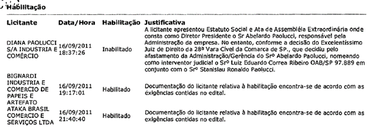

**Imagem – Lote 3<sup>**<sup>[44]</sup>**</sup>:**

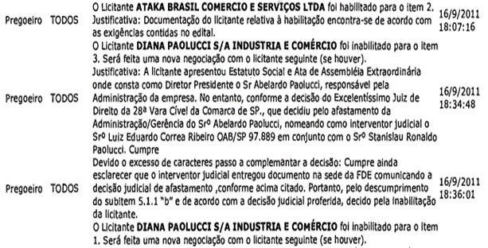

**Diálogo entre o Signatário e o Representado Mickael Paolucci**

**[ACESSO RESTRITO AOS REPRESENTADOS]**<sup><sup>[45]</sup></sup>

Além disso, com relação à Capricórnio, ao analisar a ata da sessão, observo que o referido depoimento do Signatário é corroborado ainda pelo fato de que, muito embora ela tenha sido classificada para participar dos lotes 1, 2 e 3, não apresentou sequer uma proposta, o que reforça ainda mais a divisão de mercado narrada pelo Signatário<sup><sup>[46]</sup></sup>.

Por conta do exposto, entendo que os indícios demonstrados acima são robustos e aptos a corroborar o relato trazido pelo Signatário acerca da divisão de mercado no Pregão Eletrônico 36/00496/11/05, praticada ao menos pelas Representadas Capricórnio e Diana Paolucci.

**III.3.1.(c) Licitação (Município de São Caetano) ocorrida em 2011**

De acordo com o Signatário, as licitações da FDE não foram as únicas afetadas pelas condutas anticompetitivas. Conforme relatado, em 2011, Abelardo Paolucci (Sócio e Presidente da Diana Paolucci) solicitou que o Signatário conduzisse negociações com Eldo Umbelino (também conhecido como “Castelo”, Diretor Vice-Presidente da Nilcatex), para que esta se abstivesse de participar da licitação a ser promovida pela Prefeitura do Município de São Caetano, referente à aquisição de uniformes escolares e tênis. Segundo o depoimento do Signatário, a licitação seria direcionada para a empresa Diana Paolucci. No entanto, para que o conluio pudesse ser concretizado, era necessário que a Nilcatex não participasse, ou seja, que uma empresa não competisse com a outra. Nesse sentido, para que a Nilcatex concordasse com o acordo, a Diana Paolucci deixaria de participar de licitações promovidas em outros municípios em favor da Nilcatex, demonstrando que o escopo do cartel era maior que o Estado de São Paulo<sup><sup>[47]</sup></sup>.

Para corroborar o quanto narrado, o Signatário forneceu uma cadeia de e-mails ao CADE, na qual consta e-mails trocados entre Eldo Umbelino e o Signatário, além de e-mails trocados anteriormente entre a Diana Paolucci e a Capricórnio<sup><sup>[48]</sup></sup>. O conteúdo de tais e-mails demonstra que, diante de uma discordância entre a Diana Paolucci e a Nilcatex acerca do que havia sido combinado, Eldo solicitou explicações a Djalma Santos, que, por sua vez, esclareceu o que havia sido acordado acerca da licitação no Município de São Caetano. Dessa forma, o e-mail do Signatário demonstra uma divisão de mercado no sentido de que a licitação de São Caetano seria alocada para a Diana Paolucci, se esta não participasse das licitações de Balneário Camboriú/SC e Joinville/SC.

Em complemento, ao observar a cadeia de e-mails, percebe-se no assunto e no corpo do e-mail que a Capricórnio também estava diretamente envolvida, uma vez que parte da referida desavença tratou da incorporação de IR/CSSL no cálculo da rentabilidade dos acertos de contas entre as três empresas:

**Imagem – Cadeia de E-mails – “Resposta Solicitada”**

**[ACESSO RESTRITO AOS REPRESENTADOS]**

A Nilcatex argumentou em sua defesa (SEI 0145832) que não teria participado da licitação mencionada **[ACESSO RESTRITO AOS REPRESENTADOS]**.

No entanto, embora tenha havido uma contradição entre os relatos do Signatário, entendo que a justificativa da Representada sobre a sua não participação no certame não esclarece **[ACESSO RESTRITO AOS REPRESENTADOS]**.

Isto é, se a justificativa sobre a não participação da Nilcatex fosse meramente de que não dispunha de amostras, certamente Eldo Umbelino não teria indagado o Signatário acerca do “acerto” no referido certame. Além disso, se a resposta do Signatário ao e-mail do Representado estivesse equivocada, o Representado provavelmente teria contestado tal explicação (seja por e-mail ou qualquer outro meio), já que era de seu interesse esclarecer os fatos e não ser prejudicado na ocasião.

No entanto, não foram identificados nos autos uma resposta ou até mesmo uma posterior contestação ao e-mail do Signatário, cabendo à defesa dos Representados tão somente argumentar que tal e-mail não possuiria qualquer credibilidade (SEI 0145832). Portanto, entendo que as justificativas trazidas pelos Representados sobre o “acerto” são incompletas e incapazes de justificar o e-mail de Eldo Umbelino, o qual foi posteriormente esclarecido pelo Signatário, conforme demonstrado acima.

A divisão de mercado também está corroborada por anotações na agenda de Reinaldo Paolucci (Representante Comercial da Capricórnio)<sup><sup>[49]</sup></sup>, obtida na busca e apreensão realizada na Capricórnio, que além de evidenciar a divisão de mercado narrada pelo Signatário, demonstra também a ciência da própria Capricórnio sobre o conluio acertado entre a Diana Paolucci e a Nilcatex. Na referida agenda, há menção sobre a divisão das licitações entre as empresas, em que há anotações sobre Diana ser a vencedora da licitação de São Caetano, bem como sobre a Nilcatex ficar com a licitação do município de Joinville, conforme ilustrada abaixo:

**Imagem – Anotações da Agenda de Reinaldo Paolucci**

**[ACESSO RESTRITO AOS REPRESENTADOS]**

Ressalto, no entanto, que ao analisar a resposta da Prefeitura de São Caetano ao Ofício nº 5008/2017/CADE (SEI 0386484), esta informou que, entre 2007 e 2012, o único contrato celebrado com a Representada Diana Paolucci em tal período originou-se do Pregão Presencial 01/2009, e não da licitação ocorrida em 2011, fato que, a princípio, contraria parcialmente o quanto narrado pelo Signatário, já que a Diana Paolucci não foi a vencedora de tal certame.

Entendo, no entanto, que a resposta da Prefeitura de São Caetano não retira a ilicitude da prática, uma vez que, para a caracterização do conluio, não é necessário que se tenha o resultado, mas sim a suficiência da materialidade da conduta (i.e., do acordo em questão) e da autoria. Dessa forma, ainda que a Diana Paolucci não tenha se sagrado a vencedora do certame, tal fato não retira a caracterização da divisão de mercado praticada pelos Representados, demonstrada acima.

Por fim, não menos importante, ao analisar a defesa de Reinaldo Paolucci, observo que ele justificou que as suas anotações (demonstradas acima) seriam observações de quem eram “*os concorrentes em licitações, quem vencia e quem não vencia, nada existindo de ilegal nesta observação*”<sup><sup>[50]</sup></sup>. Entendo, no entanto, que o seu argumento não pode prosperar, já que, fossem tais anotações meras observações, não haveria motivos para que o nome da Diana Paolucci estivesse alocado para o Município de São Caetano, já que não foi a vencedora de tal certame. Compreendo, dessa forma, que as suas anotações demonstram a ciência prévia acerca da divisão de mercado, corroborando, portanto, o quanto narrado pelo Signatário.

Ante o exposto, entendo que os indícios demonstrados acima reforçam o quanto narrado pelo Signatário de que as condutas anticompetitivas foram praticadas pela Diana Paolucci e Nilcatex, e, em menor grau, pela Capricórnio, referentes à divisão de mercado no município de São Caetano.

**III.3.1.(d) Pregão Presencial nº 011/2011-SE (Município de Guarulhos/SP) promovido em dezembro de 2011<sup><sup>[51]</sup></sup>**

O Signatário relatou, ainda, a existência de acordo anticompetitivo em licitações realizadas pela Prefeitura do Município de Guarulhos/SP, em especial o Pregão Presencial nº 011/2011-SE, cujo objeto foi a aquisição de materiais escolares. De acordo com o Signatário, em 2011, após já ter ocorrido direcionamentos de editais e conluio em anos anteriores, dos quais ele teria participado, a Representada Excel procurou o Signatário de forma que ele a auxiliasse na montagem do novo edital. O Signatário informou ter convicção de que houve combinação entre empresas, nos moldes do que já ocorrera em 2009.

Em complemento ao quanto narrado, foi juntado nos autos termo de declaração do Signatário colhido perante o GEDEC/MPE/SP (SEI 0129620 - Mídia, fls. 4098 - Volume 20 - 20141113115529227), no qual reforçou, em mais detalhes, o quanto narrado no Acordo de Leniência, tendo relatado ainda que as Representadas Excel, Diana Paolucci, Capricórnio e Mercosul fizeram parte do conluio (2009-2011). Em tal ocasião, o Signatário apresentou ainda documentos para corroborar o quanto narrado, tal como uma declaração de seu advogado registrada em cartório em 13 de outubro de 2011, isto é, anteriormente à licitação, com a indicação da Excel como vencedora da licitação, além da versão preliminar do edital, referente ao certame de 2012 (0004115).

Ao analisar as provas acostadas nos autos, observo que, em resposta ao Ofício nº 5009/2018/SG, a Prefeitura de Guarulhos, por meio do Ofício nº 153/2018-CEDEL Guarulhos (SEI 0476866 - p. 35 pdf.), encaminhou informações sobre as licitações promovidas de 2007 a 2012. Com relação ao Pregão Presencial nº 011/2011-SE, promovido em 2011, e que teve por objeto a aquisição de material escolar para o ano de 2012, as informações encaminhadas pela prefeitura demonstram indícios claros de que, em tal licitação, houve conluio entre as empresas, corroborando o quanto relatado pelo Signatário de que a Representada Excel seria a vencedora. Como estratégia de propostas de cobertura, tanto a Excel, Brink Mobil e Bigpar, quanto a Capricórnio e Castro e Castro, ofertaram preços idênticos, tendo a Diana Paolucci ofertado preço acima de todas, conforme pode ser visualizado abaixo. As propostas idênticas, como se observa, contemplam tanto os itens como preços finais, não havendo dúvidas quanto ao acordo entre tais empresas:

**Imagem – Resposta da Prefeitura de Guarulhos ao Ofício nº 5009/2018/SG (SEI 476866)**

**[ACESSO RESTRITO AOS REPRESENTADOS]**

Conforme se observa, ao final, a Excel se sagrou a vencedora de tal certame, confirmando, portanto, a narrativa do Signatário<sup><sup>[52]</sup></sup>.

Por fim, observo ainda que a divisão de mercado também é evidenciada por anotações na agenda de Reinaldo Paolucci<sup><sup>[53]</sup></sup>, obtida na busca e apreensão realizada na Capricórnio. Na referida agenda, há menção à divisão das licitações entre as empresas, em que há anotações sobre a Excel ser a vencedora da licitação do município em questão, conforme ilustrado abaixo:

**Imagem – Anotações - Agenda Reinaldo Paolucci**

**[ACESSO RESTRITO AOS REPRESENTADOS]**

Considerando o conjunto probatório demonstrado acima, que corrobora o quanto narrado pelo Signatário, entendo não haver dúvidas de que o conluio também ocorreu no município de Guarulhos, Estado de São Paulo, tendo participado as Representadas Excel, Brink Mobil, Capricórnio e Diana Paolucci, além de ter indícios da participação da Bigpar e Castro e Castro (não Representadas no presente processo).

**III.3.2. Da existência de elementos probatórios que demonstram práticas anticompetitivas adicionais em outros processos licitatórios**

Embora a narrativa do Signatário tenha se limitado às licitações discorridas acima, a partir do conjunto probatório acostado nos autos, verificou-se que a dimensão do cartel era mais extensa do que a inicialmente relatada. Nesse sentido, não apenas licitações para a aquisição de uniformes escolares foram afetadas pelo cartel, mas também licitações para a aquisição de uniformes do exército e da área da saúde, por exemplo.

Nesse sentido, trago, de forma não exaustiva, provas adicionais identificadas nos autos, dentre elas, planilhas, agendas e e-mails, que demonstram a amplitude do referido conluio, tanto no que diz respeito ao escopo do cartel, quanto aos seus participantes, uma vez haver indícios adicionais de que outras empresas também fizeram parte do conluio. Tais documentos evidenciam não apenas a fiscalização e conhecimento que parte dos Representados possuía sobre o mercado, mas sobretudo trocas de informações sensíveis e divisões de mercado em diversos municípios, incluindo aqueles narrados pelo Signatário, por apontar prefeituras/municípios designados para diferentes empresas ao redor do Brasil.

**III.3.2. (a) Evidências adicionais acerca da divisão de mercado**

Nesse sentido, a título exemplificativo, dentre os documentos apreendidos na sede da Excel, destaco a planilha “RELAÇÃO DAS LICITAÇÕES”<sup><sup>[54]</sup></sup>, demonstrada abaixo, que evidencia a nítida divisão prévia de mercado ao fazer referência ao município, objeto do certame e da pessoa/empresa alocada para ganhar a licitação. Dentre as licitações que constam na planilha, destaco o PP 37.2011, promovido pela Prefeitura de Ibiúna, referente à aquisição de uniformes escolares, no qual consta que a Excel não participaria pelo fato de tal certame já estar alocado para a Capricórnio: “*Não vamos, é da Capricórnio*”. Além do referido certame, é possível observar ainda a alocação de licitações para outras empresas, tais como “*Não vamos: É da Cely*”, “*Não vamos: é do Leandro*”, “*Não vamos: é do Thiago*”, “*Não vamos: é do Thiago com Tenis Nossos*”:

**Imagem – Planilha - “Relação das Licitações”**

**[ACESSO RESTRITO AOS REPRESENTADOS]**

No que diz respeito à aludida licitação promovida pela Prefeitura de Ibiúna, observo ainda que, em busca e apreensão realizada na sede da Capricórnio, foram apreendidas tabelas que contêm informações detalhadas e comparativas sobre os preços unitários e totais da Capricórnio, Mercosul e Tecelagem Guelfi, além de outras empresas não representadas, tal como a empresa Comercial de Cillo Uniformes Ltda., que, dado o detalhamento de informações e anotações, indicam que as empresas estavam, no mínimo, trocando informações sobre preços e custos.<sup><sup>[55]</sup></sup>. Quanto à Comercial de Cillo Uniformes Ltda., observo ainda que a empresa outorgou uma procuração para seu concorrente - Daniel Manfredini e Reinaldo Paolucci (Representante Comercial da Capricórnio) - , de forma que estes a representassem perante quaisquer “*repartições públicas*”, podendo, ainda “*formular ofertas, lances de preços, negociar preços diretamente com pregoeiro, praticar todos os atos pertinentes aos Certames (...)*”<sup><sup>[56]</sup></sup>. Constato, ainda, que a empresa Excel não se encontra nas tabelas abaixo, reforçando, a princípio, que não participaria do certame:

**Imagem – Tabelas - Comparação de Preços**

**[ACESSO RESTRITO AOS REPRESENTADOS]**

Embora não constem nos autos informações adicionais acerca do certame e da dinâmica competitiva ocorrida, consta no Diário Oficial do Estado de São Paulo, de 22 de maio de 2012, que a vencedora de tal licitação foi a empresa Comercial de Cillo Ltda.<sup><sup>[57]</sup></sup>. Embora tal fato contrarie, a princípio, a planilha apreendida na Excel, entendo que, pelo fato de a Capricórnio possuir procuração para representar tal empresa, incluindo poderes para formular e negociar preços, ao também participar da licitação, a própria Capricórnio teria incentivos de deixar de concorrer com a Comercial de Cillo e escolher o que seria melhor para as ambas as empresas conjuntamente, já que sabia de antemão os custos de ambas, conforme tabelas demonstradas acima. Ademais, não há qualquer justificativa legítima para a Capricórnio ter uma procuração para atuar em nome de sua concorrente na licitação.

Não obstante, ainda que a Capricórnio não tenha sido a empresa vencedora, entendo que tal fato não retira a ilicitude das condutas, já que há provas suficientes que comprovam que o processo competitivo em tal certame foi prejudicado, uma vez que, além da planilha indicar que a Excel não participaria de tal certame por conta de “ser” da Capricórnio, as tabelas apreendidas na sede da Capricórnio demonstram a ciência dos preços dos concorrentes e, no caso da Comercial de Cillo, inclusive de seus custos. Portanto, entendo que a prática anticompetitiva em tal licitação está devidamente comprovada nos autos.

Ademais, chamo atenção ainda para as planilhas apreendidas na residência de Abelardo Paolucci, especificamente no quarto de seu filho Kalvin Paolucci, que demonstram divisões adicionais de mercado entre os Representados, além de um conhecimento detalhado sobre o mercado, que não ocorreria em condições normais de concorrência. Especificamente, nas planilhas intituladas “Comissões Renato” e “Relatório de Contratos – Diana”, por exemplo, observa-se a expressa divisão de mercado referente à “*Pref. Guarulhos - Pr. 457/09 – Uniformes escolares – Lote 01 – 30.000 kits – divisão com Capricórnio – valor aproximado R$ 2,700.000,00*”, ou então “*Pref. SBC – Pr. 1017/09 – Uniformes escolares – Valor-R$ 25.910.000,00 – Cobrar 70% dividido entre Diana e Capricórnio*”, dentre outras menções, tais como “*Diana receberá 15% do negócio – Renato passará os dados dos parceiros – em andamento*”, “*Cobrar 1/3 do Mercosul*”, ou ainda, conhecimento de parceiros de outras empresas, conforme destacados em vermelho abaixo:

**Imagem – Planilhas Apreendidas na Residência de Abelardo Paolucci**

**[ACESSO RESTRITO AOS REPRESENTADOS]**

Tal como exposto pela SG/CADE<sup><sup>[58]</sup></sup>, da análise de tais tabelas, percebe-se ainda a intensidade e a frequência das relações comerciais entre Diana Paolucci, Mercosul e Capricórnio, além da demonstração do subfornecimento, em menor escala, da Brink Mobil e da Nilcatex, dentre outras empresas. Ademais, como destacado em vermelho acima, tais documentos também demonstram licitações sem indicação de vencedor ou parceiro, mas que já trazem definida a parte reservada à Diana Paolucci, como por exemplo “Recife 15%”, “Balneário Camboriú/SC 20%”, “João Pessoa ‘verificar’” e “São Bernardo do Campo/SP 20%”. Tratam-se, portanto, de provas adicionais que reforçam a divisão de mercado ocorrida pelas Representadas.

Nesse sentido, no que diz respeito à licitação “Pref. Guarulhos - Pr. 457/09 – Uniformes escolares – Lote 01 – 30.000 kits – divisão com Capricórnio – valor aproximado R$ 2,700.000,00”, mencionada acima, observo haver evidências adicionais acerca da divisão de mercado, bem como de propostas de cobertura. De acordo com a resposta da Prefeitura de Guarulhos ao Ofício nº 5009/2018/SG (SEI 0476866 - p. 20 e seguintes pdf.), já referida anteriormente, tanto a Diana Paolucci quanto a Capricórnio concorreram em tal lote, fato que demonstra que, embora ambas tinham capacidade técnica e de fornecimento para cumprirem individualmente com o contrato, caso se sagrassem vencedoras, acabaram por dividir o lote. Em tal certame, vencido pela Diana Paolucci, a Nilcatex e a Douat Cia. Têxtil apresentaram propostas idênticas nos quatro primeiros lotes, evidenciando, portanto, que também estiveram envolvidas no conluio.

Por fim, no que se refere ao Pregão Presencial 024/08-SE, também promovido pela Prefeitura de Guarulhos, ao analisar as tabelas demonstradas acima em conjunto com a resposta da Prefeitura de Guarulhos ao Ofício nº 5009/2018/SG (SEI 0476866 - p. 15 e seguintes pdf.), constato que, mesmo tendo a Nayr (não Representada no presente processo) sido a vencedora de tal certame, grande parte das empresas que concorreram com ela no certame acabaram sendo as suas “parceiras”, tais como a Diana Paolucci, Mercosul, Nilcatex, Dilmatex e Celi Confecções ME., fato que indica uma divisão de mercado entre tais empresas.

**III.3.2.(b) Evidências acerca da divisão de mercado entre a Mercosul e a Attendy**

Ressalto ainda para as consequências da proximidade comercial que existia entre a Mercosul e a Attendy, que acabou por ultrapassar os limites de uma relação legítima entre elas. Conforme explicitado pela SG/CADE (SEI 0561745 - parágrafos 273 e seguintes), as Representadas Attendy e Mercosul possuíam uma relação comercial próxima, tendo a Mercosul inclusive administrado informalmente a Attendy, devido às dificuldades financeiras que esta enfrentava à época<sup><sup>[59]</sup></sup>. Nesse contexto, observo a existência de divisão de mercado praticada entre a Mercosul, Attendy e a J.Educ. Fabril Ltda. (empresa não Representada), referente ao certame (não especificado) promovido pela Prefeitura de Itanhaém, Estado de São Paulo.

Conforme se verifica abaixo, no e-mail intitulado “ITANHAEM KITS”<sup><sup>[60]</sup></sup>, apreendido na sede da Excel, José Renato (J.Educ. Fabril Ltda.) se reuniu com Antonio Borelli (Diretor-Presidente da Mercosul) e Vanderlei Pinto dos Santos Júnior (Attendy), em 12 de maio de 2011, para acordar sobre a forma com que operacionalizariam a divisão do lote 4 e dos demais lotes do certame. Em tal ocasião, acordaram sobre a emissão de pedidos de compra, encaminhamento de propostas “equacionadas” para a Prefeitura nos demais lotes em nome da Mercosul, retirada dos empenhos junto à Prefeitura, dentre outras questões. Por fim, combinaram ainda uma reunião futura para “conciliar valores e apurar os resultados da operação” (SEI 0418310, Anexo VI, 1º Volume, fls. 59-62):

**Imagem – E-mail - “ITANHAEM KITS”**

**[ACESSO RESTRITO AOS REPRESENTADOS]**

Do mesmo modo, constato ainda a existência de outros documentos que apontam para reuniões adicionais ocorridas entre a Mercosul e a Attendy, relacionadas a outras licitações, para os mesmos fins anticompetitivos.

No envelope apreendido na sede da Excel, referente à Prefeitura de Itupeva, por exemplo, consta documento assinado por Júnior (i.e., Vanderlei Pinto dos Santos Júnior – Attendy), que formalizou o resumo de uma reunião ocorrida entre ele e Antônio Borelli (Mercosul). Na ocasião, discutiram sobre as condições nas quais as licitações a serem realizadas em Itupeva/SP, Guaruja/SP e Itanhaém/SP seriam divididas, bem como sobre a subcontratação de fornecimento de produtos, custos e logística, dentre outras questões.

Conforme pode ser visualizado abaixo, tal documento demonstra a estruturação da divisão de mercado entre a Mercosul e a Attendy, juntamente com a empresa J. Educ. Fabril Ltda. (não Representada), em municípios do estado de São Paulo (SEI 0129574 - Mídia Parte 7 - fls. 523 - Excell 3000 – separados GEDEC – documento Excell 3000 – 1 p. 35 pdf.):

**Imagem – Documento**

**[ACESSO RESTRITO AOS REPRESENTADOS]**

No que diz respeito à aludida licitação de Itupeva (Pregão nº 031/2011), observo que o referido “negócio”, mencionado por Júnior acima, foi efetivamente implementado por tais empresas, já que a Attendy foi a vencedora do certame, conforme contrato celebrado com a Prefeitura Municipal de Itupeva, acostada no referido envelope apreendido na sede da Excel (SEI 0129574 - Mídia Parte 7 - fls. 523 - Excell 3000 – separados GEDEC – documento Excell 3000 – 1, p. 5 e seguintes pdf.). Por conta disso, entendo não haver quaisquer dúvidas acerca da divisão de mercado conduzida por tais empresas.

**III.3.2.(c) Evidências adicionais sobre cotações fictícias, propostas de cobertura e troca de informações sobre preços e outros aspectos concorrencialmente sensíveis.**

Por fim, constam também nos autos diversas provas de que processos competitivos de inúmeras licitações foram prejudicados por meio de propostas de cobertura, cotações fictícias e trocas de informações sensíveis entre os Representados.

Nesse sentido, chamo a atenção, inicialmente, para as anotações de próprio punho produzidas pelo Representado Reinaldo Paolucci (Representante Comercial da Capricórnio) em 17 de fevereiro de 2007, direcionadas ao Representado Emerson da Silva (Assistente de Concorrência da Capricórnio), que demonstram a ciência prévia de propostas de cobertura para divisão de mercado. Especificamente, conforme podem ser visualizadas abaixo, tais anotações demonstram os cálculos de Reinaldo Paolucci para a apresentação de propostas à FDE, além da porcentagem que as propostas de concorrentes ficariam acima da proposta da Capricórnio (Apartado de Acesso Restrito nº 08700.011956/2014-65, fls. 771 e seguintes):

**Imagem – Anotações - Agenda Reinaldo Paolucci**

**[ACESSO RESTRITO AOS REPRESENTADOS]**

Mesmo que a exata licitação a que se refere tais propostas, direcionadas à FDE, não tenha sido especificada, entendo que tal anotação trata-se de uma prova direta acerca da divisão de mercado por meio de proposta de cobertura, não havendo qualquer explicação razoável para que, em condições normais de concorrência, empresas concorrentes soubessem de antemão acerca das propostas a serem ofertadas pelos seus rivais.

Já quanto a cotações fictícias, demonstro abaixo exemplos de algumas ocasiões específicas relacionadas a apresentação de cotações fictícias entre concorrentes.

É o que ocorreu, por exemplo, no Pregão Presencial nº 0001/2010 promovido pela Prefeitura de Cruzeiro, Estado de São Paulo. No e-mail intitulado “Cruzeiro”, juntamente com o seu anexo “Preços Cruzeiro – Cotação Estimativa 1.xlsx”, encaminhado pelo Representado Maurício Paolucci (Assistente de Departamento de Licitações da Diana Paolucci) à Emerson Silva (Assistente de Concorrência da Capricórnio), Maurício solicitou à Emerson que realizasse uma cotação de 5% a mais do que a cotação da Diana Paolucci para ser encaminhada à Prefeitura de Cruzeiro, e afirmou que já teria ocorrido uma conversa entre Renato Borges Duarte (Diretor Comercial da Diana Paolucci) e Reinaldo Paolucci (Representante Comercial da Capricórnio) para que tal cotação se concretizasse (SEI 0008149, fls. 744 e seguintes<sup><sup>[61]</sup></sup>).

**Imagem – E-mail - “Cruzeiro”**

**[ACESSO RESTRITO AOS REPRESENTADOS]**

Depreende-se do conteúdo do e-mail que as Representadas não apenas tinham ciência das cotações umas das outras, mas atuavam conjuntamente ao apresentar cotações fictícias à Prefeitura de tal município. Nesse sentido, muito embora as cotações representem uma etapa inicial do processo licitatório *latu sensu*, entendo que a atuação conjunta entre empresas concorrentes acaba por desvirtuar, desde o início, todo o processo licitatório, já que as entidades licitantes passam a ter preços de referência artificiais, que, quando da etapa de análise das propostas finais, refletirão na aceitabilidade de propostas cartelizadas (isto é, acima do preço que haveria em condições normais de concorrência). Portanto, entendo que o alinhamento de cotações por meio de ajuste de preços, além de troca de informações, em tal etapa prejudica o processo competitivo, motivo pelo qual devem ser rechaçados pelo CADE.

De forma semelhante, consta ainda nos autos que Maurício Paolucci foi autor de outro e-mail, intitulado “Pesquisa de preços”, solicitando à Emerson da Silva que encaminhasse orçamento da empresa De Cillo (não Representada) e da Capricórnio com preços aproximados aos que ele havia indicado à uma Prefeitura (não especificada no e-mail), evidenciando, novamente, a atuação coordenada entre tais empresas (SEI 0418302, PIC 10-12, Volume 4, fls. 725):

**Imagem – E-mail - “Pesquisa de Preços”**

**[ACESSO RESTRITO AOS REPRESENTADOS]**

Na mesma linha, consta ainda nos autos, e-mail “Nova licitação” encaminhado em 1º de março de 2008, por Sérgio Santelli (Diana Paolucci) aos Representados Julio Manfredini, Reinaldo Paolucci, Antonio Borelli e Jannivaldo Marques, dentre outros, que tratou do compartilhamento do edital, ainda não publicado, para a aquisição de uniformes para o Ministério da Defesa (Exército). Considerando que, conforme já demonstrado anteriormente acima no Relatório de Contratos – Diana”<sup><sup>[62]</sup></sup>, certames referentes ao exército eram divididos justamente entre Capricórnio, Diana Paolucci e Mercosul, o compartilhamento do edital - ainda não publicado - “*para conhecimento e providências para finalização das amostras*” evidencia a troca de informações entre tais Representadas, de modo a combinarem, previamente, a participação conjunta e divisão de mercado entre elas:

**Imagem – E-mail encaminhado pela Diana Paolucci a Capricórnio e a Mercosul informando sobre nova licitação**<sup><sup>[63]</sup></sup>

**[ACESSO RESTRITO AOS REPRESENTADOS]**

Em adição, destaco ainda o e-mail “Cotação de preços”, contendo o anexo “Capricórnio_papel_carta.doc”, encaminhado por Alexandre Costa dos Santos (Mercosul)<sup><sup>[64]</sup></sup> ao Representado Emerson da Silva (Capricórnio), em 04 de junho de 2008, no qual Alexandre solicitou que Emerson imprimisse e assinasse a cotação de preços da própria Capricórnio, referente à “Cotação de Preços Kits de Material Escolar”, de forma a simular aparência de legalidade aos atos iniciais do certame (SEI 0008149, fls. 739 e seguintes):

**Imagem – E-mail – “Cotação de Preços”**

**[ACESSO RESTRITO AOS REPRESENTADOS]**

Conforme exposto pela SG/CADE, quando indagado sobre a mensagem acima, Antonio Borelli esclareceu que “*acontecia de o Alexandre Santos coletar propostas de outras empresas, preencher propostas em papel timbrado e enviar para facilitar e agilizar o trabalho das Prefeituras, bem como que essa documentação e a cotação de preços inicial para a fase interna da licitação não passavam pela Diretoria. Apenas a efetiva proposta de preços a ser apresentada durante a disputa de lances era conhecida e decidida pela Diretoria*” (SEI 0561745, parágrafo 362). Assim, observo que o próprio Representado confirmou a prática anticompetitiva, sendo incabíveis as justificativas apresentadas.

Ademais, constato ainda a proposta comercial encaminhada por Alexandre Costa dos Santos (Mercosul) ao Representado Ricardo Gonçalves Guerra (liberocomercial@terra.com.br), com cópia para Jannivaldo Marques Santos, contendo uma cotação de preços com timbre da própria Libero. De acordo com o e-mail demonstrado abaixo, Alexandre solicitou que Ricardo encaminhasse tal cotação à Prefeitura de Pirapora do Bom Jesus, localizada no Estado de São Paulo, de forma a dar aparência de legalidade a tal cotação. Trata-se, mais uma vez, de uma cotação fictícia, que demonstra a coordenação e organização dos Representados para prejudicar o processo competitivo dos certames (SEI 0008149, fls. 768 e seguintes):

**Imagem – E-mail – “Cotação Material Escolar Para Prefeitura de Pirapora de Bom Jesus”**

**[ACESSO RESTRITO AOS REPRESENTADOS]**

Por fim, destaco ainda documentos adicionais que apontam para cotações fictícias, tais como as cotações apreendidas na sede da Excel apresentadas pela Attendy e Mercosul, além das empresas LV Distribuidora, Douat Cia. Textil, Methods do Brasil Ltda. (sendo estas últimas não Representadas), para licitações promovidas nos anos de 2010, 2011 e 2012 pelas Prefeituras Municipais de Volta Redonda, Ponte Nova, Goiânia, e pela Marinha do Brasil, indicando, ao menos, um alinhamento conjunto de propostas por meio de seu compartilhamento entre tais empresas (SEI 0418310, Anexo VI, 2º Volume, fls. 299 – 323). Da mesma forma, observo ainda que foram apreendidas no computador utilizado por Alexandre Santos (Mercosul)<sup><sup>[65]</sup></sup>, na sede da empresa Mercosul, diversas propostas de preços timbradas das empresas Capricórnio e Guelfi, bem como uma proposta da Libero e outra da Attendy (fls. 724- 743 do processo nº 08700.011956/2014-65):

**Imagem – Evidências Recolhidas na Mercosul**

**[ACESSO RESTRITO AOS REPRESENTADOS]**

- Pregões Eletrônicos 36/00496/11/05 e 36/00499/11/05 promovidos pela FDE;
- Pregão Presencial nº 011/2011-SE promovido pelo Município de Guarulhos/SP;
- Licitação promovida pela Prefeitura de São Caetano/SP em 2011;
- Pregão Presencial nº 011/2011-SE promovido pela Prefeitura de Guarulhos/SP;
- Pregão Presencial 37/2011 promovido pela Prefeitura de Ibiúna/SP;
- Pregão Presencial 457/09 promovido pela Prefeitura de Guarulhos/SP;
- Pregão Presencial 024/08-SE promovido pela Prefeitura de Guarulhos/SP;
- Licitação promovida pela Prefeitura de Itanhaém/SP em 2011;
- Pregão nº 031/2011 promovido pela Prefeitura de Itupeva/SP;
- Pregão Presencial nº 0001/2010 promovido pela Prefeitura de Cruzeiro/SP;
- Pregão nº 031/2011 promovido pela Prefeitura Municipal de Itupeva;
- Diversas licitações não especificadas promovidas pelas Prefeituras de Pirapora de Bom Jesus/SP, Volta Redonda/RJ, Ponte Nova/MG, Itapecerica, Hortolândia, Santana de Parnaíba, dentre outras, além da Marinha do Brasil e Governo de Santa Catarina.

Passo, dessa forma, à análise das individualizações, de forma a verificar a participação dos Representados nas condutas anticompetitivas.

IV. INDIVIDUALIZAÇÃO DAS CONDUTAS

Antes de adentrar a individualização das condutas de cada um dos Representados, para fins de completude e tal como já explicitado em voto-vogal proferido no Processo Administrativo nº 08700.000066/2016-90, ressalto a minha aderência à tese recentemente defendida pelo Conselheiro Sérgio Ravagnani, no que diz respeito ao regime de responsabilização das pessoas físicas perante a Lei nº 12.529/2011, no sentido de que apenas as pessoas físicas administradoras de pessoas jurídicas, empresárias ou não, poderão ser individualmente responsabilizadas pela infração cometida pela pessoa jurídica. No entanto, apresento uma ligeira divergência em relação à interpretação do Conselheiro apresentada no último PA julgado, visto que entendo que, por força do art. 32, a pessoa física não administradora, embora sujeita à lei, não é responsabilizada pelas infrações. Nesse sentido, entendo que o processo deve ser arquivado para essas pessoas naturais e não devem ser condenadas, sem aplicação de multa do art. 37, II.

Nesse sentido, muito embora a Lei nº 12.529/2011 não disponha, nos incisos I ou II de seu art. 37, sobre a aplicação de multa a pessoas físicas não administradoras vinculadas à pessoa jurídica, rememoro, nas palavras expostas pelo Conselheiro Sérgio Ravagnani, que “*os atos praticados por pessoa física não administradora com vistas à operacionalização da conduta anticompetitiva ensejam a responsabilização objetiva da pessoa jurídica, com base na teoria do alinhamento de interesses entre o principal e o agente*”. Quanto ao tema, trago abaixo o quanto já expus no Processo Administrativo nº 08700.009879/2015-64 (SEI 0793320), a saber:

*“33. Não obstante, muito embora as responsabilidades das pessoas jurídicas e físicas sejam dissociáveis, fato é que, em regra, o ato praticado pela pessoa jurídica é concretizado por meio de seus representantes legais (e.g. administradores, dirigentes, funcionários, prepostos etc.), que agem por conta e no interesse daquela. Assim, uma vez presentes os indícios de autoria e materialidade da prática cometida pelo seu representante (incluindo, neste caso, a verificação da presença de culpa ou dolo), tanto a pessoa jurídica quanto tal representante serão responsáveis pela infração cometida.*

*34. Nessa lógica, para se atribuir a responsabilidade à pessoa jurídica, não há a necessidade de se ter provas sobre a ciência dos atos de seus representantes, já que estes são contratados justamente para atuar em seu nome e interesse, sendo a empresa um ente abstrato que não tem ciência dissociada daquela tomada por seus representantes. Exigir a ciência da empresa, a meu ver, desvirtuaria a própria lógica do instituto da responsabilidade objetiva, que, conforme mencionado, impõe um ônus significativo para que os agentes econômicos adotem níveis adequados de precaução”.*

Portanto, muito embora a individualização das condutas empreendida abaixo recaia sobre a participação de todos os Representados, para as pessoas físicas que não eram administradoras de fato ou de direito à época das condutas, uma vez comprovadas as suas participações nas práticas anticompetitivas, estas reforçarão a responsabilidade das empresas jurídicas a elas vinculadas pelas infrações cometidas.

Feitas tais considerações, passo à individualização das condutas.

IV.1. Capricórnio S.A.

No que diz respeito aos argumentos de defesa apresentados, por economia processual e considerando o vasto conjunto de provas em desfavor da Capricórnio, acato na íntegra o quanto exposto nos parágrafos 31, e 277 a 286 pela SG/CADE na Nota Técnica nº 96/2018/CGAA8/SGA2/SG/CADE (Anexo – SEI 0561745), motivo pelo qual entendo não ser necessário reproduzir tal exposição novamente.

Conforme demonstrado ao longo do voto, a análise do conjunto probatório não deixa quaisquer dúvidas de que, dentre as Representadas, a Capricórnio desempenhou papel ativo no cartel ao fixar preços e dividir mercados, sobretudo por meio de propostas de cobertura, subcontratação e cotações fictícias.

Entendo, portanto, pela prática de condutas anticoncorrenciais por parte da Representada, motivo pelo qual voto pela sua condenação, nos termos dos arts. 20, I, e 21, I, III e VIII, da Lei nº 8.884/94, correspondentes ao art. 36, I, e § 3º, inciso I, “a”, “c” e “d”, da Lei nº 12.529/2011.

IV.1.1. (a) Júlio Manfredini - Pessoa física administradora da Capricórnio

Segundo consta dos autos, o Representado Júlio Manfredini era Diretor Presidente da Capricórnio (SEI 0433669 e 0433670) à época dos fatos e, portanto, é considerado administrador, nos termos do art. 138 da Lei nº 6.404/76, para fins do art. 37, III, da Lei nº 12.529/2011. De acordo com o depoimento prestado pelo Representado, em tal época, Júlio Manfredini era o responsável pelas atividades de todas as áreas da Capricórnio, inclusive pela área comercial das licitações da empresa<sup><sup>[66]</sup></sup>.

No que diz respeito aos argumentos de defesa apresentados, da mesma forma, acato na íntegra o quanto exposto nos parágrafos 31, e 277 a 286 pela SG/CADE na Nota Técnica nº 96/2018/CGAA8/SGA2/SG/CADE (Anexo – SEI 0561745), motivo pelo qual entendo não ser necessário reproduzir tal exposição novamente.

Ao analisar as provas acostadas nos autos, entendo que a participação do Representado nas práticas anticompetitivas está devidamente demonstrada. Nesse sentido, o envolvimento do Representado no conluio relacionado ao Pregão Eletrônico 36/00499/11/05 promovido pela FDE pode ser inicialmente observado no e-mail “deposito amanhã – operação uniformes”, encaminhado em 5 de dezembro de 2011 por Gustavo Manfredini (Capricórnio) ao Osvaldo Calixto (Mercosul), onde o Representado foi copiado juntamente com Roberto Nakano (Mercosul) e Daniel Manfredini (Capricórnio), com menção ao depósito no valor de R$ 2,8 milhões que seria realizado pela Capricórnio à Mercosul relativo à “operação uniformes”, relacionada à FDE<sup><sup>[67]</sup></sup> (fl. 709 do processo nº 08700.011956/2014-65):

**Imagem – E-mail – Deposito Amanhã – Operação Uniformes**

**[ACESSO RESTRITO AOS REPRESENTADOS]**

Além de tal ocasião, o envolvimento do Representado em tal certame pode ser evidenciado ainda em outros e-mails acostados nos autos, tal como o e-mail “Baixas NF Mochilas – 2011”, encaminhado em 27 de fevereiro de 2012, novamente por Gustavo Manfredini (Capricórnio) a Osvaldo Calixto (Mercosul), com cópia para diversos destinatários, dentre eles o Representado e Roberto Nakano (Mercosul), ocasião em que encaminhou planilha com os adiantamentos realizados pela Capricórnio à Mercosul (Relatório nº 02/03/2015) (SEI 0418302 - PIC 10-12 - ANEXO IV - 1º Volume, fls. 8 a 12 e docs. 4 a 11 (fls. 34 e seguintes), a saber:

**Imagem – E-mail – Baixas NF Mochilas – 2011**

**[ACESSO RESTRITO AOS REPRESENTADOS]**

Considerando o quanto já exposto com relação à subcontratação da Mercosul realizada pela Capricórnio para fins de concretização do cartel no Pregão Eletrônico 36/00499/11/05<sup><sup>[68]</sup></sup>, inclusive no que diz respeito à quantidade dividida entre Capricórnio, Mercosul e Diana Paolucci, além do contrato celebrado entre a Capricórnio e a Mercosul, e dos valores envolvidos na ocasião, tais e-mails demonstram que, como Diretor Presidente da Capricórnio, o Representado tinha plena ciência das transferências relacionadas à subcontratação e divisão de mercado conduzidas na ocasião.

Além disso, no que diz respeito ao relacionamento comercial entre a Capricórnio e a Mercosul, observo que, segundo o depoimento do próprio Julio Manfredini prestado junto ao MPE/SP, o Representado tratava com naturalidade a relação comercial que a Capricórnio possuía com a Mercosul e a Diana Paolucci. Na ocasião, o Representado confirmou que: (i) a Capricórnio adquiriu mochilas da Mercosul para fornecê-las à FDE/SP, reforçando, a meu ver, a ciência de seu envolvimento na subcontratação e, portanto, na operacionalização da conduta anticompetitiva; (ii) as relações com as concorrentes Mercosul e Diana Paolucci eram rotineiras e que disputar licitação contra elas não representava abalo a essa relação; (iii) os contatos com a Mercosul e a Diana Paolucci eram diretamente realizados com Antonio Borelli (Diretor Presidente da Mercosul) e Abelardo Paolucci (Presidente da Diana Paolucci), isto é, entre pessoas do mais alto escalação e tomadoras de decisões das empresas, o que enfatiza o alinhamento de interesses de tais empresas por meio de tais indivíduos; e (iii) as exigências dispostas nos editais de licitações eram de tal monta que só poderiam ser cumpridas por meio de soma de forças de empresas concorrentes do mesmo mercado, fato que, conforme já exposto no presente voto, não retratou a verdade em algumas ocasiões, sobretudo no Pregão Eletrônico 36/00499/11/05, no qual as Representadas tinham plena capacidade de participar individualmente do certame e fornecer as quantidades demandadas pela FDE, mas não o fizeram em virtude do cartel (SEI 0418302 - PIC 10-12 – 5º Volume – fl. 6):

**[ACESSO RESTRITO AOS REPRESENTADOS].**

De modo geral, o que se observa de tal depoimento é justamente o fato de que, da forma como está demonstrado nos autos, o “intercâmbio comercial”, traduzido em divisão de mercado por meio de propostas de cobertura e subcontratação, fazia parte das atividades ordinárias das Representadas e que, como consequência, acabou por eliminar a competição em diversas licitações e gerar prejuízos significativos ao erário público. Além disso, diferentemente do quanto informado pelo Representado, as empresas nem sempre recorriam umas às outras após a realização do certame licitatório e definição do vencedor, mas sim antes de tais certames, havendo ainda indícios significativos nos autos de direcionamento do edital acertado junto ao poder público.

O que se observa ainda é a tentativa do Representado de justificar a subcontratação de outras empresas por conta das condições fixadas no edital. Entretanto, como demonstrado, a subcontratação se dava como forma de divisão de mercado, e não em virtude da necessidade de subcontratação, estando comprovado que o conluio entre as Representadas ocorria, em algumas situações, antes mesmo da publicação do edital, ou então, no momento da sua elaboração pelo poder público.

Ademais, entendo que o depoimento do Representado retrata justamente o que está corroborado nos autos e o quanto já exposto no presente voto, isto é, a existência de profundas relações espúrias permeando o mercado afetado pela conduta que permeava o mercado afetado pela conduta, e que os concorrentes não se comportavam como competidores de fato, mas sim como “parceiros”, conforme pôde ser constatado, por exemplo, no documento “Relatório de Contratos – Diana” (Mídia Parte 2 - fls. 523 (Capricórnio - digitalização feita pela Ivani - 20130122004300161) - SEI 0129510), demonstrado anteriormente no presente voto.

A proximidade comercial e relações espúrias eram tão institucionalizadas, que o Representado e o seu filho realizavam reuniões na Mercosul, possuindo o Representado inclusive crachá de identificação como funcionário da empresa que lhe garantia livre acesso às suas dependências, conforme demonstrado abaixo (SEI 0418302, PIC 10-12, Anexo IV, 2º volume, fls. 274, 277 e Anexo IV, 5º volume, fls. 1058-1117 e SEI 0418302, fls. 979/980, Anexo IV – volume 5 do PIC 1012):

**Imagem – Agendas de Antônio Borelli e Roberto Giro Nakano**

**[ACESSO RESTRITO AOS REPRESENTADOS]**

**Imagem – Nome com acesso/crachá da Empresa Mercosul**

**[ACESSO RESTRITO AOS REPRESENTADOS]**

Observo ainda, que o depoimento do Representado informa que as suas tratativas com a Diana Paolucci se davam com Abelardo Paolucci (Presidente da Diana Paolucci). Entendo que tal informação corrobora a prova trazida pelo **[ACESSO RESTRITO AOS REPRESENTADOS]**, visto que os contatos realizados entre Capricórnio e Diana Paolucci, sobretudo pela alta direção, se davam entre Júlio Manfredini e Aberlado Paolucci:

**[ACESSO RESTRITO AOS REPRESENTADOS]**<sup><sup>[69]</sup></sup>

Além das provas que comprovam o envolvimento do Representado no Pregão Eletrônico 36/00499/11/05, observo ainda que o Representado esteve ao menos ciente do conluio praticado na licitação promovida pela Prefeitura de São Caetano em 2011, conforme pode ser constatado **[ACESSO RESTRITO AOS REPRESENTADOS]**:<sup><sup>[70]</sup></sup>

**Imagem – Cadeia de E-mails – “Resposta Solicitada” (SEI 0008151, fls. 847-848)**

**[ACESSO RESTRITO AOS REPRESENTADOS]**

Não obstante, outra evidência acerca do envolvimento de Julio Manfredini, dessa vez no que diz respeito à apresentação conjunta de cotações fictícias a prefeituras, pode ser constatada no e-mail encaminhado por Sérgio Santelli (Diana Paolucci) em 1º de março de 2008 para o Representado e Reinaldo Paolucci (Capricórnio), Antonio Borelli (Mercosul) e Jannivaldo Marques (Mercosul), dentre outros, cujo assunto foi “Nova licitação”. **[ACESSO RESTRITO AOS REPRESENTADOS]**:<sup><sup>[71]</sup></sup>

**Imagem – E-mail encaminhado pela Diana Paolucci a Capricórnio e a Mercosul informando sobre nova licitação<sup>**<sup>[72]</sup>**</sup>**

**[ACESSO RESTRITO AOS REPRESENTADOS]**

Dessa forma, considerando a robustez das provas acerca do cartel já demonstradas no presente voto, o alto cargo do Julio Manfredini na Capricórnio e o seu envolvimento direto com as Representadas, entendo que a sua participação no cartel está devidamente comprovada, motivo pelo qual voto pela sua condenação, nos arts. 20, I, e 21, I, III e VIII, da Lei nº 8.884/94, correspondentes ao art. 36, caput, incisos I, e § 3º, inciso I, “a”, “c” e “d”, da Lei nº 12.529/2011.

IV.1.1. (b) Reinaldo Paolucci

Com relação ao Representado Reinaldo Paolucci, verifica-se que ocupava, à época dos fatos, cargo de Representante Comercial da Capricórnio, sem vínculo empregatício (SEI 0144872)<sup><sup>[73]</sup></sup>. De acordo com o depoimento de Julio Manfredini, Reinaldo Paolucci era o representante comercial da Capricórnio responsável pela área de licitações<sup><sup>[74]</sup></sup>.

No que diz respeito à sua defesa, acato as considerações da SG/CADE (SEI 0561745) e entendo pertinente tão somente reforçar que, quanto à alegação de que não poderia ser responsabilizado pelo fato de não possuir vínculo empregatício, já tive a oportunidade de expor o meu posicionamento sobre a questão quando do julgamento do PA 08700.009879/2015-64 (SEI 0793320). No presente caso, entendo haver provas robustas de que Reinaldo Paolucci atuou em nome e no interesse da Capricórnio quando de seu envolvimento no cartel, fato que, considerando o regime de responsabilidade objetiva previsto pela Lei nº 12.529/2011, atribui, consequentemente, responsabilidade à Capricórnio pelas infrações por ele cometidas.

Em complemento, conforme já exposto no início da presente seção, por não ter exercido cargo de administração de direito ou de fato na Capricórnio, entendo que o Representado não deve ser responsabilizado nos termos do art. 32 da Lei visto que não agia como administrador, de fato ou de direito e que, embora a sua função não tivesse vínculo empregatício, era vinculado à empresa e agiu em nome e benefício desta, não sendo pessoa física independente para fins do art. 37, inciso II. Por conta disso, entendo que a demonstração da sua participação nas condutas anticompetitivas reforçará a responsabilidade da Capricórnio pelas infrações praticadas pelo Representado.

Já no que diz respeito à sua participação, além de o Representado ter sido mencionado em mensagens eletrônicas trocadas entre empresas concorrentes, observo que as principais evidências em seu desfavor estão demonstradas nas anotações da sua própria agenda, obtida em virtude de busca e apreensão promovida na Capricórnio.

Como exemplo, conforme já exposto no presente voto (parágrafo 111), entendo que o seu envolvimento no conluio ocorrido na licitação promovida pela Prefeitura de São Caetano em 2011 está corroborado nas anotações da sua própria agenda<sup><sup>[75]</sup></sup>, onde há informações sobre a Diana Paolucci ser a vencedora da licitação, bem como sobre a Nilcatex ficar com a licitação do município de Joinville:

**Imagem – Anotações - Agenda Reinaldo Paolucci**

**[ACESSO RESTRITO AOS REPRESENTADOS]**

Ademais, constam também nos autos provas adicionais que demonstram o envolvimento do Representado quanto a propostas de cobertura para divisão de mercado, cotações fictícias, além de trocas de informações sensíveis.

Nessa linha, as anotações de próprio punho do Representado, de 17 de fevereiro de 2007, reproduzidas em sua agenda e direcionadas ao Representado Emerson da Silva (Assistente de Concorrência da Capricórnio), demonstram os cálculos de Reinaldo Paolucci para a apresentação de propostas à FDE, além da porcentagem que as propostas de concorrentes ficariam acima da proposta da Capricórnio (Apartado de Acesso Restrito nº 08700.011956/2014-65, fls. 771 e seguintes):

**Imagem – Anotações - Agenda Reinaldo Paolucci**

**[ACESSO RESTRITO AOS REPRESENTADOS]**

Ainda que a exata licitação a que se refere tais propostas, direcionadas à FDE, não tenha sido especificada, entendo que tal anotação trata-se de uma prova direta acerca da troca de informações com o intuito de dividir mercados por meio de propostas de cobertura, não havendo qualquer explicação razoável para que, em condições normais de concorrência, empresas concorrentes soubessem de antemão sobre as propostas a serem ofertadas pelos seus rivais.

Ademais, Reinaldo Paolucci foi ainda destinatário do seguinte e-mail, já reproduzido acima quando da individualização de Julio Manfredini (parágrafo 93), encaminhado por Sérgio Santelli (Diana Paolucci), cujo assunto foi “Nova licitação”:

**Imagem – E-mail encaminhado pela Diana Paolucci a Capricórnio e a Mercosul informando sobre nova licitação<sup>**<sup>[76]</sup>**</sup>**

**[ACESSO RESTRITO AOS REPRESENTADOS]**

Conforme se observa, tal como explicitado anteriormente, **[ACESSO RESTRITO AOS REPRESENTADOS]**.

Não menos importante, a participação de Reinaldo Paolucci também está comprovada no acordo anticompetitivo ocorrido no Pregão Presencial nº 011/2011-SE promovido pela Prefeitura de Guarulhos/SP, onde houve divisão de mercado para que a Excel 3000 se sagrasse a vencedora. Os relatos e documentos juntados pelo Signatário acerca da existência de direcionamento do edital e conluio foram corroborados pela resposta ao Ofício nº 5009/2018/SG da Prefeitura de Guarulhos, que demonstrou claros indícios de conluio entre as empresas, conforme preços idênticos ofertados entre a Excel 3000, Brink Mobil e Bigpar, bem como entre a Capricórnio e Castro e Castro, tendo a Excel, ao final, se sagrado a vencedora do certame (Ofício nº 153/2018-CEDEL Guarulhos - SEI 0476866 - p. 35 pdf.):

**Imagem – Resposta da Prefeitura de Guarulhos ao Ofício nº 5009/2018/SG (SEI 476866)**

**[ACESSO RESTRITO AOS REPRESENTADOS]**

A divisão de mercado em tal certame também está evidenciada nas anotações da agenda do próprio Reinaldo Paolucci<sup><sup>[77]</sup></sup>, onde há menção à divisão das licitações entre empresas, dentre elas, sobre a Excel ser a vencedora da licitação do município em questão, conforme ilustrado abaixo:

**Imagem – Anotações - Agenda Reinaldo Paolucci**

**[ACESSO RESTRITO AOS REPRESENTADOS]**

Entendo, dessa forma, não haver dúvidas acerca do seu envolvimento no conluio em questão. No entanto, por não estar sujeito ao regime de responsabilização contido no artigo 32 da Lei n. 12. 529/2011, as ações do Representado devem ser atribuída s à pessoa jurídica que o agente representava.

IV.1.1. (c) Emerson da Silva

Por fim, segundo consta nos autos, Emerson da Silva foi, à época dos fatos, Assistente de Concorrências da Capricórnio (SEI 0433669 e 0385470), cargo de nível operacional na empresa.

No que diz respeito à sua defesa, acato na íntegra o quanto exposto pela SG/CADE nos parágrafos 31, 277 e seguintes da Nota Técnica nº 96/2018/CGAA8/SGA2/SG/CADE (Anexo – SEI 0561745), motivo pelo qual entendo não ser necessário expô-las novamente no presente voto.

Conforme demonstrado abaixo, entendo que a sua participação no cartel também está devidamente caracterizada nos autos. No entanto, por não ter exercido cargo de administração de direito ou de fato na Capricórnio, entendo que o Representado não pode ser responsabilizado nos termos do art. 32 da Lei n. 12.529/2011 visto que não agia como administrador, de fato ou de direito. Por conta disso, entendo que a demonstração da sua participação nas condutas anticompetitivas reforçará a responsabilidade da Capricórnio pelas infrações praticadas pelo Representado.

Ao analisar os autos do processo, o que se observa é que, por conta de seu cargo, o Representado tinha plena ciência do conluio e, em determinadas situações, executava ordens (ilícitas) impostas pelos seus superiores e empresas concorrentes envolvidas, além de ter poderes para assinar documentos de interesse do cartel.

Nesse sentido, conforme já mencionado no presente voto, Emerson da Silva foi o destinatário das anotações de próprio punho de Reinaldo Paolucci, que demonstram os cálculos para a apresentação de proposta à FDE, além da porcentagem que a proposta de concorrentes ficaria acima da proposta da Capricórnio. Como explicitado, tais anotações demonstram a divisão de mercado por meio de cobertura de propostas e, no caso do Representado, evidenciam o seu envolvimento interno quanto ao assunto (fls. 771 e seguintes do processo nº 08700.011956/2014-65):

**Imagem – Anotações**

**[ACESSO RESTRITO AOS REPRESENTADOS]**

**Imagem - E-mail - “Cruzeiro”**

**[ACESSO RESTRITO AOS REPRESENTADOS]**

**Imagem – E-mail – “Cotação de Preços”**

**[ACESSO RESTRITO AOS REPRESENTADOS]**

O Representado recebeu ainda orientações de Maurício Paolucci (Diana Paolucci) no e-mail “Pesquisa de preços” para que encaminhasse orçamento da De Cillo (não Representada) e da Capricórnio com preços aproximados aos que ele indicou no próprio e-mail à uma Prefeitura (não especificada no e-mail), evidenciando, novamente, o seu envolvimento na atuação coordenada entre tais empresas (SEI 0418302, PIC 10-12, Volume 4, fls. 725):

**Imagem - E-mail – “Pesquisa de Preços”**

**[ACESSO RESTRITO AOS REPRESENTADOS]**

Entendo, dessa forma, não haver dúvidas acerca do seu envolvimento no conluio em questão. No entanto, por não estar sujeito ao regime de responsabilização contido no artigo 32 da Lei nº 12.529/2011, as ações do Representado devem ser atribuídas à pessoa jurídica que o agente representava.

IV.2. Diana Paolucci S.A.

No que diz respeito aos argumentos de defesa apresentados pela Representada, por economia processual e considerando o vasto conjunto de provas em desfavor dela, acato na íntegra o quanto exposto pela SG/CADE nos parágrafos 379 a 413 da Nota Técnica nº 96/2018/CGAA8/SGA2/SG/CADE (Anexo – SEI 0561745), motivo pelo qual entendo não ser necessário reproduzir tal exposição novamente.

Rememoro, inicialmente, que o Signatário do Acordo de Leniência trabalhou na Diana Paolucci informalmente como diretor comercial<sup><sup>[80]</sup></sup>, tendo fornecido informações e documentos envolvendo sobretudo a Representada, dentre outros Representados, os quais foram corroborados e posteriormente complementados pela profunda instrução realizada pela SG/CADE.

Nesse sentido, tal como exposto detalhadamente no presente voto (parágrafos 31 a 60), no que diz respeito aos Pregões Eletrônicos 36/00496/11/05 e 36/00499/11/05 promovidos pela FDE, as provas acostadas nos autos não deixam quaisquer dúvidas de que a Diana Paolucci dividiu o mercado e apresentou lances de cobertura nos dois primeiros lotes do certame 36/00499/11/05, além de ter participado da divisão de mercado relacionada ao certame 36/00496/11/05, tendo sido, no entanto, inabilitada por ter apresentado documentos desatualizados acerca da administração da empresa. Além disso, como demonstrado, há ainda provas robustas acerca da sua subcontratação pela Capricórnio como forma de compensação do cartel. Não menos importante, como visto, há ainda provas significativas acerca da sua participação no cartel no Município de São Caetano (parágrafos 61 a 72); dos Pregões Presenciais 024/08-SE, 457/09-DCC e 011/2011-SE promovidos pelo Município de Guarulhos/SP (parágrafos 73 a 78); da apresentação conjunta de cotações fictícias para o Pregão Presencial nº 0001/2000 promovido pela Prefeitura de Cruzeiro/SP (parágrafos 99 a 107); além de licitações de números não especificados, promovidas, por exemplo, pelo Ministério da Defesa, todas comprovadas por meio das agendas, e-mails e planilhas obtidas em virtude da busca e apreensão na sede da Capricórnio, Diana Paolucci, Mercosul e Excel (parágrafos 107 a 110).

Ante o exposto, não há dúvidas quanto à participação da Diana Paolucci no conluio em questão, motivo pelo qual voto pela sua condenação, nos arts. 20, I, e 21, I, III e VIII, da Lei nº 8.884/94, correspondentes ao art. 36, I, e § 3º, inciso I, “a”, “c” e “d”, da Lei nº 12.529/2011.

IV.2.1. (a) Abelardo Paolucci – Pessoa física administradora da Diana Paolucci

Segundo consta dos autos, o Representado Abelardo Paolucci era Sócio e Presidente da Diana Paolucci (SEI 0561745 e 0390453<sup><sup>[81]</sup></sup>) à época dos fatos e, portanto, é considerado administrador, nos termos do art. 138 da Lei nº 6.404/76, para fins do art. 37, III, da Lei nº 12.529/2011.

No que diz respeito aos argumentos de defesa apresentados, da mesma forma, por economia processual, acato na íntegra o quanto exposto pela SG/CADE nos parágrafos 426 e seguintes da Nota Técnica nº 96/2018/CGAA8/SGA2/SG/CADE (Anexo – SEI 0561745), motivo pelo qual entendo não ser necessário reproduzir tal exposição novamente.

Ao analisar os autos, conforme exposto pelo Representado em sua oitiva<sup><sup>[82]</sup></sup>, muito embora entenda que as suas atribuições na Diana Paolucci fossem alocadas mais na administração da empresa do que efetivamente na parte operacional, compreendo que, como Presidente, o Representado exercia um papel importante na empresa, sendo, por exemplo, uma figura responsável pelos relacionamentos com clientes e concorrentes. Nesse contexto, no que diz respeito à sua participação nas condutas, ao examinar os documentos acostados nos autos, entendo existir provas suficientes que demonstram que o Representado tinha plena ciência das práticas anticompetitivas, estando, portanto, envolvido no conluio.

Nesse sentido, conforme já descrito no presente voto, observo, inicialmente, que Abelardo Paolucci era uma das pessoas responsáveis pelas conversas tidas com a alta direção dos Representados, tal como demonstrado no depoimento de Julio Manfredini prestado junto ao MPE/SP, também já mencionado anteriormente (parágrafos 117 e seguintes), que informou que, além das relações com as concorrentes Mercosul e Diana Paolucci serem rotineiras, os contatos com a Mercosul e a Diana Paolucci eram diretamente realizados com Antonio Borelli e Abelardo Paolucci (SEI 0418302 - PIC 10-12 – 5º Volume – fl. 6):

*“[O] intercâmbio comercial com as empresas já citadas fazia parte das atividades ordinárias das empresas e eventual participação concomitante em licitações públicas não constitui óbice à relação comercial, mesmo porque as condições fixadas pelo Poder Público nos editais muitas vezes impõem a necessidade de recorrer a outras empresas que atuam no segmento, isso após a realização do certame licitatório e definição do vencedor. **As tratativas eram com Antonio Borelli e Abelardo Paolucci** (...) **o contato em alguns casos era pessoal e a ida às empresas deles aconteceu em algumas ocasiões***” (grifos nossos).

Com efeito, o envolvimento do Representado pode ser observado pelas informações e documentos trazidos pelo Signatário, que demonstram que Abelardo Paolucci era a pessoa responsável por falar com Julio Manfredini, sobretudo quando das tratativas para a divisão de mercado ocorrida nos Pregões 36/00499/11/05 e 36/00496/11/05 (FDE), comprovada nos autos. De acordo com o depoimento prestado pelo Signatário perante o GEDEC em 08 de agosto de 2012:

**[ACESSO RESTRITO AOS REPRESENTADOS]***<sup>**<sup>[83]</sup>**</sup>*

Na mesma linha, a conversa entre o Signatário e Mickael (filho de Abelardo) reforça que os contatos com Julio Manfredini eram realizados por Abelardo Paolucci:

**[ACESSO RESTRITO AOS REPRESENTADOS]**<sup><sup>[84]</sup></sup>

Observo que, muito embora a narrativa do Signatário e a conversa entre ele e Mickael Paolucci, transcritas acima, consistam em indícios de terceiros que versam sobre o Representado, entendo que o envolvimento do Representado na conduta está exaustivamente comprovado por provas diretas, que serão repassadas a seguir, e a conversa transcrita acima é apenas mais um elemento que corrobora o seu envolvimento. Portanto, o diálogo consiste em uma prova indireta que, embora não comprove a participação do Representado, quando analisada conjuntamente com as demais provas e fatos acostados nos autos, permite, de forma coerente e concatenada, fundamentar a certeza da participação do Representado no conluio.

No que diz respeito às provas diretas e indiretas, já tive a oportunidade de me manifestar sobre o assunto nos autos do Processo Administrativo nº 08012.004422/2012-79 (“Cartel de Estacionamentos”):

“*3. Pela Teoria da Prova do Direito Penal, há dois tipos de provas, as diretas e as indiretas. Carnellutti definiu inicialmente que a prova é direta quando o juiz, por meio da prova, percebe o fato a provar. **A prova é dita indireta quando dela é possível provar outro fato ou circunstância, do qual o juiz pode deduzir o fato direto.***

*4. Em outras palavras, as provas diretas são aquelas que recaem diretamente sobre o fato objeto da investigação, permitindo uma conclusão direta e objetiva. Sua existência é suficiente para perceber a verdade e muitas vezes pleitear uma condenação. **A prova indireta, por sua vez, é aquela que não demonstra por si só o fato, sendo necessário formular deduções***”<sup><sup>[85]</sup></sup>. (grifos nossos).

Quanto ao tema, trago ainda as considerações do Ex-Conselheiro do CADE, Paulo Burnier da Silveira, quando do julgamento do Processo Administrativo nº 08012.002921/2007-64 (SEI 0389042)<sup><sup>[86]</sup></sup>:

*“177. Não se está a sustentar com isso que o CADE não possa ou não deva condenar empresas com base apenas em provas indiretas. **As provas indiretas podem e devem sim ser utilizadas como instrumento de prova diante da natureza secreta de acordos ilícitos entre concorrentes**.*

*178. **Em realidade, as provas indiretas, como bem destacado pela SG, assumem uma importância fundamental na demonstração da existência de conluio entre os concorrentes diante das “estratégias de dissimulação e destruição das provas levadas a cabo pelos participantes de cartéis**” (SEI nº 0285137).*

*179. Neste sentido, conforme já me manifestei em voto-vogal no âmbito do Processo Administrativo nº 08012.001273/2010-24: **“exigir a existência de “prova direta” para toda e qualquer condenação de cartel significa (i) aceitar a impunidade de diversos cartéis, que não deixam traços evidentes através de material probatório explícito; e (ii) incentivar uma ainda maior profissionalização dos cartéis, que, pela própria natureza de acordos secretos, evitam deixar rastros do acordo ilícito**” (SEI nº 0109881).*

*180. Apesar das críticas sobre a inconsistência dos padrões probatórios adotados pelo CADE[7], é possível verificar uma tendência cada vez maior na jurisprudência da casa em aceitar a utilização de provas indiretas como elemento de prova suficiente para a condenação de cartéis. Nesse sentido é o entendimento da então Conselheira Ana Frazao em voto exarado no Processo Administrativo nº 08012.004039/2001-68 (conhecido como “cartel do pão”):*

*“diante das especificidades dos delitos econômicos, em particular nos de caráter associativo, deve ser visto com naturalidade o recurso a provas indiretas e circunstanciais em investigações de cartéis, especialmente na seara administrativa (...) tenho que o conjunto probatório colhido pela Secretaria de Direito Econômico, apesar de formado em sua maior parte por evidências indiretas, é suficiente para caracterizar a prática de infração colusiva por parte das panificadoras e pessoas físicas que integram o polo passivo” (SEI 0013034).*

*(...)*

*188. Além disso, também é necessário ponderar que a utilização de provas indiretas não deve ser banalizada enquanto instrumento probatório em casos de cartel. Tais provas só podem servir para fundamentar uma condenação quando a materialidade do ilícito restar evidente do conjunto dos indícios analisados.*

*189. **Esse é inclusive o entendimento do Superior Tribunal de Justiça, conforme destacado pelo Conselheiro Gilvandro Vasconcelos de Araújo em voto vista proferido no julgamento do Processo Administrativo nº 08012.010744/2008-71: “uma sucessão de indícios e circunstâncias, coerente e concatenadas, podem ensejar a certeza fundada que é exigida para a condenação**”[8]”.* (grifos nossos)

Entendo, assim, não haver quaisquer dúvidas acerca da participação do Representado na divisão de mercado ocorrida nos Pregões 36/00499/11/05 e 36/00496/11/05 promovidos pela FDE.

Ademais, destaco ainda o envolvimento de Abelardo Paolucci no conluio ocorrido no município de São Caetano/SP, tendo sido o destinatário direto do e-mail encaminhado por Daniel (Capricórnio) sobre a desavença da incorporação de IR/CSSL no cálculo da rentabilidade dos acertos entre a Diana Paolucci, Capricórnio e Nilcatex. Além disso, o Representado permaneceu copiado na corrente de e-mails, tendo Signatário corroborado a divisão de mercado, a mando do próprio Representado, no sentido de que a licitação de São Caetano seria da Diana Paolucci, se esta não participasse das licitações de Balneário Camboriú/SC e Joinville/SC.

**Imagem - Cadeia de E-mails – “Resposta Solicitada” (SEI 0008151, fls. 847-848)**

**[ACESSO RESTRITO AOS REPRESENTADOS]**

Considerando o contexto de tais conversas, e que o cartel em tal município está devidamente demonstrado nos autos, entendo que o documento comprova o envolvimento do Representado no acordo.

Não menos importante, conforme já exaustivamente demonstrado no presente voto (parágrafos 85 a 88 acima), destaco ainda que foram apreendidas diversas planilhas na residência do Representado, especificamente no quarto de seu filho Kalvin Paolucci, que residia com ele à época, que demonstram divisões adicionais de mercado entre os Representados, além de um conhecimento detalhado sobre o mercado, que não ocorreria em condições normais de concorrência. Diante do teor anticompetitivo de tais planilhas, entendo ser conveniente destacar novamente o quanto já exposto no presente voto.

Nesse sentido, nas planilhas intituladas “Comissões Renato” e “Relatório de Contratos – Diana”, por exemplo, observa-se a expressa divisão de mercado referente à “*Pref. Guarulhos - Pr. 457/09 – Uniformes escolares – Lote 01 – 30.000 kits – divisão com Capricórnio – valor aproximado R$ 2,700.000,00*”, ou então “*Pref. SBC – Pr. 1017/09 – Uniformes escolares – Valor-R$ 25.910.000,00 – Cobrar 70% dividido entre Diana e Capricórnio*”, dentre outras menções, tais como “*Diana receberá 15% do negócio – Renato passará os dados dos parceiros – em andamento*”, “*Cobrar 1/3 do Mercosul*”, ou ainda, conhecimento de parceiros de outras empresas, conforme destacados em vermelho abaixo:

**Imagem - Planilhas Apreendidas na Residência de Abelardo Paolucci**

**[ACESSO RESTRITO AOS REPRESENTADOS]**

Tal como exposto pela SG/CADE<sup><sup>[87]</sup></sup>, da análise de tais tabelas, percebe-se ainda a intensidade e a frequência das relações comerciais entre Diana Paolucci, Mercosul e Capricórnio, além da demonstração do subfornecimento, em menor escala, da Brink Mobil e da Nilcatex, dentre outras empresas. Além disso, como destacado em vermelho acima, tais documentos também demonstram licitações sem indicação de vencedor ou parceiro, mas que já trazem definida a parte reservada à Diana Paolucci, como por exemplo “Recife 15%”, “Balneário Camboriú/SC 20%”, “João Pessoa ‘verificar’” e “São Bernardo do Campo/SP 20%”. Tratam-se, portanto, de provas adicionais que reforçam a divisão de mercado ocorrida pelas Representadas<sup><sup>[88]</sup></sup>.

Dessa forma, considerando que: (i) tais planilhas foram apreendidas na residência do Representado; (ii) tais documentos possuem teor anticompetitivo, fazendo inclusive menções ao Representado, tais como “*Lembrar Sr. Abelardo – Cobrar Mercosul*”, “*Lembrar o Sr. Abelardo sobre a cobrança e detalhamento do negócio*”, “*Aguardando desclassificação Nilcatex/Dismaf- Cobrar Borelli (LV) Verificar % com Sr. Abelardo*”; e (ii) o Representado era Sócio e Presidente da empresa, entendo não haver quaisquer dúvidas de que o Representado não apenas tinha plena ciência da existência de tais documentos, como também estava envolvido no conluio.

Ressalto, tal como já expus em outras ocasiões<sup><sup>[89]</sup></sup>, que por ser Sócio e Presidente da Diana Paolucci, o Representado Abelardo Paolucci exercia funções e detinha responsabilidades relevantes na empresa. Para o direito da concorrência, a anuência ou mesmo a omissão por parte de uma pessoa física possui consequências jurídicas que, uma vez comprovada a conduta anticompetitiva, pode sujeitá-la às penas previstas do art. 37 da Lei nº 12.529/11, a saber:

Art. 37. A prática de infração da ordem econômica sujeita os responsáveis às seguintes penas: (...)

III - no caso de administrador, **direta ou indiretamente** responsável pela infração cometida, quando comprovada a sua **culpa ou dolo**, multa de 1% (um por cento) a 20% (vinte por cento) daquela aplicada à empresa, no caso previsto no inciso I do caput deste artigo, ou às pessoas jurídicas ou entidades, nos casos previstos no inciso II do caput deste artigo.

No presente caso, conforme demonstrado acima, o Representado tinha plena ciência da existência dos acordos. Além disso, não vislumbrei nos autos quaisquer informações de que ele tenha tomado quaisquer providências para fazer cessar a conduta anticompetitiva. Por ter sido Presidente da empresa, recai ao Representado um dever de reprovar o comportamento e fazer cessar a conduta anticompetitiva e, por não o ter feito, entendo que o Representado contribuiu ao menos culposamente para a prática do cartel.

Trazendo as lições sobre culpabilidade do Direito Penal, CAPEZ ensina que<sup><sup>[90]</sup></sup>:

*“Torna-se imprescindível que se proceda a um juízo de valor sobre a conduta do agente no caso concreto, comparando-a com a que um homem de prudência média teria na mesma situação. A culpa decorre, portanto, da comparação que se faz entre o comportamento realizado pelo sujeito no plano concreto e aquele que uma pessoa de prudência normal, mediana, teria naquelas mesmas circunstâncias.*

*A conduta normal é aquela ditada pelo senso comum e está prevista na norma, que nada mais é do que o mandamento não escrito de uma conduta normal. Assim, se a conduta do agente afastar-se daquela prevista na norma (que é a normal), haverá a quebra do dever de cuidado e, consequentemente, a culpa. Se, por exemplo, um motorista conduz bêbado um veículo, basta proceder-se a um juízo de valor de acordo com o senso comum para se saber que essa não é uma conduta normal, isto é, não é a que a norma recomenda.*

*Em suma, para se saber se houve culpa ou não será sempre necessário proceder-se a um juízo de valor, comparando a conduta do agente no caso concreto com aquela que uma pessoa medianamente prudente teria na mesma situação. Isso faz com que a culpa seja qualificada como um elemento normativo da conduta”*.

Em adição, em linha com os ensinamentos de CAPEZ, ressalto que posicionamento similar foi recentemente adotado pelo CADE nos Processos Administrativos 08700.007938/2016-41 e 08700.004617/2013-41, ocasiões em que considerou a omissão e anuência como elementos ensejadores de punibilidade em casos envolvendo práticas anticompetitivas<sup><sup>[91]</sup></sup>.

Destaco, por fim, que a Lei nº 6.404/76 (“Lei das S.A.”) impõe, nos artigos 153 e seguintes, deveres e responsabilidades que recaem sobre administradores, tais como deveres de diligência, lealdade e de informação, dispondo ainda que administradores respondem civilmente pelos prejuízos que causarem, quando procederem dentro de suas atribuições ou poderes, com culpa ou dolo; ou em violação da lei ou estatuto. Nesse sentido, tal como descrito no art. 153<sup><sup>[92]</sup></sup>, observo que o padrão de comportamento que se espera de um administrador de uma companhia consiste no cuidado e diligência que todo homem ativo e probo costuma empregar na administração dos seus próprios negócios.

Por fim, já no que diz respeito aos demais documentos mencionados pela SG/CADE e MPF que reforçariam o envolvimento do Representado no cartel, isto é, e-mails: (i) referente à negociação de licitação em Santa Catarina (SEI 0008149, fl. 757); (ii) “RES: PR/71 – material escolar – Florianópolis – 04/11” (SEI 0008149, de fls. 759/760); (iii) “Res: Projeto Campinas” (SEI 0008149, fls. 764); e (iv) “ENC: TAREFAS A REALIZAR” (SEI 0129510 – Mídia Parte 2 (Fls. 523 – Volume 3) – arquivo 20130122124122428.pdf), peço vênia para discordar de tais interpretações, uma vez entender que os seus conteúdos não sejam, por si só, suficientes para demonstrar condutas adicionais e tampouco a participação do Representado. Já quanto ao e-mail “comentários inadequados” (SEI 0008149, fl. 766), entendo tratar, no entanto, de indícios adicionais de comunicação anticompetitiva em desfavor do Representado e do relacionamento promíscuo entre a Diana e a Mercosul também no município de Campinas/SP.

Ante o exposto, entendo ter restado comprovada a participação de Abelardo Paolucci no conluio em questão, motivo pelo qual voto pela sua condenação, nos termos dos arts. 20, I, e 21, I, III e VIII, da Lei nº 8.884/94, correspondentes ao art. 36, I, e § 3º, inciso I, “a”, “c” e “d”, da Lei nº 12.529/2011.

IV.2.1. (b) Marcos Antônio Miranda da Silva – Pessoa física administradora da Diana Paolucci

Conforme consta nos autos, o Representado Marcos Antônio Miranda da Silva exercia o cargo de Vice-Presidente da Diana Paolucci (SEI 0085100<sup><sup>[93]</sup></sup>) à época dos fatos e, portanto, é considerado administrador, nos termos do art. 138 da Lei nº 6.404/76, para fins do art. 37, III, da Lei nº 12.529/2011.

No que diz respeito aos seus argumentos de defesa, por economia processual, acato na íntegra o quanto exposto pela SG/CADE nos parágrafos 471 e seguintes da Nota Técnica nº 96/2018/CGAA8/SGA2/SG/CADE (Anexo – SEI 0561745), motivo pelo qual entendo não ser necessário reproduzir tal exposição novamente.

Embora haja apenas uma prova em desfavor do Representado, observo que ele esteve diretamente envolvido nos e-mails já demonstrados no presente voto (parágrafos 61 e seguintes), relacionados ao conluio ocorrido no município de São Caetano<sup><sup>[94]</sup></sup>, que corroboraram a divisão de mercado narrada inicialmente pelo Signatário. Tais e-mails, nos quais o Representado foi inclusive um dos remetentes, demonstram uma discordância entre a Diana Paolucci e a Nicaltex acerca do que havia sido combinado, tendo o Signatário reforçado, posteriormente, que a licitação de São Caetano seria da Diana Paolucci se esta não participasse das licitações de Balneário Camboriú/SC e Joinville/SC:

**Imagem - Cadeia de E-mails – “Resposta Solicitada” (SEI 0008151, fls. 847-848)**

**[ACESSO RESTRITO AOS REPRESENTADOS]**

Considerando o contexto de tais conversas e que o cartel em tal município está devidamente demonstrado nos autos, entendo que tal documento comprova a participação direta do Representado no conluio relacionado ao município de São Caetano.

Já no que diz respeito aos demais documentos mencionados pela SG/CADE e MPF que reforçariam o envolvimento do Representado no cartel, isto é, e-mails: (i) “comentários inadequados” (SEI 0008149, fl. 766); (ii) “Res: Projeto Campinas” (SEI 0008149, fls. 764); e (iii) “ENC: TAREFAS A REALIZAR” (SEI 0129510 – Mídia Parte 2 (Fls. 523 – Volume 3) – arquivo 20130122124122428.pdf), peço vênia para discordar de tais interpretações, uma vez entender que os seus conteúdos não sejam, por si só, suficientes para aferir a participação do Representado em condutas adicionais anticompetitivas.

Dessa forma, considerando que a participação do Representado está devidamente comprovada nos autos, voto pela sua condenação, nos arts. 20, I, e 21, I, III e VIII, da Lei nº 8.884/94, correspondentes ao art. 36, I, e § 3º, inciso I, “a”, “c” e “d”, da Lei nº 12.529/2011.

IV.2.1. (c) Maurício Paolucci

À época dos fatos, o Representado Maurício Paolucci exercia o cargo de Assistente no Departamento de Licitações Públicas da Diana Paolucci (SEI 0085100<sup><sup>[95]</sup></sup>). Conforme informou em sua defesa, o Representado é filho de Stanislau Paolucci, irmão de Abelardo Paolucci, com quem sempre detinha conflitos sobre o controle da empresa. Por conta disso, o Representado jamais deteve qualquer poder na condução dos negócios da Diana Paolucci, tendo prestado serviços como *freelancer*, sem poder decisório<sup><sup>[96]</sup></sup>.

No que diz respeito aos demais argumentos apresentados em sua defesa, por economia processual, acato na íntegra o quanto exposto pela SG/CADE nos parágrafos 44 e 496 e seguintes da Nota Técnica nº 96/2018/CGAA8/SGA2/SG/CADE (Anexo – SEI 0561745), motivo pelo qual entendo não ser necessário reproduzi-los novamente no presente voto.

Ao analisar os autos, entendo existirem provas suficientes que comprovam a sua participação nas práticas anticompetitivas. No entanto, por não ter exercido cargo de administração de direito ou de fato na Diana Paolucci, entendo que o Representado não deve ser responsabilizado nos termos do art. 32 da Lei nº 12.529/11 visto que não agia como administrador, de fato ou de direito.

Por conta disso, entendo que a demonstração da sua participação nas condutas anticompetitivas reforçará a responsabilidade da Diana Paolucci pelas infrações praticadas pelo Representado.

A participação do Representado nas práticas anticompetitivas pode ser inicialmente constatada no e-mail “Pesquisa de preços”, no qual o Representado solicitou a Emerson da Silva, em 02 de dezembro de 2010, que encaminhasse orçamento da empresa De Cillo e da Capricórnio com preços aproximados aos que ele indicou no próprio e-mail a uma Prefeitura (não especificada no e-mail), evidenciando a atuação coordenada entre tais empresas (SEI0418302, PIC 10-12, Volume 4, fls. 725):

**Imagem - E-mail - “Pesquisa de Preços”**

**[ACESSO RESTRITO AOS REPRESENTADOS]**

O Representado foi ainda o remetente do e-mail encaminhado em 28 de janeiro de 2011 a Emerson Silva (Assistente de Concorrência da Capricórnio), intitulado “Cruzeiro”, juntamente com o anexo “Preços Cruzeiro – Cotação Estimativa 1.xlsx”, referente ao Pregão Presencial nº 0001/2000 promovido pela Prefeitura Municipal de Cruzeiro (SEI 0008149, fls. 744 e seguintes e SEI 0418302, PIC 10-12, Volume 4, fls. 725):

**Imagem - E-mail - “Cruzeiro”**

**[ACESSO RESTRITO AOS REPRESENTADOS]**

Como se observa, Maurício Paolucci solicitou novamente a Emerson Silva que realizasse uma cotação 5% maior do que a cotação da Diana Paolucci para ser encaminhada à Prefeitura de Cruzeiro e afirmou que já teria ocorrido uma conversa entre Renato Borges Duarte (Diretor Comercial da Diana Paolucci) e Reinaldo Paolucci (Representante Comercial da Capricórnio) para que o encaminhamento de cotação se concretizasse. Nesse sentido, depreende-se do conteúdo do e-mail que o Representado não apenas tinha ciência das cotações da sua concorrente, mas atuou conjuntamente com empresa concorrente para apresentar cotações fictícias à Prefeitura de tal município.

Considerando o exposto, entendo, dessa forma, não haver dúvidas acerca do seu envolvimento no conluio em questão. No entanto, por não estar sujeito ao regime de responsabilização contido no artigo 32 da Lei nº 12.529/2011, arquivo o feito em relação ao Representado e suas ações devem ser atribuídas à pessoa jurídica que o agente representa.

IV.2.1. (d) Renato Borges Duarte

O Representado Renato Borges Duarte exerceu o cargo de Representante Comercial na empresa Diana Paolucci (SEI 0085129). Dentre as suas funções, o Representado participava das licitações em nome da Diana Paolucci, especialmente dos certames presenciais, ocasiões em que ofertava lances e manifestava intenções de recurso, além de realizar o pós-venda, acompanhar as execuções de contratos e substituição de produtos com defeito, dentre outras atividades<sup><sup>[97]</sup></sup>.

Muito embora na oitiva de Abelardo Paolucci este tenha identificado o Representado como seu Diretor Comercial e, conforme organograma da Diana Paolucci de 2010, o seu cargo esteja descrito como “Comercial”<sup><sup>[98]</sup></sup>, observo que a função do Representado como Representante Comercial está corroborada pelo conjunto probatório acostado aos autos, em que se verifica a participação de Renato atuando como Representante Comercial da Diana Paolucci. Por conta disso, acato o quanto exposto na sua defesa e, para fins da sua classificação, o Representado será considerado como Representante Comercial, cargo operacional, sem poderes de administração da Diana Paolucci.

Por economia processual, acato na íntegra as considerações sobre os argumentos de defesa do Representado realizadas pela SG/CADE nos parágrafos 510 e seguintes da Nota Técnica nº 96/2018/CGAA8/SGA2/SG/CADE (Anexo – SEI0561745), motivo pelo qual entendo não ser necessário reproduzi-las novamente no presente voto.

Ao analisar os autos, entendo existirem provas suficientes que comprovam a participação do Representado nas práticas anticompetitivas. No entanto, conforme mencionado acima, por não ter exercido cargo de administração de direito ou de fato na Diana Paolucci, entendo que o Representado não deve ser responsabilizado nos termos do art. 32 da Lei 12.529/2011, visto que não agia como administrador, de fato ou de direito. Por conta disso, entendo que a demonstração da sua participação nas condutas anticompetitivas reforçará a responsabilidade da Diana Paolucci pelas infrações praticadas pelo Representado.

Observo, inicialmente, existir nos autos documentos que demonstram que o Representado era um dos responsáveis pelos contatos com empresas concorrentes, além de auxiliar a empresa na participação de licitações, funções essas que acabaram por facilitar o seu envolvimento nas condutas anticompetitivas.

É o que demonstra, por exemplo, as planilhas apreendidas no quarto do Representado Kalvin Paolucci (demonstradas nos parágrafos 85 e seguintes acima), notadamente na planilha intitulada “Relatório de Contratos – Diana - Comissões Renato”, por exemplo, onde se observa a porcentagem da comissão alocada para ele. Em tal documento, constata-se a expressa divisão de mercado referente a “*Pref. Guarulhos - Pr. 457/09 – Uniformes escolares – Lote 01 – 30.000 kits – divisão com Capricórnio – valor aproximado R$ 2,700.000,00*”<sup><sup>[99]</sup></sup>, ou então “*Diana receberá 15% do negócio – Renato passará os dados dos parceiros – em andamento*”, “*Cobrar 1/3 do Mercosul*”, “cobrar 22% da Douat”. Entendo que tal planilha demonstra o envolvimento do Representado nas condutas anticompetitivas, conforme se observa abaixo<sup><sup>[100]</sup></sup>:

**[ACESSO RESTRITO AOS REPRESENTADOS]**

Ademais, o envolvimento do Representado nas cotações e propostas artificiais pode ser demonstrado no e-mail encaminhado em 28 de janeiro de 2011 pelo Representado Maurício Paolucci ao Representado Emerson da Silva, intitulado “Cruzeiro” e contendo o anexo “Preços Cruzeiro – Cotação Estimativa 1.xlsx” (SEI 0008149, fls. 744 e seguintes), referente ao Pregão Presencial nº 0001/2000 promovido pela Prefeitura Municipal de Cruzeiro. Em tal e-mail, Maurício Paolucci solicitou a Emerson da Silva que realizasse uma cotação de 5% a mais para ser encaminhada à Prefeitura e indicou que já teria ocorrido uma conversa entre Renato Borges Duarte e Reinaldo Paolucci (Capricórnio) para que tal cotação se concretizasse:

**Imagem - E-mail - “Cruzeiro”**

**[ACESSO RESTRITO AOS REPRESENTADOS]**

Muito embora o Representado tenha sido apenas mencionado em tal e-mail, entendo que tal mensagem reforça o seu envolvimento nas relações com empresas concorrentes, sobretudo quando da entrega de cotações e propostas fictícias junto a órgãos licitantes.

Ademais, constato ainda que, diferentemente do quanto alegado pelo Representado, o Signatário fez clara referência no Histórico da Conduta ao seu envolvimento no cartel praticado na licitação de São Caetano no ano de 2011:

**[ACESSO RESTRITO AOS REPRESENTADOS]**<sup><sup>[101]</sup></sup>

Tal depoimento é corroborado ainda nos e-mails trocados entre Eldo Umbelino (Nicaltex) e o Signatário, já mencionados no presente voto (parágrafos 61 e seguintes), acerca das tratativas anticompetitivas no âmbito das licitações nos municípios de São Caetano/SP, Joinville e Balneário Camboriú. Em tais e-mails, o Representado Eldo Umbelino se refere diretamente a Renato, aduzindo que ele havia sido uma das pessoas com quem havia feito o acordo em discussão. Em sua resposta, o Signatário corrobora o envolvimento do Representado, sobretudo no que diz respeito à elaboração do edital junto à Prefeitura de São Caetano:

**Imagem - Cadeia de E-mails – “Resposta Solicitada” (SEI 0008151, fls. 847-848)**

**[ACESSO RESTRITO AOS REPRESENTADOS]**

Por fim, no que diz respeito aos demais documentos mencionados pela SG/CADE e MPF que reforçariam o envolvimento do Representado no cartel, isto é, e-mails: (i) “comentários inadequados” (SEI 0008149, fl. 766); (ii) “ENC: TAREFAS A REALIZAR” (SEI 0129510 – Mídia Parte 2 (Fls. 523 – Volume 3) – arquivo 20130122124122428.pdf); e (iii) “RES: PR/71 – material escolar – Florianópolis – 04/11” (SEI 0008149, de fls. 759/760), dentre outros, peço vênia para discordar de tais interpretações, uma vez entender que os seus conteúdos não sejam suficientes para aferir a participação do Representado em condutas adicionais anticompetitivas.

Ante o exposto, entendo que a participação do Representado está devidamente comprovada nos autos. No entanto, por não estar sujeito ao regime de responsabilização contido no artigo 32 da Lei nº 12.529/2011, as ações do Representado devem ser atribuídas à pessoa jurídica que o agente representava.

IV.2.1. (e) Mickael Villela Brandão Paolucci

Segundo consta nos autos, observo que, diferentemente do quanto alegado pelo Representado Mickael Villela Brandão Paolucci (filho do Representado Abelardo Paolucci), as suas funções na Diana Paolucci, à época dos fatos, não se limitaram às atribuições de *trainee*, mas sim a funções comerciais que envolviam o alto escalão da empresa. Nesse sentido, o organograma da Diana Paolucci referente ao ano de 2010, apreendido na residência de Abelardo Paolucci, demonstra que o Representado exercia o cargo de “operações especiais”, vinculando-se apenas à Diretoria da empresa<sup><sup>[102]</sup></sup>:

**Imagem – Organograma**

**[ACESSO RESTRITO AOS REPRESENTADOS]**

Além disso, conforme destacado pela SG/CADE (SEI 0561745, p. 195), a tabela apreendida no quarto do Representado descreve as comissões recebidas da Diana Paolucci no ano de 2010, com referências a municípios, órgãos públicos e empresas do ramo. **[ACESSO RESTRITO AOS REPRESENTADOS]**. Observo que essa remuneração é incompatível com a figura de um *trainee* e muito mais próxima à de um alto executivo da Diana Paolucci:

**Imagem – Dados Remuneração**

**[ACESSO RESTRITO AOS REPRESENTADOS]**

Por conta disso, entendo que as suas funções, denominadas “operações especiais”, eram bem maiores do que as atribuições de um mero *trainee* na empresa. No entanto, destaco que tais funções eram operacionais, não havendo que se falar em cargo de administração de fato ou de direito, nos termos do art. 138 da Lei nº 6.404/76.

Quanto à sua participação no cartel, entendo que as provas acostadas nos autos permitem concluir que o Representado participou efetivamente das condutas e claramente tinha plena ciência do que ocorria.

Observo, inicialmente, que dentre as funções atribuídas ao Representado, este era um dos responsáveis pelas parcerias da Diana Paolucci com clientes e empresas parceiras/concorrentes, tendo atuado juntamente com o Signatário, conforme demonstram determinados e-mails acostados nos autos<sup><sup>[103]</sup></sup>. Especificamente, por conta de tais funções, constato a proximidade do Representado com os assuntos relacionados a parcerias nem sempre lícitas.

É o caso, por exemplo, da cadeia de e-mails “Resposta Solicitada”, já demonstrada no presente voto (parágrafos 61 e seguintes), relacionada ao conluio ocorrido no município de São Caetano<sup><sup>[104]</sup></sup>, na qual o Representado foi copiado:

**Imagem - Cadeia de E-mails – “Resposta Solicitada” (SEI 0008151, fls. 847-848)**

**[ACESSO RESTRITO AOS REPRESENTADOS]**

Outra evidência da participação de Mickael Paolucci no cartel ora investigado é a mensagem eletrônica “comentários inadequados”, enviada por Abelardo Paolucci em 17/09/2010 para Antonio Borelli, Roberto Nakano e Jannivaldo Marques (Mercosul), Renato Duarte, Marcos Miranda, Mickael e Kalvin Paolucci (Diana Paolucci) e Julio Manfredini (Capricórnio).

Na mensagem em que Mickael Paolucci é destinatário, Abelardo Paolucci afirma textualmente para Antonio Borelli: “Borelli tive uma boa conversa com o Nakano. Onde de forma inadequada, e baseado em uma informação equivocada recebida do Marcos, me excedi em alguns comentários, que confesso não estavam de acordo com nossas últimas tratativas.(camp)” (fls. 4151/4152).

Como visto anteriormente, e a despeito de qualquer outra contextualização realizada pelas defesas, simplesmente não há qualquer motivo legítimo para que um executivo de uma empresa auxilie ou arbitre informalmente controvérsia comercial entre duas empresas concorrentes suas. Desta forma, é evidente que a presença de Julio Manfredini em meio a tais discussões só pode ser entendida em um contexto de cartel. A mensagem revela ainda que tais empresas, ao invés de se portarem como concorrentes, se tratam como parceiros comerciais, com negócios, conversas e contatos permanentes.

Ademais, já quanto às mensagens trocadas entre o Signatário e Representado no âmbito do Pregão Eletrônico 36/00499/11/05 promovido pela FDE, reproduzidas abaixo, muito embora tais mensagens demonstrem o conhecimento do Representado acerca do conluio, da mesma forma, entendo não serem suficientes para comprovarem a sua conduta, já que, nesse caso, trata-se de uma conversa interna da Diana Paolucci:

**[ACESSO RESTRITO AOS REPRESENTADOS]**<sup><sup>[105]</sup></sup>

**[ACESSO RESTRITO AOS REPRESENTADOS]**<sup><sup>106]</sup></sup>

Por fim, acato na íntegra o quanto exposto nos parágrafos 453 a 467 da Nota Técnica nº 96/2018/CGAA8/SGA2/SG/CADE (Anexo – SEI 0561745), motivo pelo qual entendo não ser necessário reproduzir tal exposição novamente.

Considerando o exposto, entendo, dessa forma, não haver dúvidas acerca do seu envolvimento no conluio em questão. No entanto, por não estar sujeito ao regime de responsabilização contido no artigo 32 da Lei nº 12.529/2011, arquivo o feito em relação ao Representado e suas ações devem ser atribuídas à pessoa jurídica que o agente representava.

IV.2.1. (f) Kalvin Villela Brandão Paolucci

O Representado Kalvin Paolucci é filho de Abelardo Paolucci, Presidente da Diana Paolucci. Em sua defesa, o Representado alegou que não possuiu qualquer vínculo profissional com a empresa, uma vez que teria atuado como *trainee* por aproximadamente 6 meses para cumprir horas de estágio na faculdade (SEI 0084864)<sup><sup>[107]</sup></sup>.

As principais evidências existentes contra o Representado e indicadas pela SG/CADE e pelo MPF consistem (i) no e-mail, de assunto “comentários inadequados”, em que, juntamente com outros Representados, Kalvin aparece como destinatário; e (ii) no fato de que parte das provas que implicam a Diana Paolucci foram apreendidas em seu quarto, por conta da busca e apreensão promovida na residência de seu pai, Abelardo Paolucci.

No que diz respeito ao e-mail, único indício imputado diretamente ao Representado, trata-se da seguinte mensagem eletrônica obtida na Diana Paolucci, intitulada “comentários inadequados”, enviada por Abelardo Paolucci em 17 de setembro de 2010 para os seus concorrentes, isto é, para Antonio Borelli, Roberto Nakano e Jannivaldo Marques, Renato Duarte Marcos Miranda e Julio Manfredini, além de Mickael e Kalvin Paolucci (SEI 0004222 - fls. 4151/4152):

**Imagem – Email**

**[ACESSO RESTRITO AOS REPRESENTADOS]**

Como se observa, o e-mail consiste em um indício de comunicação anticompetitiva e de relacionamento promíscuo entre a Diana e a Mercosul no município de Campinas/SP. Entendo que, ainda que na oitiva de seu pai Abelardo Paolucci, este tenha afirmado que o Representado foi copiado “para saber o que o pai fazia”, o documento, quando analisado juntamente com os demais documentos apreendidos em sua residência são suficientes para demonstrar a sua participação no cartel.

Por fim, no que diz respeito aos documentos apreendidos em seu quarto, ressalto que o Representado residia com o seu pai Abelardo Paolucci quando da busca e apreensão<sup><sup>[108]</sup></sup> e que os documentos apreendidos no seu quarto são provas robustas acerca do cartel, tais como planilhas, denominadas de “Relação de Contratos – Diana”<sup><sup>[109]</sup></sup> (demonstrada nos parágrafos 85 e seguintes do presente voto), comprovando sua ciência e envolvimento.

Por fim, acato na íntegra o quanto exposto nos parágrafos 441 a 452 da Nota Técnica nº 96/2018/CGAA8/SGA2/SG/CADE (Anexo – SEI 0561745), motivo pelo qual entendo não ser necessário reproduzir tal exposição novamente.

Considerando o exposto, entendo estar configurado seu envolvimento no conluio. No entanto, por não estar sujeito ao regime de responsabilização contido no artigo 32 da Lei nº 12.529/2011, arquivo o feito em relação ao Representado e suas ações devem ser atribuídas à pessoa jurídica que o agente representava.

IV.2.1. (g) Erica Nunes dos Santos Lima

Conforme consta nos autos, à época dos fatos, a Representada Erica Nunes dos Santos Lima atuou como representante chefe da Diana Paolucci na China, Xangai, cidade para onde se mudou em razão de seu cargo (SEI 0433503).

De acordo com a sua defesa (SEI 0149970), as “*suas funções consistiam em receber as especificações técnicas dos produtos demandados pela equipe de São Paulo para que a empresa Diana participasse em certas licitações, traduzir tais especificações e enviar para as fábricas chinesas, por ela prospectadas, que produziam tais materiais. As atividades desenvolvidas por Érica incluíam a negociação dos preços FOB dos produtos adquiridos junto aos fornecedores chineses, o envio dos pedidos de compra, o controle da produção em termos de prazo e qualidade e, por fim, o embarque da mercadoria e a realização do pagamento aos fornecedores*”. Dessa forma, “*[p]ara o exercício de suas funções, Érica não mantinha qualquer contato com concorrentes. As suas atividades resumiam-se àquelas descritas acima, voltadas para a compra de produtos no mercado chinês, e não abarcavam vendas (em regime de contratação pública ou privada) ou relacionamento com clientes”.*

No que diz respeito à sua participação no ilícito ora investigado, acompanho o entendimento da SG/CADE, ProCADE e MPF e entendo que não há nos autos provas de que a Representada participou da conduta anticompetitiva.

Nesse sentido, considerando o conjunto probatório acostados nos autos, embora tenha sido copiada em quatro mensagens eletrônicas, foi destinatária de três e-mails, demonstrados abaixo (SEI 0008149, fls. 757 e 759/760):

**Imagem - E-mail enviado por Abelardo Paolucci à Erica Lima**

**[ACESSO RESTRITO AOS REPRESENTADOS]**

**Imagem - Cadeia de E-mails - “RES: PR/71 – material escolar – Florianópolis – 04/11”**

**[ACESSO RESTRITO AOS REPRESENTADOS]**

Ao analisar tais e-mails, entendo que tais mensagens, além de serem internas da empresa, tratam de pedidos relacionados a amostras de produtos, uma de suas principais atribuições na empresa. Além disso, muito embora Abelardo Paolucci tenha mencionado na segunda mensagem “*Micka esta concorrencia e do grandão, portanto e importante ter essas amostras*”, entendo que, tal teor não foi direcionado à Érica. Dessa forma, compreendo que tal e-mail não possui qualquer teor anticompetitivo que implique a Representada nas práticas anticompetitivas.

Assim, considerando o exposto, e em consonância com a SG/CADE, ProCADE e MPF, voto pelo arquivamento do processo em relação à Representada Erica Nunes dos Santos Lima, por insuficiência de provas.

IV.2.1. (h) Silvio Carlos dos Santos

O Representado Silvio Carlos dos Santos exercia a função de técnico têxtil na Diana Paolucci à época dos fatos<sup><sup>[110]</sup></sup>. Embora com diferentes nomes (“Gerente Industrial” ou “Industrial”<sup><sup>[111]</sup></sup>), observo que o cargo do Representado era operacional e subordinado à diretoria da Diana Paolucci.

De acordo com o Representado, quando a empresa era excluída das licitações que participava (*e.g.*, por desclassificação ou inabilitação), a sua função na Diana Paolucci era a de apresentar argumentos técnicos da amostra ou da composição do tecido para subsidiar o departamento jurídico da empresa na elaboração da defesa, não tendo nenhuma ingerência sobre o preço da proposta, estratégia de competição ou da definição de participação. A sua atuação vinculava-se, portanto, ao processo de elaboração dos produtos que seriam fornecidos aos órgãos licitantes e a empresas clientes da Diana Paolucci.

De fato, depreende-se dos documentos acostados nos autos, que o Representado não participava diretamente dos negócios da empresa, e que a sua função era meramente técnica e sem qualquer poder decisório.

Diante disso, destaco que as únicas provas constantes nos autos relacionadas ao Representado são três e-mails nos quais ele aparece copiado e cujo teor não possui conteúdo anticompetitivo, conforme ilustrados abaixo (SEI 0008149, fls. 757 e 759/760):

**Imagem - E-mail enviado por Abelardo Paolucci à Erica Lima**

**[ACESSO RESTRITO AOS REPRESENTADOS]**

Por conta disso, entendo que a participação do Representado não está configurada nos autos do presente processo, não sendo possível responsabilizá-lo por condutas anticompetitivas.

Assim, ante a insuficiência de provas, e em consonância com a SG/CADE, ProCADE e MPF, voto pelo arquivamento do processo em relação ao Representado Silvio Carlos dos Santos.

IV.2.1. (i) Cláudio Roberto da Silva

O Representado Cláudio Roberto da Silva foi Assistente de Licitações da empresa Diana Paolucci até o dia 01 de outubro de 2007, tendo sido posteriormente promovido à posição de coordenador de licitações<sup><sup>[112]</sup></sup>, conforme depreende-se da carteira de trabalho apresentada em sua defesa (SEI 0433622)<sup><sup>[113]</sup></sup>.

Ao analisar o conjunto probatório acostado nos autos, observo que, tal como informado em sua defesa (SEI 0085139), além de o Representado não deter cargo com poder decisório ou gerencial na empresa, as provas em seu desfavor não são suficientes para corroborar a sua participação nos ilícitos investigados.

Nesse sentido, o principal documento<sup><sup>[114]</sup></sup> em desfavor do Representado refere-se à cadeia de e-mails “RES: PR/71 – Material escolar – Florianópolis – 04/11” (SEI 0008149, de fls. 759/760), apreendida na sede da Diana Paolucci, encaminhada por Abelardo Paolucci e Maurício Paolucci em 26 e 27 de outubro de 2009, respectivamente, na qual, conforme já mencionado acima, além de tais mensagens não serem suficientes para comprovar uma efetiva divisão de mercado entre a Diana Paolucci e a Capricórnio<sup><sup>[115]</sup></sup>, o Representado foi tão somente copiado em tais e-mails:

**Imagem - E-mail - “RES: PR/71 – material escolar – Florianópolis – 04/11”**

**[ACESSO RESTRITO AOS REPRESENTADOS]**

Dessa forma, acompanho as conclusões da SG/CADE, ProCADE e MPF, e por entender não ser possível inferir que o Representado tenha participado das condutas anticompetitivas ora em análise, voto pelo arquivamento do processo com relação a ele, ante a ausência de provas.

IV.3. Mercosul Comercial e Industrial Ltda.

Conforme exposto no presente voto, as provas acostadas nos autos demonstram que a Representada Mercosul participou ativamente do cartel em licitações públicas destinadas à aquisição de uniformes e kits de material escolar para alunos da rede pública de ensino, dentre outras, conforme restou evidenciado no presente voto, nas seguintes licitações: Pregão Eletrônico 36/00499/11/05 promovido pela FDE; PP 37.2011 promovido pela Prefeitura de Ibiúna/SP; Pregão Presencial 024/08-SE promovido pela Prefeitura de Guarulhos/SP; Pregão nº 031/2011 promovido pela Prefeitura de Itupeva/SP; além de licitações de números não especificados, promovidas pelas Prefeituras de Prefeituras de Itanhaém/SP, Pirapora de Bom Jesus/SP, Volta Redonda, Ponte Nova, Goiânia, Marinha do Brasil e Ministério da Defesa.

No que diz respeito aos argumentos de defesa apresentados, por economia processual, acato na íntegra o quanto exposto nos parágrafos 536 e seguintes pela SG/CADE na Nota Técnica nº 96/2018/CGAA8/SGA2/SG/CADE (Anexo – SEI 0561745), motivo pelo qual entendo não ser necessário reproduzir tal exposição novamente no presente voto.

No que diz respeito ao Pregão Eletrônico 36/00499/11/05 promovido pela FDE, conforme já explicitado detalhadamente no presente voto (parágrafos 55 e seguintes), as provas acostadas nos autos não deixam quaisquer dúvidas de que a Mercosul dividiu o mercado com a Capricórnio, Diana Paolucci e Brink Mobil. Além disso, como demonstrado, há ainda provas robustas acerca da sua subcontratação pela Capricórnio como forma de compensação do cartel. Portanto, entendo que a participação da Representada nas práticas anticompetitivas relacionadas aos referidos certames está devidamente comprovada nos presentes autos.

Não menos importante, como visto, há ainda provas significativas acerca da sua participação na divisão de mercado e subcontratação em certames de diversos outros municípios, comprovadas por meio das agendas e planilhas obtidas em virtude da busca e apreensão na sede da Capricórnio, Diana Paolucci, Mercosul e Excel, conforme já demonstrado nos parágrafos 81 a 88.

Ante o exposto, não há dúvidas da participação da Representada Mercosul nas práticas anticompetitivas investigadas, motivo pelo qual voto pela sua condenação, nos termos dos arts. 20, I, e 21, I, III e VIII, da Lei nº 8.884/94, correspondentes ao art. 36, I, e § 3º, inciso I, “a”, “c” e “d”, da Lei nº 12.529/2011.

IV.3.1. (a) Antônio Carlos Leskovar Borelli – Pessoa física administradora da Mercosul

O Representado **Antônio Carlos Leskovar Borelli** exercia a função de Diretor Presidente da empresa Mercosul à época dos fatos (SEI 0004117) e, portanto, é considerado administrador, nos termos do art. 1.060 do Código Civil, para fins do art. 37, III, da Lei nº 12.529/11. Assim como a Mercosul, entendo existir provas suficientes nos autos que demonstram a sua participação nos acordos anticompetitivos, conforme se demonstrará abaixo.

Observo, inicialmente, que Antônio Borelli era uma das pessoas responsáveis pelas conversas tidas com a alta direção dos Representados. Nesse sentido, o depoimento de Julio Manfredini (Capricórnio) prestado junto ao MPE/SP, também já mencionado anteriormente (parágrafos 117 e seguintes), corroborou que, além das relações com as concorrentes Mercosul e Diana Paolucci serem rotineiras e que disputar licitação contra elas não representava abalo a essa relação, os contatos com a Mercosul e a Diana Paolucci eram diretamente realizados com Antonio Borelli e Abelardo Paolucci (SEI 0418302 - PIC 10-12 – 5º Volume – fl. 6):

“*o intercâmbio comercial com as empresas já citadas fazia parte das atividades ordinárias das empresas e eventual participação concomitante em licitações públicas não constitui óbice à relação comercial, mesmo porque as condições fixadas pelo Poder Público nos editais muitas vezes impõem a necessidade de recorrer a outras empresas que atuam no segmento, isso após a realização do certame licitatório e definição do vencedor. **As tratativas eram com Antonio Borelli e Abelardo Paolucci** (...) **o contato em alguns casos era pessoal e a ida às empresas deles aconteceu em algumas ocasiões***” (grifos nossos).

Nesse contexto, observo que a participação de Antônio Borelli pode ser constatada no e-mail encaminhado por Sérgio Santelli (Diana Paolucci) em 1º de março de 2008 para Julio Manfredini e Reinaldo Paolucci (ambos da Capricórnio), Antonio Borelli e Jannivaldo Marques (ambos da Mercosul), dentre outros, cujo assunto foi “Nova licitação”. Tal e-mail tratou do compartilhamento do edital, ainda não publicado, para a aquisição de uniformes para o Ministério da Defesa (Exército). Considerando que, conforme já demonstrado anteriormente no Relatório de Contratos – Diana”<sup><sup>[116]</sup></sup>, certames referentes ao exército eram divididos justamente entre Capricórnio, Diana Paolucci e Mercosul, o compartilhamento do edital - ainda não publicado - “para conhecimento e providências para finalização das amostras” evidencia a troca de informações entre tais Representadas, de modo a combinarem, previamente, a participação conjunta e divisão de mercado entre elas:

**Imagem - E-mail encaminhado pela Diana Paolucci a Capricórnio e a Mercosul informando sobre nova licitação<sup>**<sup>[117]</sup>**</sup>**

**[ACESSO RESTRITO AOS REPRESENTADOS]**

Em adição, destaco ainda ao menos a ciência do Representado acerca das práticas anticompetitivas. No e-mail “Cotação de preços” (SEI 0008149, fls. 739 e seguintes), contendo o anexo “Capricórnio_papel_carta.doc”, encaminhado por Alexandre Costa dos Santos (Mercosul)<sup><sup>[118]</sup></sup> ao Representado Emerson da Silva (Capricórnio), em 04 de junho de 2008, Alexandre solicitou que tal Representado imprimisse e assinasse a cotação de preços da própria Capricórnio, referente à “Cotação de Preços Kits de Material Escolar”, de forma a simular aparência de legalidade aos atos iniciais do certame:

**Imagem – E-mail “Cotação de Preços”**

**[ACESSO RESTRITO AOS REPRESENTADOS]**

Conforme exposto pela SG/CADE, quando indagado sobre a mensagem acima, Antonio Borelli esclareceu que “*acontecia de o Alexandre Santos coletar propostas de outras empresas, preencher propostas em papel timbrado e enviar para facilitar e agilizar o trabalho das Prefeituras, bem como que essa documentação e a cotação de preços inicial para a fase interna da licitação não passavam pela Diretoria. Apenas a efetiva proposta de preços a ser apresentada durante a disputa de lances era conhecida e decidida pela Diretoria*” (SEI 0561745, parágrafo 362). Assim, observo que o próprio Representado confirma a prática anticompetitiva.

Não menos importante, constato ainda a presença de e-mails que demonstram a prática de divisão de mercado envolvendo o Representado, conforme podem ser visualizadas na sequência dos e-mails denominados “ITANHAEM KITS” apreendido na sede da Representada Excel 3000 e que possuem como remetente José Renato Dias de Aguiar (J.Educ. Fabril Ltda., não Representada) e como destinatários, dentre outros, Jannivaldo Marques Santos (Mercosul) e Carlos Roberto Maielo (Maielo Base - Attendy), estando ainda em cópia, Antonio Borelli (Mercosul). Reproduzo abaixo parte de tal sequência, que se refere à reunião ocorrida em 12 de maio de 2011 e elucida a combinação para divisão de mercado entre as empresas envolvidas (SEI 0418310, Anexo VI, 1º Volume, fls. 59-62).

**Imagem - E-mail - “ITANHAEM KITS”**

**[ACESSO RESTRITO AOS REPRESENTADOS]**

Observo ainda a existência de outros documentos que apontam para reuniões ocorridas com os mesmos fins anticompetitivos, conforme se pode verificar no documento assinado por Júnior (i.e., Vanderlei Pinto dos Santos Júnior – Attendy), que formalizou o resumo de reunião ocorrida com Antônio Carlos Leskovar Borelli (Mercosul), na qual discutiram as condições nas quais as licitações a serem realizadas em Itupeva/SP, Guaruja/SP e Itanhaém/SP seriam divididas, bem como a subcontratação por meio de fornecimento de produtos, custos e logística, dentre outras questões. Tal documento demonstra a estruturação da divisão de mercado juntamente com a empresa J. Educ. Fabril Ltda. (não Representada) em municípios do estado de São Paulo (SEI 0129574 - Mídia Parte 7 - fls. 523 - Excell 3000 – separados GEDEC – documento Excell 3000 – 1 p. 35 pdf.):

**Imagem – Documento**

**[ACESSO RESTRITO AOS REPRESENTADOS]**

No que diz respeito à aludida licitação de Itupeva (Pregão nº 031/2011), conforme já exposto no presente voto, observo que o referido “negócio”, mencionado por Júnior acima, foi efetivamente implementado por tais empresas, já que a Attendy foi a vencedora do certame, conforme contrato celebrado com a Prefeitura Municipal de Itupeva, acostada no referido envelope apreendido na sede da Excel (SEI 0129574 - Mídia Parte 7 - fls. 523 - Excell 3000 – separados GEDEC – documento Excell 3000 – 1, p. 5 e seguintes pdf.).

Entendo, dessa forma, não haver dúvidas da participação do Representado Antônio Borelli no cartel ora investigado. Por conta disso e considerando as análises elaboradas principalmente pela SG/CADE e MPF, acato as suas considerações, motivo pelo qual voto pela sua condenação, nos termos dos arts. 20, I, e 21, I, III e VIII, da Lei nº 8.884/94, correspondentes ao art. 36, I, e § 3º, inciso I, “a”, “c” e “d”, da Lei nº 12.529/2011.

IV.3.1. (b) Jannivaldo Marques Santos – Pessoa física administradora da Mercosul

**Jannivaldo Marques Sanos** exercia a posição de sócio-administrador da empresa Mercosul (SEI 0004117) à época dos fatos, e, portanto, é considerado administrador, nos termos do art. 1.060 do Código Civil, para fins do art. 37, III, da Lei nº 12.529/11. Tal como exposto pelo MPF (SEI 0754096), entendo que, no exercício de seu papel institucional, o Representado estava ciente das diretrizes colusivas e atuou para implementação das estratégias anticompetitivas.

Nesse sentido, conforme mencionado acima, observo que o Representado também foi o destinatário do e-mail encaminhado por Sérgio Santelli (Diana Paolucci) em 1º de março de 2008 para Julio Manfredini e Reinaldo Paolucci (Capricórnio) e Antonio (Mercosul), dentre outros, cujo assunto foi “Nova licitação”. Como já explicado, tal e-mail tratou do compartilhamento do edital, ainda não publicado, para a aquisição de uniformes para o Ministério da Defesa (Exército):

**Imagem - E-mail encaminhado pela Diana Paolucci a Capricórnio e a Mercosul informando sobre nova licitação<sup>**<sup>[119]</sup>**</sup>**

**[ACESSO RESTRITO AOS REPRESENTADOS]**

Além disso, observo ainda o envolvimento do Representado na sequência de e-mails já explicitada anteriormente, denominada “ITANHAEM KITS”, apreendida na sede da Representada Excel 3000 e que possuí como remetente José Renato Dias de Aguiar (J.Educ. Fabril Ltda., não Representada) e como destinatários, dentre outros, Jannivaldo Marques Santos e Carlos Roberto Maielo (Maielo Base - Attendy), estando ainda em cópia, Antonio Borelli (Mercosul). Reproduzo novamente abaixo parte de tal sequência, que se refere à reunião ocorrida em 12 de maio de 2011 e elucida a combinação para divisão de mercado entre as empresas envolvidas (SEI 0418310, Anexo VI, 1º Volume, fls. 59-62).

**Imagem – Documento**

**[ACESSO RESTRITO AOS REPRESENTADOS]**

Ademais, observo ainda que o Representado foi copiado no e-mail encaminhado pela própria Mercosul (*i.e.*, pelo Alexandre Costa dos Santos) ao Representado Ricardo Gonçalves Guerra (liberocomercial@terra.com.br), no qual enviou proposta comercial contendo cotação de preços com timbre da própria Libero para que esta encaminhasse ao órgão licitante, emprestando aparência de legalidade aos atos iniciais dos certames e demonstrando coordenação e organização para apresentação de propostas de cobertura (SEI 0008149,fls, 768 e seguintes):

**Imagem – E-mail Cotação Material Escolar**

**[ACESSO RESTRITO AOS REPRESENTADOS]**

No presente caso, conforme demonstrado acima, o Representado tinha plena ciência da existência dos acordos. Além disso, não vislumbrei nos autos quaisquer informações de que ele tenha tomado quaisquer providências para fazer cessar a conduta anticompetitiva. Por ser sócio administrador da empresa, recai ao Representado um dever de reprovar o comportamento e fazer cessar a conduta anticompetitiva e, por não o ter feito, entendo que o Representado contribuiu ao menos culposamente para a prática do cartel<sup><sup>[121]</sup></sup>. Em adição, ressalto, novamente, que posicionamento similar foi recentemente adotado pelo CADE nos Processos Administrativos 08700.007938/2016-41 e 08700.004617/2013-41, ocasiões em que considerou a omissão e anuência como elementos ensejadores de punibilidade em casos envolvendo práticas anticompetitivas<sup><sup>[122]</sup></sup>.

Por conta disso e considerando as análises elaboradas principalmente pela SG/CADE e MPF, acato as suas considerações, motivo pelo qual voto pela sua condenação, nos termos dos arts. 20, I, e 21, I, III e VIII, da Lei nº 8.884/94, correspondentes ao art. 36, I, e § 3º, inciso I, “a”, “c” e “d”, da Lei nº 12.529/2011.

IV.3.1. (c) Roberto Giro Nakano – Pessoa física administradora da Mercosul

**Roberto Giro Nakano** exercia o cargo de Diretor Vice-Presidente da empresa Mercosul à época dos fatos (SEI 0004117) e, portanto, é administrador, nos termos do art. 1.060 do Código Civil, para fins do art. 37, III, da Lei nº 12.529/11. No que diz respeito à sua participação, entendo que a sua participação no cartel está devidamente caracterizada nos autos.

O envolvimento do Representado no cartel pode ser observado sobretudo na sua fase de operacionalização da subcontratação da Mercosul pela Capricórnio no Pregão Eletrônico nº 36/00499/11/05 promovido pela FDE. É o caso, por exemplo, de diversos e-mails acostados nos autos que demonstram o seu envolvimento na operacionalização do pagamento das mochilas adquiridas pela Capricórnio, demonstrados a seguir, realizados após a ocorrência da referida licitação. Dentre tais documentos, destaco o e-mail “Demonstrativo Capri”, no qual o valor indicado, referente à FDE (“R$ 18.858.880,00”), possui valor idêntico ao do contrato celebrado entre ambas as empresas, por conta do fornecimento das mochilas para tal licitação<sup><sup>[123]</sup></sup>, fato que não deixa quaisquer dúvidas acerca do nexo de causalidade entre o cartel e tais pagamentos.

Considerando o quanto já exposto com relação às subcontratações da Mercosul pela Capricórnio no Pregão Eletrônico nº 36/00499/11/05, o qual foi objeto de cartel, tais e-mails demonstram que o Representado, como Diretor Vice-Presidente, tinha plena ciência e participou diretamente das transferências relacionadas à subcontratação e divisão de mercado (fl. 709 do processo nº 08700.011956/2014-65, Relatório GEDEC nº 02/03/2015 - SEI 0418302 - PIC 10-12 - ANEXO IV - 1º Volume, fls. 8 a 12, doc. 4, fls. 29 - 34, doc. 9, fls. 60 e seguintes, dentre outras):

**Imagem - E-mail Depósito Amanhã – Operação Uniformes**

**[ACESSO RESTRITO AOS REPRESENTADOS]**

Ante o exposto, entendo não haver dúvidas da participação de Roberto Giro Nakano no cartel ora investigado. Por conta disso, corroboro com as conclusões da SG/CADE, ProCADE e MPF, e voto pela sua condenação, nos termos dos arts. 20, I, e 21, I, III e VIII, da Lei nº 8.884/94, correspondentes ao art. 36, I, e § 3º, inciso I, “a”, “c” e “d”, da Lei nº 12.529/2011.

IV.3.1. (d) Alexandre Costa dos Santos

Conforme argumentado pelo Representado Alexandre Costa dos Santos (SEI 0147521), este exercia a função de Representante Comercial da Mercosul à época dos fatos. A SG/CADE, no entanto, esclareceu que o Representado ocupou o cargo de Supervisor de Licitações da Mercosul de 2010 a 2014 (SEI 0561745). Não obstante tal esclarecimento, seja como Representante Comercial ou Supervisor de Licitações, entendo que a função do Representado era operacional e desprovida de poderes decisórios.

Ao analisar os autos, entendo existirem provas suficientes que comprovam a sua participação nas práticas anticompetitivas. No entanto, por não ter exercido cargo de administração de direito ou de fato na Mercosul, entendo que o Representado não deve ser responsabilizado nos termos do art. 32 da Lei nº 12.529/2011, visto que não agia como administrador, de fato ou de direito.

Por conta disso, entendo que a demonstração da sua participação nas condutas anticompetitivas reforçará a responsabilidade da Mercosul pelas infrações praticadas pelo Representado.

De acordo com os documentos acostados nos autos, observo que o Representado mantinha contato com funcionários de empresas concorrentes, sobretudo ao solicitar o encaminhamento de cotações fictícias de cobertura, que se revelaram verdadeiro hábito deste mercado. Tal atuação era importante para coordenação e organização dos Representados, uma vez que acabavam por prejudicar o processo competitivo inicial dos certames, e facilitar a divisão de mercado ao simular aparência de legalidade.

Nesse sentido, o Representado encaminhou o e-mail “Cotação de preços” (SEI 0008149, fls. 739 e seguintes), ao Representado Emerson da Silva (Capricórnio), em 04 de junho de 2008, contendo o anexo “Capricórnio_papel_carta.doc”. Tal cotação dizia respeito à licitação a ser promovida pela Prefeitura do Município de Pirapora do Bom Jesus, e, na ocasião, solicitou que Emerson imprimisse e assinasse a cotação de preços da própria Capricórnio, referente à “Cotação de Preços Kits de Material Escolar”, de forma a simular aparência de legalidade aos atos iniciais do certame:

**Imagem - E-mail – “Cotação de Preços”**

**[ACESSO RESTRITO AOS REPRESENTADOS]**

Já em e-mail similar, o Representado encaminhou ao Ricardo Gonçalves Guerra (liberocomercial@terra.com.br), com cópia para Jannivaldo Marques Santos, proposta comercial contendo cotação de preços com timbre da própria Libero para que esta encaminhasse ao órgão licitante, emprestando aparência de legalidade aos atos iniciais dos certames e demonstrando coordenação e organização para apresentação de propostas de cobertura (SEI 0008149,fls, 768 e seguintes):

**Imagem - E-mail – “Cotação Material Escolar Para Prefeitura de Pirapora de Bom Jesus”**

**[ACESSO RESTRITO AOS REPRESENTADOS]**

Quanto a tais e-mails, transcrevo abaixo o quanto resumido na Nota Técnica nº 96/2018/CGAA8/SGA2/SG/CADE (SEI 0561745) acerca da oitiva do Representado, além da oitiva de Antônio Borelli, que admitem a conduta praticada:

*“361. Em sua oitiva, **Alexandre Santos confirmou que recebeu da Diretoria Comercial da Mercosul documentos impressos contendo cotações de preços da Capricórnio e da Libero Comercial para a Prefeitura de Pirapora de Bom Jesus/SP, os digitalizou e enviou para aquelas empresas inclusive com seus timbres, como anexos das mensagens eletrônicas “Cotação de Preços” e “Cotação Material Escolar para Prefeitura de Pirapora do Bom Jesus”148. Afirmou ainda que a indicação de propostas e de outras empresas da área para municípios é corriqueira e especialmente mais comum em municípios pequenos** (respectivamente fls. 739/741 e 768/770 do processo nº 08700.011956/2014-65).*

*362. Perguntado sobre a mensagem acima em que Alexandre Santos, da Mercosul, pede a Emerson da Silva, da Capricórnio, que enviasse e proposta de preço da concorrente (fls. 739 e seguintes), **Antonio Borelli esclareceu que acontecia de o Alexandre Santos coletar propostas de outras empresas, preencher propostas em papel timbrado e enviar para facilitar e agilizar o trabalho das Prefeituras**, bem como que essa documentação e a cotação de preços inicial para a fase interna da licitação não passavam pela Diretoria. Apenas a efetiva proposta de preços a ser apresentada durante a disputa de lances era conhecida e decidida pela Diretoria”.* (grifos nossos).

Além disso, observo ainda que foram apreendidas no computador utilizado por Alexandre Santos, na sede da empresa Mercosul, diversas propostas de preços timbradas das empresas Capricórnio e Guelfi, bem como uma proposta da Libero e outra da Attendy, revelando, portanto, organização para apresentação de propostas fictícias e simulação de legalidade às disputas ocorridos nestes certames (fls. 724- 743 do processo nº 08700.011956/2014-65). Conforme pontuado pelo MPF e concluído pelo GEDEC/MPSP no PIC 10-12, os arquivos de cotação enviadas pela Capricórnio fora salvas pelo próprio Representado (SEI 0008149, fls. 724-743 / SEI 0418310 – PIC 10-12 – 4º Volume – fls. 651):

**Imagem - Evidências Recolhidas na Mercosul**

**[ACESSO RESTRITO AOS REPRESENTADOS]**

Ante o exposto, entendo não haver dúvidas da participação de Alexandre Santos no cartel ora investigado. No entanto, por não estar sujeito ao regime de responsabilização contido no artigo 32 da Lei nº 12.529/2011, as ações do Representado devem ser atribuídas à pessoa jurídica que o agente representava.

IV.4. Brink Mobil e Equipamentos Educacionais Ltda.

Conforme exposto no presente voto, as provas acostadas nos autos demonstram que a Representada Brink Mobil participou ativamente do cartel em licitações públicas destinadas à aquisição de uniformes e kits de material escolar para alunos da rede pública de ensino, dentre outras, conforme restou evidenciado no presente voto, nas licitações Pregão Eletrônico 36/00499/11/05 promovido pela FDE e Pregão Presencial 011/2011-SE promovido pela Prefeitura de Guarulhos/SP.

No que diz respeito aos argumentos de defesa da Representada, por economia processual, acato na íntegra o quanto exposto pela SG/CADE nos parágrafos 718 e seguintes da Nota Técnica nº 96/2018/CGAA8/SGA2/SG/CADE (Anexo – SEI 0561745), por corroborar integralmente com tal exposição, motivo pelo qual entendo não ser necessário reproduzir tal exposição novamente no presente voto.

Entendo, inicialmente, que a participação da Brink Mobil no cartel referente Pregão Eletrônico 36/00499/11/05 (FDE) está devidamente comprovada nos autos do processo. Isto porque, não obstante a Representada ter vencido o terceiro lote (descumprindo o que teria acordado inicialmente com Julio Manfredini), entendo haver indícios claros acerca da participação no conluio referente aos dois primeiros lotes do referido certame, já que apresentou propostas idênticas ou muito próximas às da Diana Paolucci. Ademais, o fato de ter descumprido o combinado para o terceiro lote não retira a ilicitude da combinação anteriormente realizada.

Nesse sentido, conforme já demonstrado no presente voto e conforme evidenciado pela SG/CADE (parágrafos 722 e seguintes - Anexo – SEI 0561745), no que diz respeito ao primeiro lote, dentre as Representadas, tanto a Capricórnio, quanto a Diana Paolucci e a Brink Mobil participaram e efetuaram lances. Especificamente, a Brink Mobil apresentou proposta final idêntica à Diana Paolucci (9,5001); já a Capricórnio e a Diana Paolucci apresentaram propostas aleatórias e muito próximas umas das outras, havendo indícios de que tais propostas poderiam ser, de fato, de cobertura. Ao verificar as propostas finais, observo que a proposta final da Capricórnio (9,5000) foi praticamente idêntica às propostas da Diana Paolucci e da Brink Mobil (9,5001), contendo uma redução mínima de 0,0001 centavo. Nesse sentido, dado o contexto trazido pelo Signatário e as demais provas que corroboram o cartel, entendo que tal diferença caracteriza a cobertura de lances entre tais Representadas. Os lances finais ofertados podem ser visualizados abaixo<sup><sup>[124]</sup></sup>:

**Imagem - Lote 1 – Parte Final dos Lances Ofertados**

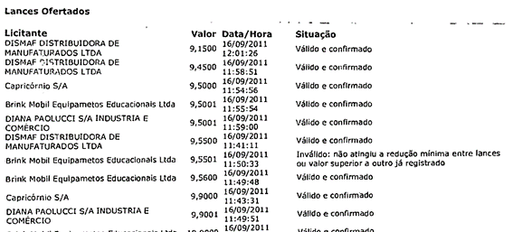

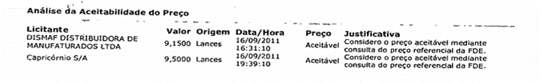

No que diz respeito ao segundo lote, novamente, tanto a Capricórnio quanto a Diana Paolucci e a Brink Mobil participaram e efetuaram propostas, tendo a Capricórnio, mais uma vez, na linha do quanto exposto pelo Signatário, se sagrado a vencedora. Como se observa do trecho da Ata da Sessão Pública demonstrada abaixo<sup><sup>[125]</sup></sup>, verifica-se que as propostas iniciais e lances ofertados foram idênticos e uniformizados, além da diferença de apenas 0,0001 centavo entre os lances finais efetuados pela Capricórnio e Brink Mobil. Similarmente ao quanto concluído acima, considerando o valor das propostas apresentadas e o contexto apresentado pelo Signatário, entendo haver indícios claros de que ao menos os lances da Brink Mobil e da Diana Paolucci foram de cobertura, já que foram iguais ou muito próximos um dos outros:

**Imagem - Lote 2 – Propostas de Classificação e Parte Final dos Lances Ofertados**

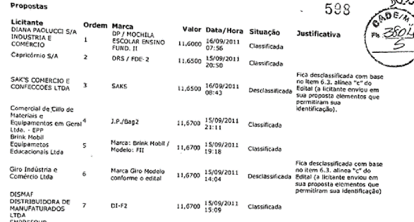

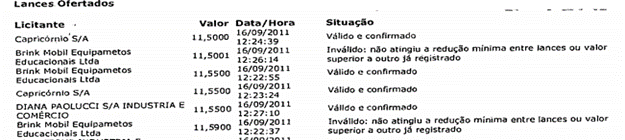

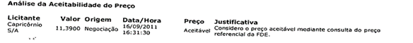

Ademais, destaco ainda que o Signatário também juntou declaração de seu advogado, registrada em cartório em 03 de agosto de 2011<sup><sup>[126]</sup></sup>, isto é, um dia antes da primeira data agendada para a realização da sessão do pregão (que foi postergado para 16 de setembro), na qual informou acerca da “*suspeita de que haverá formação de cartel empresas do ramo para que os licitantes Capricórnio S/A, Brink Mobil Equipamentos Educacionais e Diana Paolucci S/A Indústria e Comércio se sagrem vencedores dividindo de alguma forma os três lotes do certame*”. Considerando a data e o conteúdo de tal declaração, entendo que tal documento comprova a ciência prévia do Signatário acerca dos resultados do certame, reforçando, portanto, as demais provas sobre o ajuste prévio entre tais Representadas.

Portanto, entendo não haver dúvidas acerca da participação da Brink Mobil no aludido certame, tendo apresentado lances de cobertura nos dois primeiros lotes e ganhado o certame no terceiro lote.

Ademais, compreendo ainda existirem provas suficientes que demonstram a participação da Representada no conluio praticado no Pregão Presencial nº 011/2011-SE promovido pelo Município de Guarulhos/SP em dezembro de 2011. Isso porque, conforme já evidenciado, a resposta ao Ofício nº 5009/2018/SG fornecida pela Prefeitura de Guarulhos, por meio do Ofício nº 153/2018-CEDEL Guarulhos (SEI 0476866 - p. 35 pdf.), trouxe informações claras de que, em tal licitação, que a Excel se sagrou a vencedora, tanto a Excel, Brink Mobil e Bigpar, quanto a Capricórnio e Castro e Castro, ofertaram preços idênticos, tendo a Diana Paolucci ofertado preço acima de todas, conforme pode ser visualizado abaixo. As propostas idênticas, como se observa, contemplam tanto os itens como preços finais, não havendo dúvidas quanto ao acordo entre tais empresas. No caso da Brink Mobil, como mencionado, o que se observa é que o preço dos sete itens ofertados são exatamente os mesmos da Excel e da Bigpar, não havendo qualquer explicação razoável para que, em condições normais de concorrência, empresas concorrentes ofertassem os mesmos preços:

**Imagem - Resposta da Prefeitura de Guarulhos ao Ofício nº 5009/2018/SG (SEI 476866)**

**[ACESSO RESTRITO AOS REPRESENTADOS]**

Entendo, portanto, que a participação da Representada em tal conluio também se encontra devidamente comprovada.

Por fim, na busca e apreensão realizada na sede da empresa Capricórnio, verifica-se anotações na agenda de Reinaldo Paolucci que demonstram que a empresa participava da divisão de mercado realizada pelo cartel, conforme se observa no que diz respeito ao Programa Mãe Paulistana, junto a outras licitações de outras empresas, ilustrada abaixo (SEI 0129507 - 20-G – 20130123124158125, p. 34). Em consonância com a SG/CADE e considerando as demais provas nos autos, já demonstradas no presente voto, entendo que tal agenda aponta claramente na direção da divisão de mercado por meio de subcontratação:

**Imagem - Agenda**

**[ACESSO RESTRITO AOS REPRESENTADOS]**

Além disso, conforme demonstrado pela SG/CADE (SEI 0561745 – parágrafos 310 e seguintes; e 713), outras anotações manuscritas foram identificadas relativas ao Programa Mãe Paulistana:

*“**Técio brink (valor para faturar kit mãe paulistana?)”; “R$ 5.000,00 referente ao Junior na nota fiscal da Brink Mobil”,** “cobrar Brink Mobil 5.500 cobertores R$ 18,00 = R$ 99.000,00 ... verificar quanto já foi entregue do kit da Mãe Paulistana”; **“Técio Brinkmobil sobre entrega dos kits da mãe paulistana (cobertor) – cobrar R$ 5000 de comissão dada pela Capricórnio**”; “Mãe Paulistana - Brink Mobil - Técio (...) Kit escolar 27/10/10 } R$ 669.500,00”; “Brink Mobil → Técio → jantar → cobrar mãe paulistana”, “Reunião com Brinkmobil – Waldemar 1) cobertores da Murad no kit (foi culpa deles eu ter comprado esses cobertores) 2) compra pelo FDE fanfarra” e “verificar pagamento da Brink Mobil dos cobertores 5500 pçs”.* (grifos nossos)

Em sua defesa, a Representada sustentou que a subcontratação da empresa Capricórnio no Programa Mãe Paulistana<sup><sup>[127]</sup></sup> se deu somente em razão do processo de contratação emergencial e de prazos curtos, ressaltando, ainda, o litígio gerado em razão do referido pregão<sup><sup>[128]</sup></sup>. Entendo, no entanto, que tal argumento não é suficiente para justificar a divisão de mercado por meio da subcontratação, havendo elementos suficientes que demonstram o ilícito.

Ante o exposto, entendo, existir nos autos provas inequívocas da participação da empresa Brink Mobil no cartel ora sob exame, motivo pelo qual voto pela sua condenação, nos termos dos arts. 20, I, e 21, I, III e VIII, da Lei nº 8.884/94, correspondentes ao art. 36, I, e § 3º, inciso I, “a”, “c” e “d”, da Lei nº 12.529/2011.

IV.4.1. (a) Valdemar Ábila – Pessoa física administradora da Brink Mobil

Conforme consta nos autos, o Representado Valdemar Ábila é sócio fundador e administrador da empresa Brink Mobil (SEI 0146271 e 0433771) e, portanto, é considerado administrador, nos termos do art. 1.060 do Código Civil, para fins do art. 37, III, da Lei nº 12.529/11.

No que diz respeito à sua participação nas condutas anticompetitivas, entendo existirem provas suficientes que demonstram a participação do Representado no Pregão Eletrônico n° 36/00499/11/05 promovido pela FDE. Nesse sentido, a conversa entre Mickael e Djalma Santos demonstra que, além de Valdemar ser a pessoa responsável pelo contato com Julio Manfredini, ele estaria de acordo com a divisão de mercado:

**[ACESSO RESTRITO AOS REPRESENTADOS]**<sup><sup>[129]</sup></sup>

**[ACESSO RESTRITO AOS REPRESENTADOS]**<sup><sup>[130]</sup></sup>

**Lote 3<sup>**<sup>[131]</sup>**</sup> - Propostas de Classificação e Parte Final dos Lances Ofertados**

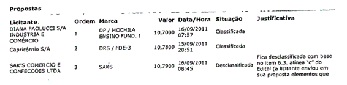

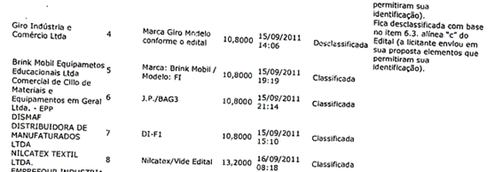

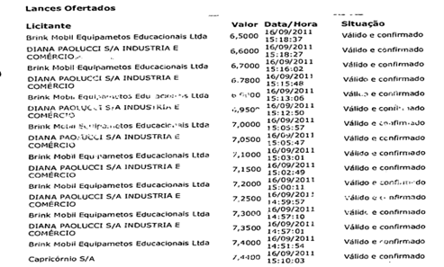

Dessa forma, além de haver provas de que a Brink Mobil apresentou propostas de cobertura nos dois primeiros lotes e proposta inicial de **[ACESSO RESTRITO AOS REPRESENTADOS]** no terceiro lote, o teor das conversas indicadas acima, inclusive pela reação do Signatário, não deixa quaisquer dúvidas de que o Representado era o interlocutor com quem os membros do cartel conversaram e combinaram o conluio. Não menos importante, ressalto, por fim, que o Representado era o sócio administrador da Brink Mobil, sendo, portanto, a pessoa com poder de decisão sobre as estratégias da empresa.

Portanto, ainda que as conversas trazidas pelo Signatário consistam em provas indiretas em desfavor do Representado, uma vez se tratar de uma conversa de terceiros, quando analisadas conjuntamente com as demais provas e fatos acostados nos autos, permitem, de forma coerente e concatenada, fundamentar a certeza da participação do Representado no conluio.

Por conta do exposto, entendo que o conjunto probatório é suficiente para aferir que o Representado esteve envolvido no conluio referente ao Pregão Eletrônico n° 36/00499/11/05, motivo pelo qual, em consonância com os entendimentos da SG, ProCADE e MPF, voto pela sua condenação, nos termos dos arts. 20, I, e 21, I, III e VIII, da Lei nº 8.884/94, correspondentes ao art. 36, I, e § 3º, inciso I, “a”, “c” e “d”, da Lei nº 12.529/2011.

IV.5. Excel Materiais e Serviços Ltda.

Conforme exposto no presente voto, as provas acostadas nos autos demonstram que a Representada Excel participou ativamente do cartel em licitações públicas destinadas à aquisição de kits de material escolar para alunos da rede pública de ensino, dentre outras, conforme restou evidenciado no presente voto, nas licitações Pregão Presencial nº 011/2011-SE promovido pela Prefeitura de Guarulhos/SP e PP 37.2011 promovido pela Prefeitura de Ibiúna/SP.

No que diz respeito aos seus argumentos de defesa, por economia processual e considerando o conjunto de provas em desfavor da Representada, acato na íntegra o quanto exposto pela SG/CADE nos parágrafos 624 e seguintes da Nota Técnica nº 96/2018/CGAA8/SGA2/SG/CADE (Anexo – SEI 0561745), motivo pelo qual entendo não ser necessário reproduzir tal exposição novamente no presente voto.

No que diz respeito à participação da Representada, observo existir provas nos autos suficientes para corroborar a sua participação nos ilícitos investigados. Nesse sentido, diferentemente do quanto defendido pela Excel, entendo que o seu envolvimento no conluio ocorrido no Pregão Presencial nº 011/2011-SE (Município de Guarulhos/SP) está devidamente comprovado nos autos. Isso porque, além de o Signatário ter inicialmente relatado que as Representadas Excel 3000, Diana Paolucci, Capricórnio e Mercosul fizeram parte do conluio (2009-2011) e apresentado documentos para corroborar o quanto narrado<sup><sup>[133]</sup></sup>, a resposta ao Ofício nº 5009/2018/SG encaminhada pela Prefeitura de Guarulhos<sup><sup>[132]</sup></sup> não deixa dúvidas do quanto exposto pelo Signatário. Nessa linha, conforme já demonstrado no presente voto (parágrafos 73 e seguintes), como estratégia de cobertura de propostas, as empresas Excel, Brink Mobil e Bigpar ofertaram preços idênticos, além das empresas Capricórnio e Castro e Castro, não havendo dúvidas quanto ao acordo entre tais empresas:

**Imagem - Tabelas**

**[ACESSO RESTRITO AOS REPRESENTADOS]**

Ao final, a Excel se sagrou a vencedora de tal certame, conforme informado pela mencionada resposta da Prefeitura de Guarulhos<sup><sup>[134]</sup></sup>.

Em complemento, observo ainda que a divisão de mercado também está evidenciada por anotações na Agenda de Reinaldo Paolucci<sup><sup>[135]</sup></sup>, obtida na busca e apreensão realizada na empresa. Na referida agenda, **[ACESSO RESTRITO AOS REPRESENTADOS]**:

**Imagem - Anotações - Agenda Reinaldo Paolucci**

**[ACESSO RESTRITO AOS REPRESENTADOS]**

Considerando o conjunto probatório demonstrado acima, que corrobora o quanto narrado pelo Signatário, entendo não haver dúvidas da participação da Representada no referido conluio promovido pelo município de Guarulhos, Estado de São Paulo.

Ademais, dentre os documentos apreendidos na Excel, a planilha demonstrada abaixo<sup><sup>[136]</sup></sup> evidencia a nítida divisão de mercado e subcontratação, fazendo referência ao município, objeto do certame e da pessoa/empresa alocada para ganhar a licitação, como por exemplo na licitação de Ibiúna para a aquisição de uniformes escolares (Pref. Ibiúna. PP 37.2011) “*Não vamos, é da Capricórnio*”. Em tal documento, apenas as Representadas Capricórnio e Mercosul são mencionadas<sup><sup>[137]</sup></sup>:

**Imagem - Planilha - “Relação das Licitações”**

**[ACESSO RESTRITO AOS REPRESENTADOS]**

Em complemento a tal documento, observo que, em busca e apreensão promovida na sede da Capricórnio, foram apreendidas ainda tabelas que estão vinculadas à mesma licitação referida acima, contendo os valores unitários e totais dos Representados Mercosul e Tecelagem Guelfi, além de outras empresas não representadas<sup><sup>[138]</sup></sup>. Ao analisar tais documentos, observo que a Excel não foi mencionada nas tabelas apreendidas na Capricórnio, fato que reforça a divisão de mercado e corrobora o conteúdo da planilha demonstrada acima.

Por conta do exposto, acato as considerações e conclusões da SG/CADE, ProCADE e MPF e voto pela condenação da Representada Excel nas práticas anticompetitivas ora analisadas, nos termos dos arts. 20, I, e 21, I, III e VIII, da Lei nº 8.884/94, correspondentes ao art. 36, I, e § 3º, inciso I, “a”, “c” e “d”, da Lei nº 12.529/2011.

IV.5.1. (a) Márcio Nogueira Vignoli

Já no que diz respeito ao Representado Márcio Nogueira Vignoli, ressalto, desde já, que discordo do posicionamento da SG/CADE e da ProCADE, e alinho-me às as conclusões do MPF, por entender não haver nos autos provas suficientes para a sua condenação.

Nesse sentido, muito embora: (i) o Signatário tenha apontado a participação do Representado no Pregão Eletrônico nº 36/00496/11/05 promovido pela FDE/SP em 2011 e na licitação promovida pelo Município de Guarulhos/SP em 2009; e (ii) conforme demonstrado no presente voto (parágrafos 82-88), a Excel tenha de fato vencido as licitações de 2009 e 2011 promovidas pelo Município de Guarulhos<sup><sup>[139]</sup></sup>, entendo não haver nos autos provas adicionais capazes de demonstrar o envolvimento do Representado e corroborar o quanto alegado pelo Signatário. Por esse motivo, compreendo que os indícios trazidos pelo Signatário não são suficientes para confirmar a participação do Representado em tais licitações.

Além disso, já quanto aos encontros de Márcio com os principais dirigentes da Mercosul (Antônio Borelli e Roberto Nakano), além de Jannivaldo Marques na Mercosul, muito embora os documentos apreendidos na Mercosul corroborem tais encontros (SEI 0418302 - PIC 10-12 - ANEXO IV – 2º e 5º volumes), eles não trazem quaisquer informações sobre o teor discutido em tais ocasiões. Por conta disso, entendo que tais documentos não são suficientes para demonstrar que tais encontros serviram para fins anticompetitivos e, por si só, não devem ser considerados como provas de que o Representado esteve envolvido nas práticas anticompetitivas ora analisadas.

Ante o exposto, voto pelo arquivamento do processo em relação ao Representado Márcio Nogueira Vignoli, ante a insuficiência de provas.

IV.6. Nilcatex Têxtil Ltda.

As provas acostadas nos autos demonstram que a Representada Nilcatex participou das condutas anticompetitivas investigadas, conforme restou comprovado nos documentos relacionados à licitação promovida pela Prefeitura de São Caetano em 2011, bem como nos Pregões Presenciais 024/08-SE e 457/09-DCC promovidos pela Prefeitura de Guarulhos/SP, conforme explicitado nos parágrafos 70 a 80 do presente voto.

No que diz respeito aos argumentos de defesa, por economia processual, acato na íntegra o quanto exposto pela SG/CADE nos parágrafos 669 e seguintes da Nota Técnica nº 96/2018/CGAA8/SGA2/SG/CADE (Anexo – SEI 0561745), motivo pelo qual entendo não ser necessário reproduzir tal exposição novamente.

Quanto à participação da Representada na licitação promovida pela Prefeitura de São Caetano em 2011, conforme relatado pelo Signatário, em 2011, Abelardo Paolucci (Sócio e Presidente da Diana Paolucci) solicitou que o Signatário conduzisse negociações com Eldo Umbelino (também conhecido como “Castelo”, Diretor Vice-Presidente da Nilcatex), para que esta se abstivesse de participar da referida licitação, cujo objeto foi a aquisição de uniformes escolares e tênis. Segundo o depoimento do Signatário, a licitação seria direcionada para a empresa Diana Paolucci, no entanto, para que o conluio pudesse ser concretizado, era necessário que a Nilcatex não participasse, ou seja, que tais empresas não competissem com as outras. Nesse sentido, para que a Nilcatex concordasse com o conluio, a Diana Paolucci deixaria de participar de licitações promovidas em outros municípios em benefício da Nilcatex<sup><sup>[140]</sup></sup>.

Para corroborar o narrado, o CADE teve acesso a troca de e-mails<sup><sup>[141]</sup></sup>, de janeiro de 2012, entre Eldo Umbelino e o Signatário, além de e-mails trocados anteriormente (na mesma cadeia de e-mails) entre a Diana Paolucci e a Capricórnio. Diante de uma discordância entre a Diana Paolucci e a Nicaltex acerca do que havia sido combinado, Eldo solicitou explicações ao Signatário, que, por sua vez, reforçou o que havia sido acordado acerca da licitação no Município de São Caetano:

**Imagem - Cadeia de E-mails – “Resposta Solicitada”**

**[ACESSO RESTRITO AOS REPRESENTADOS]**

De acordo com a defesa da Nilcatex (SEI 0145832), a empresa não teria participado de tal licitação pela impossibilidade técnica da empresa de obter as amostras nos prazos e nas condições exigidas no edital, e não por conta de suposto ajuste com quem quer que fosse. Observo que tal justificativa foi inclusive afirmada pelo **[ACESSO RESTRITO AOS REPRESENTADOS]**.

No entanto, embora tenha havido uma contradição entre os relatos do Signatário, entendo que a justificativa da Representada sobre a sua não participação no certame não esclarece a indagação do próprio Eldo Umbelino ao Signatário sobre o que **[ACESSO RESTRITO AOS REPRESENTADOS]**.

Isto é, se a justificativa sobre a não participação da Representada fosse meramente de que não dispunha de amostras, certamente o Representado não teria indagado o Signatário acerca do “acerto” no referido certame. Além disso, se a resposta do Signatário ao e-mail do Representado estivesse equivocada, o Representado provavelmente teria contestado tal explicação (seja por e-mail ou qualquer outro meio), já que era de seu interesse esclarecer os fatos e não ser prejudicado na ocasião. No entanto, não foram identificados nos autos uma resposta ou até mesmo uma posterior contestação ao e-mail do Signatário, cabendo à defesa da Representada tão somente argumentar que tal e-mail não possuiria qualquer credibilidade (SEI 0145832). Portanto, entendo que as justificativas trazidas pela Representada sobre o “acerto” são incompletas e incapazes de justificar o e-mail de Eldo Umbelino, o qual foi posteriormente esclarecido pelo Signatário, conforme demonstrado acima.

Em complemento, compreendo que a divisão de mercado também está corroborada por anotações na agenda de Reinaldo Paolucci (Representante Comercial da Capricórnio)<sup><sup>[142]</sup></sup>, obtida na busca e apreensão realizada na Capricórnio, que, além de evidenciar a divisão de mercado narrada pelo Signatário, demonstra também a ciência da própria Capricórnio sobre o conluio acertado entre a Diana Paolucci e a Nilcatex. Na referida agenda, há menção sobre a divisão das licitações entre as empresas, em que há anotações sobre Diana ser a vencedora da licitação de São Caetano, bem como sobre a Nilcatex ficar com a licitação do município de Joinville, conforme ilustrada abaixo:

**Imagem - Anotações - Agenda Reinaldo Paolucci**

**[ACESSO RESTRITO AOS REPRESENTADOS]**

Ressalto, no entanto, que ao analisar a resposta da Prefeitura de São Caetano ao Ofício nº 5008/2017/CADE (SEI 0386484), esta informou que, entre 2007 e 2012, o único contrato celebrado com a Representada Diana Paolucci em tal período originou-se do Pregão Presencial 01/2009, e não da licitação ocorrida em 2011, fato que, a princípio, contraria parcialmente o quanto narrado pelo Signatário, já que a Diana Paolucci não foi a vencedora de tal certame.

Entendo, no entanto, que a resposta da Prefeitura de São Caetano não retira a ilicitude da prática, uma vez que, para a caracterização do conluio, não é necessário que se tenha o resultado, mas sim a suficiência da materialidade da conduta (i.e., do acordo em questão) e da autoria. Dessa forma, ainda que a Diana Paolucci não tenha se sagrado a vencedora do certame, tal fato não retira a caracterização da divisão de mercado praticada pela Representada, demonstrada acima.

Diante do exposto, entendo que a participação da Representada no conluio está devidamente demonstrada nos presentes autos.

Por fim, entendo haver nos autos documentos adicionais que apontam para o envolvimento da Representada no cartel nos Pregões Presenciais 024/08-SE e 457/09-DCC promovidos pela Prefeitura do Município de Guarulhos/SP.

Com efeito, a Nilcatex apareceu como uma das “parceiras” da Diana Paolucci em planilhas denominadas “Relatório de Contratos” e “Comissões Renato” (SEI 0418310 – PIC 10-12 – Anexo V – fls. 19 e seguintes), apreendidas no quarto do Representado Kalvin Paolucci (demonstradas no presente voto nos parágrafos 85 e seguintes), que evidenciam quem seriam as empresas vencedoras, “parceiros”, além de ilustrar os custos, lucros, subcontratação e pagamento de comissão entre as empresas. Em tais planilhas, a Representada foi parceira da Diana Paolucci nas licitações ocorridas na Prefeitura de Santos e de Guarulhos, indicando uma divisão de mercado e reforçando a subcontratação entre as empresas<sup><sup>[143]</sup></sup>:

**Imagem – Planilhas**

**[ACESSO RESTRITO AOS REPRESENTADOS]**

Por fim, no que se refere ao Pregão Presencial 024/08-SE, também promovido pela Prefeitura de Guarulhos, ao analisar as tabelas demonstradas acima em conjunto com a resposta da Prefeitura de Guarulhos ao Ofício nº 5009/2018/SG (SEI 0476866 - p. 15 e seguintes pdf.), constato que todas as empresas “parceiras”, mencionadas na tabela acima (*i.e.*, Nilcatex, Diana Paolucci, Mercosul, Dilmatex, Nayr, Celi Confecções ME. e Fibrasil) participaram e concorreram entre si no referido pregão, tendo a Nayr (não Representada no presente processo) se sagrado a vencedora de tal certame. A tabela reforça ainda a divisão de mercado entre elas quando se refere “*Nayr – faturar 1/7 contra Nayr*”, indicando exatamente a divisão igualitária (i.e., 1/7) entre as sete parceiras, não havendo qualquer justificativa concorrencialmente plausível para tanto. Portanto, ainda que na resposta da Prefeitura de Guarulhos não se observe preços idênticos, entendo que, ao analisar conjuntamente os referidos documentos, há elementos suficientes para concluir acerca da divisão de mercado entre as sete empresas em tal pregão.

Ante o exposto, entendo que a participação da Nilcatex no cartel restou devidamente demonstrada, motivo pelo qual voto pela sua condenação, nos termos dos arts. 20, I, e 21, I, III e VIII, da Lei nº 8.884/94, correspondentes ao art. 36, I, e § 3º, inciso I, “a”, “c” e “d”, da Lei nº 12.529/2011.

IV.6.1. (a) Eldo Umbelino – Pessoa física administradora da Nilcatex

Eldo Umbelino é sócio da Nilcatex e desde 09 de abril de 2009 exercia conjuntamente a administração da empresa (SEI 0145186 <sup><sup>[144]</sup></sup>), podendo ser, portanto, a partir de tal data, considerado administrador, nos termos do art. 1.060 do Código Civil, para fins do art. 37, III, da Lei nº 12.529/11.

No que diz respeito aos argumentos de defesa, da mesma forma, por economia processual, acato na íntegra o quanto exposto pela SG/CADE nos parágrafos 669 e seguintes da Nota Técnica nº 96/2018/CGAA8/SGA2/SG/CADE (Anexo – SEI 0561745), motivo pelo qual entendo não ser necessário reproduzir tal exposição novamente.

Entendo que a participação do Representado no cartel está demonstrada na divisão de mercado relacionada à licitação promovida pela Prefeitura de São Caetano em 2011. Em primeiro lugar, entendo que a divisão de mercado relacionada a tal licitação está devidamente comprovada nos presentes autos, conforme explicitado exaustivamente nos parágrafos 70 a 80 acima.

Conforme explicitado na individualização da Nilcatex, o envolvimento do Representado pode ser visualizado na cadeia de e-mails, na qual o Representado foi o remetente do e-mail encaminhado ao Signatário, com cópia tanto para pessoas da Capricórnio quanto da Diana Paolucci. Diante da desavença sobre a incorporação de IR/CSSL no cálculo da rentabilidade dos acertos entre as três empresas, o Representado solicitou ao Signatário que confirmasse o que o Signatário e o Renato acordaram com ele e o seu representante Alonso sobre o pregão de São Caetano do Sul. Como resposta, o Signatário reforçou o que havia sido acordado acerca da licitação no Município de São Caetano<sup><sup>[145]</sup></sup>:

**Imagem - Cadeia de E-mails – “Resposta Solicitada”**

**[ACESSO RESTRITO AOS REPRESENTADOS]**

De acordo com a defesa do Representando (SEI 0145832), a empresa não teria participado de tal licitação pela impossibilidade técnica da empresa de obter as amostras nos prazos e nas condições exigidas no edital, e não por conta de suposto ajuste com quem quer que fosse. Observo que tal justificativa foi inclusive afirmada pelo **[ACESSO RESTRITO AOS REPRESENTADOS]**.

No entanto, embora tenha havido uma contradição entre os relatos do Signatário, entendo que a justificativa do Representado sobre a sua não participação no certame não esclarece a indagação do próprio Eldo Umbelino ao Signatário sobre o que **[ACESSO RESTRITO AOS REPRESENTADOS]**.

Isto é, se a justificativa sobre a não participação da Representada fosse meramente de que não dispunha de amostras, certamente o Representado não teria indagado o Signatário acerca do “acerto” no referido certame. Além disso, se a resposta do Signatário ao e-mail do Representado estivesse equivocada, o Representado provavelmente teria contestado tal explicação (seja por e-mail ou qualquer outro meio), já que era de seu interesse esclarecer os fatos e não ser prejudicado na ocasião. No entanto, não foram identificados nos autos uma resposta ou até mesmo uma posterior contestação ao e-mail do Signatário, cabendo à defesa da Representada tão somente argumentar que tal e-mail não possuiria qualquer credibilidade (SEI 0145832). Portanto, entendo que as justificativas trazidas pela Representada sobre o “acerto” são incompletas e incapazes de justificar o e-mail de Eldo Umbelino, o qual foi posteriormente esclarecido pelo Signatário, conforme demonstrado acima.

Ante o exposto, entendo que a participação de Eldo Umbelino no cartel restou devidamente demonstrada, motivo pelo qual voto pela sua condenação, nos termos dos arts. 20, I, e 21, I, III e VIII, da Lei nº 8.884/94, correspondentes ao art. 36, I, e § 3º, inciso I, “a”, “c” e “d”, da Lei nº 12.529/2011.

IV.7. Attendy Artigos de Vestuário e Confecções Ltda.

As provas acostadas nos autos demonstram que a Representada Attendy participou ativamente das condutas anticompetitivas investigadas, conforme restou comprovado nos documentos relacionados a licitações, de números não especificados, promovidas pelas Prefeituras de Itanhaém/SP e Itupeva/SP nos anos de 2011.

No que diz respeito aos seus argumentos de defesa, por economia processual, acato na íntegra o quanto exposto pela SG/CADE nos parágrafos 271 e seguintes da Nota Técnica nº 96/2018/CGAA8/SGA2/SG/CADE (Anexo – SEI 0561745), motivo pelo qual entendo não ser necessário reproduzir tal exposição novamente no presente voto.

Conforme exposto no presente voto, a proximidade comercial existente entre a Mercosul e a Attendy acabou por ultrapassar os limites de uma relação legítima entre elas. Como explicitado pela SG/CADE (SEI 0561745 - parágrafos 273 e seguintes), as Representadas Attendy e Mercosul possuíam uma relação comercial próxima, tendo a Mercosul inclusive administrado informalmente a Attendy, devido às dificuldades financeiras que esta enfrentava à época<sup><sup>[146]</sup></sup>.

Nesse contexto, a existência de divisão de mercado praticada entre a Mercosul, Attendy e a J.Educ. Fabril Ltda. (empresa não Representada), referente ao certame promovido pela Prefeitura de Itanhaém, Estado de São Paulo pode ser visualizada no e-mail intitulado “ITANHAEM KITS”<sup><sup>[147]</sup></sup>, apreendido na sede da Excel (SEI 0418310, Anexo VI, 1º Volume, fls. 59-62). Conforme se verifica, José Renato (J.Educ. Fabril Ltda.) se reuniu com Antonio Borelli (Diretor-Presidente da Mercosul) e Vanderlei Pinto dos Santos Júnior (Attendy), em 12 de maio de 2011, para combinar sobre a forma com que operacionalizariam a divisão do lote 4 e dos demais lotes do certame. Em tal ocasião, acordaram sobre a emissão de pedidos de compra, encaminhamento de propostas “equacionadas” para a Prefeitura nos demais lotes em nome da Mercosul, retirada dos empenhos junto à Prefeitura, dentre outras questões. Por fim, combinaram ainda uma reunião futura para “*conciliar valores e apurar os resultados da operação*” (SEI 0418310, Anexo VI, 1º Volume, fls. 59-62):

**Imagem - E-mail - “ITANHAEM KITS”**

**[ACESSO RESTRITO AOS REPRESENTADOS]**

Do mesmo modo, constato ainda a existência de outros documentos que apontam para reuniões adicionais ocorridas entre a Mercosul e a Attendy, relacionadas a outras licitações, para os mesmos fins anticompetitivos.

No envelope apreendido na sede da Excel, referente à Prefeitura de Itupeva, por exemplo, consta documento assinado por Júnior (i.e., Vanderlei Pinto dos Santos Júnior – Attendy), que formalizou o resumo de uma reunião ocorrida entre ele e Antônio Borelli (Mercosul). Na ocasião, discutiram sobre as condições nas quais as licitações a serem realizadas em Itupeva/SP, Guaruja/SP e Itanhaém/SP seriam divididas, bem como sobre a subcontratação de fornecimento de produtos, custos e logística, dentre outras questões. Conforme pode ser visualizado abaixo, tal documento demonstra a estruturação da divisão de mercado entre a Mercosul e a Attendy, juntamente com a empresa J. Educ. Fabril Ltda. (não Representada), em municípios do estado de São Paulo (SEI 0129574 - Mídia Parte 7 - fls. 523 - Excell 3000 – separados GEDEC – documento Excell 3000 – 1 p. 35 pdf.):

**Imagem – Documento**

**[ACESSO RESTRITO AOS REPRESENTADOS]**

No que diz respeito à aludida licitação de Itupeva (Pregão nº 031/2011), observo que o referido “negócio”, mencionado por Júnior acima, foi efetivamente implementado por tais empresas, já que a Attendy foi a vencedora do certame, conforme contrato celebrado com a Prefeitura Municipal de Itupeva, acostada no referido envelope apreendido na sede da Excel (SEI 0129574 - Mídia Parte 7 - fls. 523 - Excell 3000 – separados GEDEC – documento Excell 3000 – 1, p. 5 e seguintes pdf.). Por conta disso, entendo não haver quaisquer dúvidas acerca da divisão de mercado conduzida por tais empresas.

Por fim, no que diz respeito a documentos adicionais apreendidos na sede da Excel relacionados ao compartilhamento de cotações de preços que vinculam a Representada, ressalto haver uma contradição inicial ocorrida entre a defesa da Representada (SEI 0147520) e a defesa da Excel (SEI 0083370) quanto aos documentos apreendidos na sede desta. Isso porque, enquanto a Attendy argumentou que os documentos apreendidos na sede da Excel não teriam sido enviados ou produzidos pela Attendy, a Excel afirmou que todos os documentos apreendidos que mencionam a Attendy pertenciam a tal empresa, uma vez que a sua sala comercial havia sido cedida gratuitamente e sem formalização à Attendy por alguns meses em 2012. Como forma de corroborar tal afirmação, a Excel juntou uma declaração firmada por Carlos Roberto Maielo, ex-sócio da Attendy, à sua defesa<sup><sup>[148]</sup></sup>:

*“Fui sócio da empresa ATTENDY ARTIGOS DE VESTUÁRIO E CONFECÇÕES LTDA., no período de 2010 a 2012.*

*No ano de 2012 a empresa Attendy estava passando por algumas dificuldades e o Sr. Paulo Vieira, sócio da Excel 3000 permitiu que eu utilizasse o escritório da filial da empresa na cidade de São Paulo, localizado na Vila Olímpia. Nesse período era utilizado o espaço físico da sala, bem como móveis e um microcomputador.*

*Dessa forma, as informações contidas nos documentos eletrônicos, especialmente "Uniforme Escolar Volta Redonda - Attendy.doc", e o "pregão presencia 100124republicacao.doc", este correspondente ao Edital do Pregão Presencial nº 124/2010 da Secretaria Municipal de Educação de Goiânia/GO pertenciam à empresa Attendy, até porque, era sabido no mercado que a empresa Excel 3000 não fornecia uniformes, apenas material escolar.*

*Também declaro que a agenda apreendida na sala comercial da EXCEL 3000 é de minha propriedade, utilizada para atender os compromissos profissionais da empresa ATTENDY, não tendo qualquer relação com os compromissos profissionais da empresa EXCEL 3000”*.

Muito embora existam cotações de outras empresas relacionados aos Municípios de Volta Redonda, Ponte Nova, à Secretaria Municipal de Educação de Goiânia/GO e ao Ministério da Defesa, o que indicaria alinhamento entre empresas para a proposição de cotações/propostas fictícias, entendo que o fato de a Attendy ter utilizado o escritório da Excel em 2012 torna no mínimo duvidoso o compartilhamento de suas cotações à época com os seus concorrentes. Por conta disso, e considerando não haver documentos adicionais (tais como e-mails etc.) que corroborem a conduta relacionada aos certames relacionados aos documentos apreendidos, entendo que, por si só, tais documentos são insuficientes para comprovar o envolvimento da Representada nos certames indicados acima. Da mesma forma, entendo ainda ser insuficiente para comprovar o envolvimento da Representada a cotação de preço da empresa apreendida na sede da Mercosul relacionada ao Município de Volta Redonda (fls. 743 do processo nº 08700.011956/2014-65).

Ante o exposto, voto pela condenação da Representada Attendy, nos termos dos artigos 20, I e 21, incisos I, III e VIII, da Lei nº 8.884/94, vigente à época dos fatos, equivalente ao art. 36, incisos I c/c seu § 3º, inciso I, alíneas “a” "c" e "d" da Lei nº 12.529/2011.

IV.8. NCR Uniformes Ltda.

No que diz respeito ao Representado NCR Uniformes Ltda., embora tenha sido devidamente citada por edital (SEI 0100690, 0111404, 0112142 e 0116985), não apresentou defesa, sendo, portanto, declarada revel, conforme art. 71 da Lei nº 12.529/2011 (SEI 0159523).

A despeito disso, tanto a SG/CADE, ProCADE e o MPF manifestaram-se pelo arquivamento do processo em face de tal Representada, ante a insuficiência de provas para a sua condenação.

Passo, então, à análise dos elementos colhidos contra a Representada, de forma a confirmar ou não as conclusões dos referidos pareceristas.

Observo que a única evidência constante nos autos contra a Representada refere-se à anotação manuscrita, de autoria de Reinaldo Paolucci, e datada de 17 de fevereiro de 2007 (SEI 0008149, fls. 771), em que há a indicação de **[ACESSO RESTRITO AOS REPRESENTADOS]**, conforme demonstrada abaixo:

**Imagem - Anotações - Agenda Reinaldo Paolucci**

**[ACESSO RESTRITO AOS REPRESENTADOS]**

Ao analisar tal documento, verifico que as anotações de Reinaldo Paolucci demonstram os cálculos para a apresentação de proposta à FDE, além da porcentagem que a proposta de concorrentes ficaria acima da proposta da Capricórnio.

No entanto, ainda que se considere que tal anotação trata-se de uma prova direta acerca da divisão de mercado por meio de cobertura de propostas, entendo que tal anotação é insuficiente para confirmar a participação da Representada NCR Uniformes no conluio. Isso porque, embora se presuma que tenha havido a divisão de mercado ou ao menos a troca de informações entre ele e a NCR Uniformes, como se trata de um documento elaborado por Reinaldo Paolucci (i.e., por um terceiro), entendo que, para a caracterização do envolvimento da Representada, tal documento não é por si só capaz de confirmar que ela tenha tomado ciência e/ou efetivamente aderido à proposta escrita por Reinaldo, devendo existir provas adicionais que corroborem o seu envolvimento na conduta.

Por conta disso, adiro ao entendimento da SG/CADE, ProCADE e MPF e voto pelo arquivamento do processo em relação à NCR Uniformes, ante a insuficiência de provas.

IV.9. Tecelagem Guelfi Ltda.

No que diz respeito à Representada Tecelagem Guelfi, esta afirmou em sua defesa (SEI 0138980) que foi mencionada no processo tão somente em virtude de terem sido apreendidas no computador da Mercosul 05 (cinco) minutas de cotação em papeis que não teriam sequer a estampa original da empresa. Além disso, tais minutas estariam desprovidas de assinaturas da Representada, e nem poderiam, pois seriam documentos falsificados por terceiro. Por conta disso, os indícios em seu desfavor seriam insuficientes para permitir a conclusão de existência de infração à ordem econômica, devendo o processo ser devidamente arquivado contra ela.

Com relação às minutas de cotação (SEI 0008149 - fls. 728, 734-736 e 742, referentes às licitações dos Municípios de Hortolândia/SP, Santana do Parnaíba/SP e Itapevi/SP, respectivamente), adiro ao entendimento da SG/CADE e entendo que “*sem ser confirmadas ou reforçadas por qualquer outra evidência, estes documentos não ultrapassam a categoria de indícios e são insuficientes para embasar decreto condenatório com base em infração à ordem econômica*” (SEI 0561745, parágrafo 760). Nesse sentido, entendo que as cotações encontradas nos arquivos da Mercosul constituem prova isolada, sem comprovação de que a Representada tenha tido ciência sobre tais documentos.

Ademais, já quanto às tabelas apreendidas na sede da Capricórnio referentes à licitação de Ibiúna (PP 37.2011)<sup><sup>[149]</sup></sup>, nas quais há os preços da Representada, muito embora o conluio esteja comprovado nos autos, entendo não haver provas suficientes que comprovem o envolvimento da Representada, já que tais tabelas são os únicos elementos em seu desfavor.

Ante o exposto, não se tendo alcançado a comprovação do envolvimento da Representada no cartel, acolho os entendimentos da SG/CADE, ProCADE e MPF e voto pelo arquivamento do processo em face da Representada, ante a insuficiência de provas.

IV.10. Líbero Comercial Ltda. e Ricardo Gonçalves Guerra

Por fim, no que diz respeito aos Representados Líbero Comercial Ltda. e Ricardo Gonçalves Guerra (sócio-administrador da empresa<sup><sup>[150]</sup></sup>), embora tenham sido devidamente notificados (SEI 0017975 e 0017985), ambos os Representados não apresentaram defesa. Por conta disso, foram declarados revéis, conforme art. 71 da Lei nº 12.529/2011 (SEI 0159523).

Adianto, desde já, que concordo com as conclusões da SG/CADE e do MPF quanto à insuficiência de provas com relação a tais Representados, motivo pelo qual me permito analisar conjuntamente as suas individualizações.

No que diz respeito à análise da SG/CADE, transcrevo abaixo as suas considerações:

*“765. A primeira menção à Libero no presente processo se deu a partir da apreensão de documentos eletrônicos na sede da empresa Mercosul. O Representado Alexandre Santos, da Mercosul, enviava por e-mail propostas comerciais e cotações de preços com timbres oficiais de outras empresas concorrentes para que estas as encaminhassem aos órgãos licitantes, emprestando aparência de legalidade aos atos iniciais dos certames e demonstrando coordenação e organização para apresentação de propostas de cobertura. No caso da Libero isso ocorreu em duas ocasiões, nas mensagens “Envio de Cotação de Preços para Prefeitura de Santana de Parnaíba” e “Cotação Material Escolar para Prefeitura de Pirapora do Bom Jesus” (fls. 737/738 e 768/770, respectivamente, do processo nº 08700.011956/2014-65):*

*“Conforme entendimentos telefônicos estabelecidos c/ o Sr. Guerra, peço por gentileza encaminhar a proposta em anexo no E-mail abaixo indicado (...) A proposta deverá ser impressa, assinada e scaneada para o devido envio. Por gentileza, encaminhar ainda hoje, não alterar os dados da mesma, pois já está finalizada.”; e*

*“Prezado Guerra, boa tarde. Conforme entendimentos estabelecidos, peço por gentileza enviar a Cotação que segue em anexo, para o seguinte e-mail (...) A proposta já está definitiva, é só enviar a cotação.”.*

*766. Ainda que aparentemente houvesse acordo prévio para que aquela solicitação ocorresse, habitualidade nesses pedidos e tentativa de dar aparência de legalidade ao acordo existente, as demais provas produzidas não permitiram checar como estas mensagens foram recebidas pela Libero nem se tiveram algum encaminhamento.*

*767. Outra evidência produzida no presente processo que menciona a Libero foi uma agenda apreendida na sede da empresa Excel, que continha anotações manuscritas acerca de reuniões marcadas. Houve uma única reunião agendada com a Libero, no dia 14 de junho de 2011: “reunião (...) Libero Comercial/Guerra”.*

*768. Assim, os indícios indubitavelmente negativos referentes à empresa Libero não foram reforçados pelas demais evidências produzidas no presente processo, razão pela qual não ultrapassam a categoria de indícios e são insuficientes para embasar decreto condenatório com base em infração à ordem econômica. Pelo exposto, sugere-se o arquivamento do processo em relação à empresa Libero.*

Muito embora nas folhas apontadas acima pela SG/CADE<sup><sup>[151]</sup></sup> haja apenas o e-mail de fls. 768/770, conforme já exposto no presente voto, entendo que tal mensagem possui teor incontestavelmente anticompetitivo, a saber:

**Imagem - E-mail – “Cotação Material Escolar Para Prefeitura de Pirapora de Bom Jesus”**

**[ACESSO RESTRITO AOS REPRESENTADOS]**

No entanto, muito embora tal mensagem possua teor anticompetitivo, não há provas adicionais que comprovem ao menos a ciência do Representado Ricardo Gonçalves Guerra acerca de e-mail. Por conta disso, adiro ao entendimento da SG/CADE no sentido de que tal prova é insuficiente para comprovar o envolvimento do Representado no conluio.

Já quanto à anotação na agenda apreendida na sede da empresa Excel, que dentre anotações manuscritas acerca de reuniões marcadas, há a menção de uma reunião agendada com a Libero no dia 14 de junho de 2011, com teor “*reunião (...) Libero Comercial/Guerra*” (SEI 0129574), entendo que tal anotação não informa nem mesmo o conteúdo da reunião, o que consequentemente, a torna incapaz de corroborar o envolvimento dos Representados nas condutas anticompetitivas.

Por fim, observo constar ainda o nome da Libero na planilha obtida na sala de Antônio Borelli (Mercosul), em diligência de busca e apreensão (SEI 0418302 – PIC 10-12 – ANEXO IV – 2º volume – fl. 295):

**[ACESSO RESTRITO AOS REPRESENTADOS]**

Entendo, no entanto, que tal planilha não é capaz de comprovar o envolvimento da Representada no ilícito, uma vez não deter quaisquer informações concretas contra a Representada.

Por tais razões, filio-me às conclusões da SG/CADE e MPF e voto pelo arquivamento do processo em relação a tais Representados, ante a ausência de provas.

V.DOSIMETRIA

As práticas anticompetitivas apuradas neste Processo se iniciaram na vigência da Lei nº 8.884/1994 e, segundo o conjunto probatório dos autos, se prolongaram até a superveniência da Lei nº 12.529/2011. Nesse caso, em linha com o entendimento do Supremo Tribunal Federal (STF), consolidado por meio da Súmula 711<sup><sup>[152]</sup></sup>, a cominação das penalidades levará em conta os parâmetros estabelecidos na Lei nº 12.529/2011.

Cumpre ressaltar, inicialmente, que mesmo tendo a SG/CADE requerido duas vezes para que os Representados fornecessem informações detalhadas de faturamento no ano anterior à instauração do presente processo<sup><sup>[153]</sup></sup>, nos termos do art. 37, I, da Lei nº 12.529/11, grande parte deles apresentou informações sobre o faturamento bruto total da empresa, ou sequer forneceu as informações requeridas.

Para este último caso, oficiou-se a Receita Federal, a fim de obter informações de faturamento sobre os Representados que tinham deixado de responder aos ofícios expedidos pela SG/CADE (SEI 0826761), tendo tal resposta sido formalizada nos autos sob número SEI 0860950, 0860951, 0860952, 0860953. Com efeito, para os casos em que não foram apresentados dados específicos por ramo de atividade, foi considerado o faturamento bruto total das empresas no ano de 2013 (i.e., ano anterior à instauração do presente processo administrativo), nos termos do art. 2º da Resolução CADE nº 03/2012.

Antes de abordar propriamente a dosimetria individualizada das sanções pecuniárias e a aplicação de penalidades acessórias, tratarei de dois tópicos relevantes para a metodologia de cálculo das penas a serem aplicadas neste Processo, quais sejam: (i) a possibilidade de estimação e utilização do critério da vantagem auferida na dosimetria das multas em casos de cartel; e (ii) os parâmetros para aplicação de multas para pessoas físicas administradoras.

V.1. Dosimetria em casos de cartel e Vantagem Auferida

A estipulação de penalidades efetivas para a punição e dissuasão da infração de cartel *hardcore* não é uma tarefa simples. Embora penalidades não pecuniárias – como a responsabilidade criminal e a proibição de exercer atividades de comércio, por exemplo – sejam relevantes para criar um conjunto de sanções efetivamente dissuasório, o empenho principal para essa estipulação centra-se nas sanções pecuniárias, uma vez que consistem no principal instrumento de punição de autoridades da concorrência ao redor do mundo.

Somam-se, assim, diversos estudos acadêmicos sobre metodologias e cálculos para estimação dos danos à sociedade e dos ganhos pelos infratores para determinar os valores ótimos de multas. Igualmente, organizações internacionais e autoridades nacionais envidam consideráveis esforços para desenvolver melhores práticas na aplicação das sanções pecuniárias, buscando métodos que confiram transparência e objetividade às metodologias de cálculo e efetividade às multas alcançadas.

Nesse contexto, a Organização para Cooperação e Desenvolvimento Econômico (OCDE) ressalta que, a fim de alcançar seu efeito dissuasório, as penalidades pecuniárias devem ser superiores ao ganho esperado pelo infrator com a conduta ilícita<sup><sup>[154]</sup></sup>. Em se tratando de carteis, especialmente, em razão dos desafios para detecção e investigação, a OCDE pontua que a sanção efetiva deve considerar não apenas o ganho auferido pelo cartel, mas também a probabilidade de que ele venha a ser descoberto:

“Concorda-se amplamente que uma sanção efetiva contra um cartel deve levar em conta não apenas o montante de ganho percebido pelo cartel, mas também a probabilidade de que um dado cartel seja detectado e investigado. (...). Alguns acreditam que apenas um em seis ou sete carteis é detectado e investigado, implicando um múltiplo de pelo menos seis. Um múltiplo de três é mais comumente citado, no entanto. Determinar o ganho, como notado acima, pode ser difícil. Alguns especialistas recomendam o emprego de uma proxy quando o ganho não poder ser calculado, como uma porcentagem do faturamento total dos participantes”<sup><sup>[155]</sup></sup>.

Estudos acadêmicos<sup><sup>[156]</sup></sup> também confirmam a relevância de estipular valores de multas que guardem relação com o dano gerado ou ganho auferido com o cartel, como condição para mitigar incentivos para novas ocorrências ou reincidência da prática. Especialistas apontam, portanto, para a necessidade de calibrar as sanções pecuniárias com os sobrepreços impostos pelos carteis<sup><sup>[157]</sup></sup>.

No Brasil, o empenho para estipulação de sanções pecuniárias efetivas no combate a cartéis tem suscitado reflexões sobre a vantagem auferida pelos infratores com a conduta ilícita como elemento a ser ponderado para a determinação de multas satisfatoriamente punitivas e dissuasórias.

Essa discussão se lastreia e deriva do conceito legal disposto no artigo 37, inciso I, da Lei 12.529/2011 (“Lei de Defesa da Concorrência”), que expressamente dispõe que a multa imposta a empresas infratoras “nunca será inferior à vantagem auferida, quando for possível sua estimação”. O conceito também é disposto no artigo 45 da Lei de Defesa da Concorrência, que determina que a vantagem auferida ou pretendida pelo infrator deverá ser levada em consideração para aplicação das penas.

Desde 2016, o conceito passou a motivar e centralizar um importante debate na jurisprudência do Conselho sobre a dosimetria das sanções pecuniárias. Esse debate é conhecido de todos que acompanham a prática judicante deste Tribunal Administrativo, mas é válido aqui descrevê-lo, ao menos em linhas gerais, para fins didáticos e de clareza.

A relevância, acima citada, de impor multas efetivas para punir e dissuadir a ocorrência de cartéis é o motor da discussão. Como dispõe a Lei, a multa imposta a empresas infratoras jamais poderá ser inferior à vantagem auferida com a conduta ilícita. Em vista do consenso acadêmico sobre o tema, o raciocínio já parece óbvio para autoridades da concorrência: se o valor da sanção pecuniária for inferior ao ganho obtido com a prática ilícita, a sanção pecuniária não surtirá o efeito punitivo e dissuasório que lhe é atribuído. Assim, a vantagem auferida, conforme disposta na norma, deve regrar o patamar mínimo da multa.

Expoentes do posicionamento pela adoção da vantagem auferida como parâmetro para o cálculo das multas, o Conselheiro João Paulo Resende e a Conselheira Cristiane Alkmin, com quem tive a honra de compor este Plenário, defendiam, precisamente, esse entendimento. Para os Conselheiros, era necessário ter em conta os ganhos obtidos com a conduta ilícita a fim de estipular multas verdadeiramente dissuasórias. Como já enunciou o Conselheiro João Paulo Resende, “a dissuasão depende do conhecimento do montante do dano e/ou da vantagem auferida”<sup><sup>[158]</sup></sup>. Com isso, ao guardar proporcionalidade mais direta com os danos gerados e os ganhos obtidos com o cartel, as multas estariam mais próximas de desestimular a realização da prática.

À época, meu posicionamento divergente se baseava na compreensão de que a estimação da vantagem auferida implicaria o desenvolvimento de uma metodologia complexa e densa, que poderia levar a inconsistências na dosimetria das sanções pecuniárias, bem como à insegurança e opacidade na metodologia de dosimetria. Não obstante, o Processo Administrativo nº 08012.009732/2008-01 (“PA do Cartel de Ambulâncias”) e a riqueza dos argumentos e ponderações levantados por membros desta composição plenária, como o Conselheiro Luís Braido e o Conselheiro Sérgio Ravagnani, me levaram a novamente refletir, com profundidade e serenidade, sobre como tal conceito legislativo deve balizar a dosimetria.

No julgamento do PA do Cartel de Ambulâncias, em face da ausência completa de informações de faturamento das empresas representadas e de dados que permitissem inferir a base de cálculo para a multa, conforme prevista no art. 37 da Lei 12.529/2011, precisei lançar mão de outros critérios que pudessem, com alguma objetividade e razoabilidade, formatar uma base de cálculo que resultasse em multas dissuasórias e, assim, assegurasse o *enforcement* concorrencial.

Para tanto, considerando as informações constantes dos autos, elenquei os valores das licitações acometidas pelo cartel ao longo do período da conduta como base de cálculo, uma vez que esse montante seria o valor mais próxima daquilo que se chamaria de faturamento no mercado afetado ou volume de vendas afetado ao longo da conduta.

Na ocasião do julgamento, o Conselheiro Luís Braido pontuou sobre a abertura do conceito de vantagem auferida, que pode vir a autorizar a adoção de metodologias complexas, mas que essa mesma abertura também permite uma aproximação distinta ao conceito, de modo que, ao seu ver, a utilização de *proxies* internacionais de sobrepreço e de estudos do DEE para estimar a vantagem auferida se baseia na Lei e possui legitimidade[159].

Ainda, o Conselheiro argumentou que o tema da vantagem auferida deveria ser tratado com bastante normalidade pelo CADE, já que é um conceito disposto na Lei 12.529/2011. Assim, o Conselheiro entendeu pela proporcionalidade da decisão e acompanhou o voto-relator, solicitando que o CADE tenha um debate aberto sobre a vantagem auferida[160].

O Conselheiro Sérgio Ravagnani também se manifestou em Plenário, indicando que a metodologia empregada no voto-relator para estimação da vantagem auferida buscou conferir o máximo de segurança jurídica na condenação, especialmente ao se ter em vista que o artigo 37, I, da Lei, estipula a vantagem auferida como piso e como critério primeiro para se tentar estimar a multa a ser imposta[161].

Diante disso, me dispus a repensar o tema e solicitei ao meu Gabinete que realizasse um estudo sobre o conceito de vantagem auferida em nosso ordenamento jurídico e jurisprudência e sobre como tal conceito se aproxima ou distância das metodologias empregadas por outras autoridades da concorrência na dosimetria de sanções pecuniárias para carteis. Em havendo alguma proximidade com a noção de vantagem auferida, buscamos, então, compreender como a estimação é realizada, a fim de instruir a nossa prática.

Para esse estudo, o material produzido pelo Departamento de Estudos Econômicos (DEE), intitulado *Benchmarking internacional sobre dosimetria de penalidades antitruste*<sup><sup>[162]</sup></sup>, foi de extrema relevância e contribuição para obter um panorama geral das práticas internacionais e traçar o comparativo com a nossa. Com base nesse material, nas fontes diretas por ele reportadas e em documentos elaborados pela OCDE, farei alguns apontamentos sobre como o conceito de vantagem auferida pode ser interpretado à luz da experiência internacional e, assim, informar a nossa metodologia de dosimetria.

**V.1.1. Compreensão e definição do conceito de vantagem auferida**

Em termos genéricos, pode-se compreender a vantagem auferida como o ganho obtido com a infração à ordem econômica. Os ilícitos concorrenciais, por definição, implicam a supressão ou redução da competição pelo mérito, ao forjar condições que blindam o agente econômico infrator da pressão competitiva exercida pelos rivais, não pelo merecimento ou superioridade dos bens e serviços que oferta, mas pela manipulação de fatores que influenciam a entrada, o desenvolvimento e a saída dos rivais do mercado. Quando se engajam em práticas que desnivelam o ambiente concorrencial, os agentes econômicos buscam, portanto, tirar vantagens disso, em termos quantitativos e qualitativos, ao arrefecerem a concorrência e, com isso, lesionarem rivais, consumidores e a economia, de modo geral.

Em se tratando de carteis, estudos acadêmicos apresentam o conceito de “dano líquido a terceiros” (*net harm to others*), que busca apreender e agregar os diversos fatores que em geral são perturbados com a infração de cartel. Connor e Lande, especialistas no tema de multas ótimas para carteis, fazem as seguintes colocações sobre o conceito:

“O ‘dano líquido a terceiros’ originado de carteis certamente inclui os sobrepreços que eles causam, mas também inclui outros, menos óbvios fatores. Primeiramente, poder de mercado produz ineficiência alocativa – o triângulo de perda de peso morto de bem-estar. Embora a ineficiência alocativa seja frequentemente importante empiricamente, ela aparentemente nunca foi reconhecida em um caso antitruste. Em segundo lugar, poder de mercado pode produzir ‘efeitos guarda-chuva’, outro fator que, em parte, constitui o ‘dano líquido a terceiros’ oriundo de conduta anticompetitiva que nunca ou virtualmente nunca é considerado. Ademais, há vários tipos de danos adicionas que frequentemente são causados por carteis, e cartelistas várias vezes possuem menos incentivos para inovar ou para ofertar um arranjo amplo de variedade não relacionada a preço ou opções de qualidade. Finalmente, todos os danos de carteis devem ser ajustados para o valor corrente. Quando se combinam os ajustes que são algo quantificáveis, **os resultados mostram que o ‘dano líquido a terceiros’ de um cartel tipicamente é significativamente maior que os sobrepreços do cartel**”[163]. (Grifou-se).

Como destacam Connor e Lande, o dano líquido gerado por um cartel costuma ser significativamente mais alto do que o ganho obtido pelos infratores com a elevação artificial dos preços – o chamado sobrepreço[164]. Assim, não existe uma coincidência ou correspondência direta entre os danos e ganhos proporcionados pelo acordo ilícito, embora se possa traçar uma relação de proximidade entre eles, na medida em que certos tipos de danos revertem certos tipos de vantagens aos cartelistas.

Ao se ter em vista a complexidade e multiplicidade de variáveis envolvidas na composição do dano líquido gerado por carteis, a seleção de fatores que sejam mais facilmente quantificáveis certamente contribuirá para fornecer maior segurança e objetividade ao cálculo da multa. Nesse sentido, Flávia Chiquito, em dissertação de mestrado sobre aplicação de penas na repressão a carteis, indica que “A variável que poderia contribuir para o cálculo da suposta vantagem auferida seria o sobrepreço do cartel”.

Embora a pesquisa realizada para este estudo não tenha identificado a elaboração de definição do conceito de vantagem auferida na doutrina brasileira especializada, é possível traçar tal relação entre vantagem auferida e sobrepreço, como indicada por Flávia Chiquito, a fim de reduzir a multiplicidade de variáveis relacionadas com os danos causados e os ganhos obtidos pelos infratores com a prática de cartel, destacando um fator que é mais facilmente apreensível e quantificável.

Na dissertação citada, a acadêmica assevera ainda que “O estado de mundo ideal das políticas de combate a carteis deveria embutir o cálculo do sobrepreço, uma vez que tal variável possibilita dimensionar os lucros resultantes do cartel, os prejuízos ocasionados ao mercado e a gravidade da infração, possibilitando, com isso, a formulação de uma punição satisfatória da conduta ilegal, conforme será analisado adiante”[165].

Especialmente diante da inexistência de definição legal expressa sobre a vantagem auferida, essas noções teóricas podem auxiliar e guiar os contornos do conceito de vantagem auferida, bem como os possíveis métodos para sua estimação.

Embora o histórico legislativo de produção das Leis 8.884/1994 e 12.529/2011 tampouco apresente uma definição específica do que o termo significaria no âmbito do Poder Legislativo, é possível apreender dessa documentação que a sua inserção no dispositivo legal esteve relacionada com a discussão sobre os limites máximo e mínimo das penalidades pecuniárias para empresas, bem como com reflexões sobre a base de cálculo das penalidades.

Elucidativo sobre essas questões, o Parecer da Comissão de Ciência, Tecnologia, Inovação, Comunicação e Informática, prolatado no dia 7 de julho de 2010[166], indicou que:

“A Emenda nº 36 deve ser acolhida porque, ao diminuir de 1% para 0,1% o piso da multa, isto é, o valor mínimo da multa que o Cade deve impor ao condenado por infração da ordem econômica, acabará por permitir que o Cade observe, ao condenar o infrator, o princípio da proporcionalidade em matéria econômica. Pela lei em vigor, a multa mínima é de 1% do faturamento bruto da empresa condenada. E, pela emenda, a multa mínima passa a ser de 0,1% do faturamento bruto, o que auxiliará o Cade a julgar de forma mais justa e aderente à realidade econômica do infrator. **E tal redução do piso da multa não incentivará a prática das infrações, dado que tal critério pode ser substituído pelo Cade pela imposição de multa aderente ao valor da vantagem econômica obtida pelo infrator com o ilícito, sempre que quantificável.** O fato de a emenda reestabelecer a base de cálculo prevista em lei, que é o faturamento bruto do infrator no seu valor global, contribui para a segurança jurídica na aplicação da multa. E não deve prevalecer a objeção de que tal critério poderá elevar significativamente o valor da multa, de modo a ofender o princípio da proporcionalidade em matéria econômica, porquanto pela Emenda nº 36 o valor do piso da multa caiu de forma considerável, de 1% para 0,1%”.

Com isso, infere-se que a expectativa do Poder Legislativo era a de que a vantagem auferida se consolidasse como critério para balizar o piso das multas, no objetivo de impedir que a multa baseada no faturamento obtido fosse baixa e não dissuasória das infrações. Isto é, a redução do piso das multas não afetaria a cominação de multa dissuasória, já que o CADE poderia recorrer, sempre que quantificável, à vantagem auferida como critério de aplicação das multas.

É importante observar que, atualmente, se encontra em curso, na Câmara dos Deputados, o Projeto de Lei nº 9238, de 2017, (“PL 9238/2017”), que pretende instituir a vantagem auferida como critério inicial de estipulação das multas pecuniárias para infrações à ordem econômica, dispondo que deverá ser “a multa equivalente à vantagem auferida pelo infrator durante o período em que ocorreu a infração, quando for possível a sua estimação”.

Quando não for possível estimar a vantagem auferida, o PL 9238/2017 indica que a multa pecuniária para empresas será calculada a partir de um percentual de 0,1% (um décimo por cento) a 20% (vinte por cento) sobre o valor do faturamento bruto da empresa, grupo ou conglomerado obtido nos exercícios de efetiva duração da infração no mercado relevante em que ocorreu a infração.

Ademais, a jurisprudência deste Conselho também pode lançar luz sobre como o conceito pode ser interpretado, de modo amplo, e aplicado, de modo concreto. Os votos do então Conselheiro João Paulo Resende e Conselheira Cristiane Alkmin indicam, nesse sentido, uma aproximação da noção de vantagem auferida com sobrepreço, como já apontada acima por Flávia Chiquito.

A Conselheira Cristiane Alkmin aproximava o conceito de vantagem auferida ao sobrelucro obtido pelas empresas cartelizadas, que seria justamente “o sobrepreço observado durante o período do cartel multiplicado pela quantidade total vendida durante o período do cartel”[167]. A Conselheira indicava, ainda, que a vantagem auferida é sempre menor do que o prejuízo total causado à sociedade, já que “a soma daquelas vantagens auferidas não considera o DWL [*deadweight loss*], ou seja, não considera aqueles que foram afetados pelo cartel de forma draconiana”[168].

Por conseguinte, para que a sanção pecuniária seja reparadora e dissuasória, a Conselheira compreendia que a multa deveria ser maior “ser maior do que a soma do sobrelucro do cartel (soma da vantagem auferida pelas empresas cartelizadas)”[169].

O Conselheiro João Paulo Resende, por sua vez, também buscou vincular o conceito de vantagem auferida ao sobrepreço, compreendendo que essa vinculação serviria para conferir simplicidade, celeridade e previsibilidade à estimação da vantagem auferida. Dessa forma, o cálculo não seria feito no caso a caso, mas partiria do consenso internacional e acadêmico sobre o valor de sobrepreço imposto por carteis[170]. O Conselheiro explicou sua metodologia, sucintamente, da seguinte forma:

“19. Trata-se de uma solução de compromisso entre os princípios da proporcionalidade e dissuasão, de um lado, e os princípios da transparência e simplicidade, de outro. É uma saída que **guarda alguma relação com a vantagem obtida ou pretendida pelo infrator e, por sua vez, com o dano causado à sociedade, mas que pode ser calculada sem maiores dificuldades pela autoridade antitruste**. O método consiste na seguinte sequência de passos:

1. Aplicar uma alíquota correspondente a um sobrepreço predeterminado (e não estimado caso a caso) sobre o valor do faturamento no mercado relevante no período da conduta; (...)”[171].

Compreendo que essas noções, extraídas da jurisprudência do CADE, são importantes para traçar contornos razoáveis e adequados para a aplicação do conceito aberto de vantagem auferida.

**V.1.2. Dosimetria em outras jurisdições e incorporação do dano/ganho gerado com a conduta como critério**

Como antecipado, o estudo que informou a redação desta seção do voto tomou o *Benchmarking internacional sobre dosimetria de penalidades antitruste*<sup><sup>[172]</sup></sup>, produzido no âmbito do DEE, como material base para analisar o panorama geral das práticas internacionais. A partir desse material e de outras fontes, destacam-se aqui alguns aspectos das metodologias empregadas por outras autoridades para a dosimetria de sanções pecuniárias, buscando notar se existem pontos que convergem ou divergem da incorporação da noção de dano ou vantagem como critério nessas metodologias.

De início, importa ressaltar que o termo, com uma tradução mais direta, não existe em outras jurisdições. A despeito disso, é possível aproximar a noção de vantagem auferida, conforme delineada anteriormente, a outros conceitos desenvolvidos por autoridades estrangeiras e que buscam apreender o dano gerado ou o ganho obtido como elemento para embasar ou balizar as multas.

Das autoridades estudadas pelo *Benchmarking*, nota-se que a convergência internacional se movimenta no sentido de incluir, na dosimetria, critérios voltados a refletir o dano gerado ou ganho obtido *ao longo do período da conduta*, como forma de estipular multas pecuniárias efetivamente dissuasórias.

Essa convergência internacional se baseia, de modo geral, na utilização do seguinte raciocínio, comum às jurisdições analisadas: as metodologias definem o valor-base da multa a partir da aplicação de uma *alíquota* (ou *sobrepreço*) sobre o *total concreto ou estimado das vendas afetadas pelo cartel ao longo de sua duração*, o que diretamente capta a gravidade, a duração e os efeitos da conduta. A partir desse valor-base de multa, são aplicados fatores redutores ou amplificadores da multa, a depender de elementos atenuantes ou agravantes do caso concreto.

Nessa linha, nos Estados Unidos, a estipulação da multa-base se dá a partir da aplicação de uma alíquota de 20% sobre o *volume de comércio afetado pela conduta**[173]***. O volume de comércio afetado consiste no volume, em termos pecuniários, das transações em bens ou serviços feitas pelo réu e afetadas pelo cartel ao longo de toda a conduta. A alíquota de 20%, por sua vez, consiste em uma *proxy* de qual seria o ganho auferido com a conduta ilícita. Como explica o United States Sentencing Commission Guidelines Manual (USSC)[174]:

“O propósito para especificar uma porcentagem do volume de comércio é poupar o tempo e esforço que seriam necessários para a corte determinar o verdadeiro ganho ou perda”[175].

No objetivo de poupar tempo e esforços, portanto, não se utilizam cálculos complexos, mas apenas uma aproximação de qual teria sido o ganho ou a perda gerada pela conduta ilícita. Nota-se aqui, portanto, que uma das jurisdições mais influentes no âmbito do direito da concorrência se utiliza de *proxies* simples, baseadas em estudos econômicos sobre o tema, e, com isso, conferem objetividade, previsibilidade e transparência para a dosimetria das sanções pecuniárias.

Na Europa, a Comissão Europeia estipula a multa-base a partir das *vendas*, em bens ou serviços, *realizadas pela empresa infratora durante o último ano completo* da sua participação na infração e que com ela se relacionem direta ou indiretamente na área geográfica[176]. Sobre esse valor, a autoridade *aplica alíquotas* que, em casos de cartel, se iniciam no patamar de 15% e podem ir até 30%. Esse patamar inicial é tido como referência, porque a Comissão se baseia em estudos que estimam o sobrepreço médio gerado por carteis[177]. Posteriormente, para formar o valor final da multa-base, o valor obtido com a aplicação da alíquota é multiplicado pelo *número de anos da infração***[178]**.

Na França, a *Autorité de la Concurrence* (AC) determina a multa-base a partir da identificação do *valor das vendas* (transações de bens ou serviços) realizadas pela entidade e *afetadas pela infração durante o último exercício fiscal completo* de sua participação no ilícito[179]. Estabelecido o valor das vendas – que pode ser modulado pela autoridade, caso o considere manifestamente inadequado[180] -, a autoridade francesa estipula uma *alíquota*, assentada na gravidade e na relevância do dano econômico causado, *a ser aplicada sobre o valor das vendas*. Em casos de cartel, essa alíquota varia de 15% a 30%. A determinação da multa-base se finaliza por meio de um *multiplicador* relacionado com *o número de anos na conduta***[181]***.*

Na Alemanha, o *Bundeskartellamt* (BKA) define a multa-base a partir de uma *alíquota de 10%* do *faturamento obtido com a conduta ilícita durante toda a sua duração*[182]. Essa alíquota é uma *estimativa* ou *proxy* do potencial de ganho e dano gerado pela infração. O valor final da multa-base é obtido por meio de um multiplicador que visa a refletir o tamanho da entidade infratora.

No Reino Unido, a *Competition and Markets Authority* (CMA) inicia o cálculo da multa-base com a determinação de uma alíquota a ser aplicada sobre o faturamento relevante do infrator. O faturamento relevante consiste no faturamento obtido pelo infrator no mercado do produto e no mercado geográfico relacionado com a violação, no ano imediatamente anterior à cessação da participação do agente na conduta[183]. Para condutas mais graves, como cartel, a alíquota a ser aplicada sobre tal montante varia de 21% a 30%. Ao fim, o montante resultante é *multiplicado pelo número de anos de duração da conduta*, desde que tenham durado mais de um ano[184].

Em Portugal, a *Autoridade da Concorrência* igualmente estabelece a multa-base por meio do emprego de uma *alíquota*, que chega ao valor máximo de 30%, sobre o *volume de negócios do infrator relacionado com a violação*, sendo esse montante *multiplicado pelo número de anos de duração da conduta**[185]***.

No Chile, a *Fiscalía Nacional Económica* calcula a multa-base em cima de uma das três possibilidades[186], sendo que a primeira delas segue o mesmo modelo explicitado para as jurisdições anteriores: emprega-se uma alíquota, que pode chegar ao máximo de 20%[187], sobre o *valor das vendas* da empresa infratora correspondentes à linha de produtos ou serviços associada à violação *durante o período da conduta*. É interessante notar que a segunda possibilidade para definição da multa-base parte de um conceito similar ao de vantagem auferida, na medida em que a multa-base é estipulada pelo “dobro do benefício econômico auferido com a violação”.

No Japão, a legislação concorrencial estipula que a multa pecuniária administrativa para empresas se calcula a partir da definição da base de cálculo, que consiste no volume, em termos pecuniários, das transações de bens ou serviços da empresa, afetadas pela prática, durante a participação da empresa na conduta[188]. Sobre esse valor, aplica-se uma alíquota – também chamada “taxa-base” – que varia de acordo com a conduta em questão e com o porte econômico da empresa infratora[189]. O raciocínio para definição da multa-base segue a mesma linha das demais jurisdições indicadas, tendo como distinção apenas o teto de 3 (três) anos como período máximo para somatório do volume de transações que configura a base de cálculo mencionada.

Na Coreia do Sul, a autoridade da concorrência define a multa-base com a estipulação de uma alíquota (ou taxa-base) que considera o tipo de violação e seu grau de gravidade[190], variando entre 0,3% a 3%. Essa alíquota é aplicada sobre o *faturamento relevante*, que é determinado como o valor das vendas totais de produtos ou serviços no setor econômico particular feitas pelo infrator durante o período da violação[191].

Por fim, das autoridades analisadas no *Benchmarking*, apenas a autoridade da concorrência da Austrália – a *Australian Competition and Consumer Commission* (ACCC) – não se enquadra na lógica descrita acima para cálculo das multas-bases, posto que a autoridade não tem poderes sancionatórios e não há, como indica o DEE, diretrizes claras para o cálculo de multas no judiciário do país.

Em vista dessa lógica comum para a estipulação da multa-base e da definição ora trazida para vantagem auferida é que afirmo a proximidade entre tal metodologia e a convergência internacional. Como será explicado na subseção abaixo, a adoção do método de vantagem auferida, conforme aqui defendo, não será díspar ou descolada da prática internacional e contará com parâmetros e aproximações capazes de dotá-lo de objetividade e segurança, assim como o fazem as jurisdições mencionadas.

**V.1.3. Uso do critério de vantagem auferida no Brasil**

Por se tratar de um conceito aberto, muitas possibilidades exsurgem para basear a metodologia de estimação da vantagem auferida. Não obstante, conforme tenho exposto ao longo desta seção, entendo que *a noção de vantagem auferida*, **ao menos no que tange aos casos de cartel**, *deve guardar relação direta com a noção de sobrepreço*, sendo esta a maneira de conferir objetividade, segurança e simplicidade à metodologia.

Conforme apresentado anteriormente, a Conselheira Cristiane Alkmin e o Conselheiro João Paulo Resende, expoentes minoritários do uso da vantagem auferida como parâmetro para a dosimetria, também associavam a vantagem auferida ao sobrepreço. Embora a Conselheira Cristiane Alkmin não dispusesse de uma metodologia de cálculo única para estimar a vantagem auferida, o Conselheiro João Paulo Resende empregava um método único de cálculo, que se baseava nas seguintes premissas:

“1. Aplicar uma alíquota correspondente a um sobrepreço predeterminado (e não estimado caso a caso) sobre o valor do faturamento no mercado relevante no período da conduta;

2. Sobre o valor obtido no item anterior, aplicar fatores redutores ou amplificadores segundo a presença de atenuantes, agravantes ou fatores dissuasórios;

3. Checar se o valor obtido está dentro do LIMITE DE PUNIÇÃO estabelecido pela legislação, ou seja, dentro de até 20% do faturamento bruto no ramo de atividade no ano anterior à instauração do PA”[192].

Em 2019, quando da revisão por pares sobre legislação e política de concorrência no Brasil[193], a OCDE teceu algumas ponderações sobre a metodologia de cálculo de multas empregada pelo CADE e a vantagem auferida. Logo no Prefácio da revisão, a organização internacional pontuou que o CADE deveria esclarecer a metodologia de cálculo das multas e evitar cálculos complexos em relação à vantagem auferida pela empresa:

“O Cade deveria esclarecer a metodologia para o cálculo de multas. Por exemplo, estabelecendo uma abordagem que se baseie em dados prontamente identificáveis e que evite cálculos complexos em relação à vantagem auferida pela empresa como resultado da infração concorrencial”[194].

Ao se deter sobre as sanções aplicadas pelo CADE, a OCDE indicou que as multas impostas pela autarquia têm sido geralmente muito baixas, uma vez que a base de cálculo tomada como referência considera apenas o faturamento do último exercício anterior à instauração do processo. Segundo a OCDE, o CADE apontaria a vantagem auferida como uma garantia capaz de impedir esse cenário de multas baixas:

“Um problema apontado por diversas vezes foi que a multa somente pode ser imposta em referência ao último exercício anterior à instauração do processo. Isso leva a multas geralmente muito baixas, uma vez que a maior parte das condutas duram mais do que apenas aquele período – às vezes, consideravelmente mais. **O Cade afirma que há uma garantia prevista em lei contra isso – em forma de um “piso” baseado na vantagem auferida pela empresa em virtude de sua conduta** – mas os efeitos de tal garantia parecem limitados em razão das dificuldades para determinar a vantagem auferida, e das dúvidas acerca de o cálculo da vantagem obtida com a infração ser obrigatória ou apenas opcional”[195]. (Grifou-se).

Especificamente sobre a vantagem auferida, a OCDE indicou a existência do debate público sobre o tema no CADE:

“Também há divergência em relação a se as multas deveriam levar em consideração a vantagem auferida com a violação. Apesar de representarem uma minoria, os Conselheiros firmemente a favor desse método argumentam que quantificar o impacto da conduta da empresa no mercado é mais importante do que o tamanho da empresa. Também afirmam que os TCCs do Cade carecem de uma metodologia padrão para o cálculo de contribuição pecuniária, o que gera insegurança jurídica. A maioria do Tribunal e da Superintendência-Geral defende que o cálculo dos ganhos obtidos com a prática ilícita é de difícil aferição e poderia resultar em casos sendo discutidos no Poder Judiciário com resultados imprevisíveis. Também há discordâncias, dentro da minoria dos Conselheiros, sobre como exatamente a multa deve ser calculada”[196].

Por fim, ao recomendar a adoção de uma metodologia clara para o cálculo de multas, a OCDE indicou preocupações relacionadas com as incertezas e dificuldades de calcular “o benefício ilícito obtido pelo responsável” com a prática anticompetitiva. Essas incertezas e preocupações poderiam aumentar custos e a complexidade dos procedimentos, bem como o questionamento no Judiciário sobre as decisões do CADE.

Assim, a organização internacional sugere que o Brasil (i) adote uma abordagem simplificada para estabelecimento das multas, que evite a necessidade de realizar cálculos complexos em relação à vantagem auferida; (ii) esclareça o que significa ramo de atividade econômica; e (iii) altere a Lei 12.259/2011 para suprimir a referência à vantagem auferida e incluir a duração da conduta como critério de multa:

“• Adotar uma abordagem simplificada para o estabelecimento das multas, que se baseie em dados prontamente identificáveis e evite a necessidade de realizar cálculos complexos em relação à vantagem auferida pela empresa como decorrência da infração concorrencial.

• Esclarecer o que significa “ramo de atividade econômica empresarial em que ocorreu a infração”, utilizando como referência o mercado ou os produtos envolvidos na infração.

• Alterar a Lei de Defesa da Concorrência para retirar a referência à “vantagem auferida”, bem como para incluir a duração da conduta como um critério para definição da multa, permitindo o estabelecimento de multas mais altas (conforme Recomendação acima)”[197].

Com todo respeito e reconhecimento que tenho pela OCDE, entendo que as preocupações e sugestões tecidas não implicam a supressão do conceito de vantagem auferida da nossa legislação, posto que tal conceito viabiliza justamente o que a organização recomenda para o Brasil, isto é: (i) a imposição de valores dissuasórios de multa; (ii) a adoção de metodologia simplificada, sem uso de cálculos complexos; e (iii) a utilização da duração da conduta como critério de multa, permitindo o emprego de base de cálculo mais abrangente do que o faturamento relativo ao último exercício anterior à instauração do processo.

A constatação da complexidade na aferição de um valor preciso e integral da vantagem auferida por infratores com a conduta ilícita não impede que autoridades da concorrência desenvolvam mecanismos simplificados e aproximações que viabilizem a incorporação de critérios, na dosimetria das multas, que reflitam o dano ou ganho gerados com a conduta ilícita.

Essa complexidade é reconhecida pela OCDE<sup><sup>[198]</sup></sup>, mas também pelas autoridades que se propõem a utilizar critérios que reflitam dano ou ganho com a infração. Não à toa, todas partem de *proxies*, a fim de suprimir as complexidades e conferir objetividade e segurança à metodologia.

Ainda que uma mudança legislativa possa ser bem-vinda, no intuito de assegurar maior taxatividade, uniformidade e previsibilidade à dosimetria, há que se notar que o critério da vantagem auferida é justamente o que permite introduzir os fatores recomendados pela OCDE para a dosimetria realizada pelo CADE.

A autoridade pode e deve, portanto, lançar mão desse conceito para impor multas efetivamente dissuasórias. Afinal, o conceito é expresso na norma e integra uma disposição taxativa sobre o limite mínimo das multas às empresas. É incabível, portanto, ignorá-lo, seja por razão prática, ideológica ou de conveniência. O que se propõe aqui, portanto, não é uma aplicação *contra* ou *supra legem*, mas uma aplicação estritamente legal, que passe a considerar a estimação da vantagem auferida como parâmetro para estipular sanções pecuniárias efetivamente dissuasórias.

A indagação que se lança nesse cenário, então, é sobre como podemos aplicar uma metodologia de vantagem auferida de modo consistente, objetivo, eficaz e previsível.

A essa indagação, respondo que a vantagem auferida pode ser aplicada pelo CADE, primeira e prioritariamente, nos casos de cartel, já que existe consenso internacional a respeito dos sobrepreços aplicados por empresas cartelistas. O emprego de *proxies* a respeito do valor do sobrepreço afasta a necessidade de estudos econométricos e introduz um parâmetro previsível e seguro para a metodologia.

Como já argumentado, é claro que a vantagem auferida por cartelistas tende a superar apenas o ganho pecuniário refletido no sobrepreço, mas, ainda assim, confiar no parâmetro pecuniário é uma medida conservadora que atende à objetividade e transparência que devem pautar a metodologia de cálculo de sanções pecuniárias. E, ao menos para casos de cartel, existe um consenso teórico sobre qual é a margem de sobrepreço usual.

A modificação mais substantiva, em relação à dosimetria corrente aplicada pelo CADE, consiste na *utilização de base de cálculo que abrange o período da conduta como um todo* e não apenas o faturamento no ramo de atividade no ano anterior à instauração do processo administrativo. A maior abrangência da base de cálculo exigirá do CADE maiores esforços de investigação e instrução, a fim de angariar maiores informações sobre as licitações públicas e privadas afetadas pelo cartel, bem como sobre a identificação dos clientes das empresas cartelizadas e sobre o volume de vendas do produto afetado pelo cartel.